# 面向灵活性的软件设计：如何避免把自己编进死胡同 / Software Design for Flexibility_How to Avoid Programming Yourself into a Corner.Hanson2021

[figure not shown]

面向灵活性的软件设计**Software Design for Flexibility**

面向灵活性的软件设计Software Design for Flexibility

如何避免把自己编进死胡同How to Avoid Programming Yourself into a Corner

Chris Hanson 和 Gerald Jay SussmanChris Hanson and Gerald Jay Sussman

Guy L. Steele Jr. 作序foreword by Guy L. Steele Jr.

麻省理工学院出版社The MIT Press

马萨诸塞州，剑桥Cambridge, Massachusetts

英格兰，伦敦London, England

© 2021 麻省理工学院© 2021 Massachusetts Institute of Technology

本作品采用知识共享署名—相同方式共享 4.0 国际许可协议。欲查看该许可协议的副本，请访问 http://creativecommons.org/licenses/by-sa/4.0/。This work is subject to a  
Creative Commons Attribution-ShareAlike 4.0 International License.  
To view a copy of this license, visit  
http://creativecommons.org/licenses/by-sa/4.0/.

除上述许可协议所允许的情形外，保留所有权利。Subject to such license, all rights are reserved.

美国国会图书馆在版编目数据Library of Congress Cataloging-in-Publication Data

姓名：Hanson, Chris (Christopher P.)，作者。| Sussman, Gerald Jay，作者。Names: Hanson, Chris (Christopher P.), author. | Sussman, Gerald Jay, author.

书名：面向灵活性的软件设计：如何避免把自己编进死胡同 / Chris Hanson 和 Gerald Jay Sussman 著；Guy L. Steele Jr. 作序。Title: Software design for flexibility : how to avoid programming yourself into a corner / Chris Hanson and Gerald Jay Sussman ; foreword by Guy L. Steele Jr.

出版说明：马萨诸塞州剑桥：麻省理工学院出版社，[2021] | 含参考文献及索引。Description: Cambridge, Massachusetts : The MIT Press, [2021] | Includes bibliographical references and index.

标识符：LCCN 2020040688 | ISBN 9780262045490（精装）Identifiers: LCCN 2020040688 | ISBN 9780262045490 (hardcover)

主题：LCSH：软件架构。| 软件模式。Subjects: LCSH: Software architecture. | Software patterns.

分类号：LCC QA76.76.D47 H35 2021 | DDC 005.1/112–dc23Classification: LCC QA76.76.D47 H35 2021 | DDC 005.1/112–dc23

美国国会图书馆书目记录见 https://lccn.loc.gov/2020040688LC record available at https://lccn.loc.gov/2020040688

10 9 8 7 6 5 4 3 2 1

计算机就像小提琴。你可以想象一个新手先试用留声机，再试用小提琴。他说，后者听起来糟透了。这正是我们从人文学者和大多数计算机科学家那里听到的论调。他们说，计算机程序适合特定用途，但并不灵活。小提琴或打字机也同样如此，直到你学会怎样使用它。A computer is like a violin. You can imagine a novice trying first a phonograph and then a violin. The latter, he says, sounds terrible. That is the argument we have heard from our humanists and most of our computer scientists. Computer programs are good, they say, for particular purposes, but they aren't flexible. Neither is a violin, or a typewriter, until you learn how to use it.

Marvin Minsky，《为什么编程是表达理解不透彻、表述不严密的思想的良好媒介》，载《设计与规划》，(1967)Marvin Minsky, “Why Programming Is a Good Medium for Expressing Poorly-Understood and Sloppily-Formulated Ideas” in *Design and Planning*, (1967)

# 序Foreword

编写程序时，你有时会陷入困境。这也许是因为你意识到自己没有充分理解问题的某个方面，但更常见的原因是：你在程序设计的早期就作出了某个决定，例如选择某种数据结构或某种代码组织方式，结果发现它的限制太多，而且还很难撤销。Sometimes when you're writing a program, you get stuck. Maybe it's because you realize you didn't appreciate some aspect of the problem, but all too often it's because you made some decision early in the program design process, about a choice of data structure or a way of organizing the code, that has turned out to be too limiting, and also to be difficult to undo.

本书是一堂大师课，讲授保持灵活性的具体程序组织策略。如今我们都知道，虽然声明一个固定大小的数组来存放待处理数据非常容易，但这样的设计决定最终可能成为令人不快的限制，使程序无法处理超过某个长度的输入行，或无法处理超过某个固定数量的记录。许多安全漏洞，尤其是互联网代码中的安全漏洞，都源于分配了固定大小的内存缓冲区，却没有检查待处理的数据是否能装进缓冲区。动态分配的存储空间，无论由 C 风格的 malloc 库还是由自动垃圾收集器提供，虽然更复杂，却灵活得多，而且还有一个额外好处：不容易出错，尤其是在编程语言始终检查数组访问、确保索引不越界的情况下。这还只是一个非常简单的例子。This book is a master class in specific program organization strategies that maintain flexibility. We all know by now that while it is very easy to declare an array of fixed size to hold data to be processed, such a design decision can turn out to be an unpleasant limitation that may make it impossible to handle input lines longer than a certain length, or to handle more than a fixed number of records. Many security bugs, especially in the code for the Internet, have been consequences of allocating a fixed-size memory buffer and then failing to check whether the data to be processed would fit in the buffer. Dynamically allocated storage (whether provided by a C-style malloc library or by an automatic garbage collector), while more complicated, is much more flexible and, as an extra benefit, less error-prone (especially when the programming language always checks array references to make sure the index is within bounds). That's just a very simple example.

许多早期编程语言的设计，实际上作出了一项设计承诺，要反映被称为哈佛架构的硬件组织方式：代码在这里，数据在那里，代码的工作就是处理数据。但事实表明，代码与数据之间这种僵硬而疏远的分离，对程序组织构成了重大限制。早在二十世纪结束之前，我们就已从 ML、Scheme 和 Haskell 等函数式编程语言，以及 Simula、Smalltalk、C++ 和 Java 等面向对象编程语言中学到：能够把代码当作数据、把数据当作代码，以及把少量代码与相关数据捆绑在一起，而不是将代码和数据分别组织成整块，都有其优势。最灵活的数据形式是记录结构，其中不仅可以包含数字、字符等“基本数据项”，还可以包含对函数等可执行代码的引用。最强大的代码形式会构造其他代码，并将这些代码与恰到好处、经过精心选取的数据捆绑在一起；这样一个捆绑体不仅仅是“函数指针”，而是函数式语言中的闭包，或者面向对象语言中的对象。A number of early programming language designs in effect made a design commitment to reflect the style of hardware organization called the *Harvard architecture*: the code is *here*, the data is *there*, and the job of the code is to massage the data. But an inflexible, arm's-length separation between code and data turns out to be a significant limitation on program organization. Well before the end of the twentieth century, we learned from functional programming languages (such as ML, Scheme, and Haskell) and from object-oriented programming languages (such as Simula, Smalltalk, C++, and Java) that there are advantages to being able to treat code as data, to treat data as code, and to bundle smallish amounts of code and related data together rather than organizing code and data separately as monolithic chunks. The most flexible kind of data is a record structure that can contain not only “primitive data items” such as numbers and characters but also references to executable code, such as a function. The most powerful kind of code constructs other code that has been bundled with just the right amount of curated data; such a bundle is not just a “function pointer” but a *closure* (in a functional language) or an *object* (in an object-oriented language).

Jerry Sussman 和 Chris Hanson 凭借两人合计长达一个世纪的编程经验，介绍了一组在 MIT 数十年的教学中开发并检验过的技术，进一步扩展了这一实现灵活性的基本策略。不要只使用函数；要使用泛型函数，因为它具有普通函数所不具备的开放性。保持函数短小。函数返回的最佳结果，往往是另一个函数，而这个函数已用精心选取的数据加以定制。要做好将数据当作代码的准备，必要时甚至不妨在应用程序中创建一门新的嵌入式编程语言。（从一种角度看，Scheme 语言就是这样起步的：Lisp 的 MacLisp 方言不支持完全通用的函数闭包形式，因此 Jerry 和我干脆用 MacLisp 编写了一个嵌入式 Lisp 方言，来支持我们所需的那种函数闭包。）要做好准备，用一种更通用的数据结构替换原来的数据结构，使其涵盖原结构并扩展其能力。使用自动约束传播，避免过早确定哪些数据项是输入、哪些是输出。Jerry Sussman and Chris Hanson draw on their collective century of programming experience to present a set of techniques, developed and tested during decades of teaching at MIT, that further extend this basic strategy for flexibility. Don't just use functions; use *generic* functions, which are open-ended in a way that plain functions are not. Keep functions small. Often the best thing for a function to return is another function (that has been customized with curated data). Be prepared to treat data as code, perhaps even to the extreme of creating a new embedded programming language within your application if necessary. (That is one view of how the Scheme language got its start: the MacLisp dialect of Lisp did not support a completely general form of function closure, so Jerry and I simply used MacLisp to code an embedded dialect of Lisp that did support the kind of function closure we needed.) Be prepared to replace a data structure with a more general data structure that subsumes the original and extends its capabilities. Use automatic constraint propagation to avoid a premature commitment to which data items are inputs and which are outputs.

本书不是综述，也不是入门教程——如前所述，它是一堂大师课。在每一章中，请观看两位专家如何逐步开发一段可运行的代码来演示一种高级技术，如何一边开发一边解释策略，并不时停下来指出一个陷阱或消除一项限制。然后，在要求你动手时，要准备好通过扩展数据结构或编写额外代码，亲自展示这项技术；接着还要运用你的想象力和创造力，超越他们已经演示的内容。本书的思想丰富而深刻；认真研读文字和代码，定会有所收获。This book is not a survey, or a tutorial—as I said before, it is a master class. In each chapter, watch as two experts demonstrate an advanced technique by incrementally developing a chunk of working code, explaining the strategy as they go, occasionally pausing to point out a pitfall or to remove a limitation. Then be prepared, when called on, to demonstrate the technique yourself, by extending a data structure or writing additional code—and then to use your imagination and creativity to go beyond what they have demonstrated. The ideas in this book are rich and deep; close attention to both the prose and the code will be rewarded.

Guy L. Steele Jr.Guy L. Steele Jr.

马萨诸塞州，列克星敦Lexington, Massachusetts

August 2020August 2020

# 前言Preface

我们都曾花费太多时间，试图把一段旧代码扭成另一副模样，以便用于编写它时根本没有意识到会需要的用途。这极大地浪费了时间和精力。不幸的是，各种压力迫使我们编写的代码只能很好地服务于极其特定的目的，其中很少有可重用的部分。但我们认为，事情不必如此。We have all spent too much time trying to deform an old piece of code so that it could be used in a way that we didn't realize would be needed when we wrote it. This is a terrible waste of time and effort. Unfortunately, there are many pressures on us to write code that works very well for a very specific purpose, with few reusable parts. But we think that this is not necessary.

要构建这样一种系统很困难：在比设计者预期更广泛的情境中，它仍能表现得令人满意。最好的系统是可演化的：只需少量修改，就能适应新情境。我们怎样才能设计出具有这种灵活性的系统？It is hard to build systems that have acceptable behavior over a larger class of situations than was anticipated by their designers. The best systems are evolvable: they can be adapted to new situations with only minor modification. How can we design systems that are flexible in this way?

如果为程序添加新特性时，我们只需添加一些代码，而不必修改现有代码库，那该多好。构建代码库时，只要采用某些组织原则，并在那时加入适当的钩子，我们往往就能做到这一点。It would be nice if all we had to do to add a new feature to a program was to add some code, without changing the existing code base. We can often do this by using certain organizing principles in the construction of the code base and incorporating appropriate hooks at that time.

对生物系统的观察，能让我们充分了解如何构建灵活且可演化的系统。最初为支持符号人工智能而开发的技术，可以视为增强程序及其他工程系统的灵活性和适应性的方法。相比之下，计算机科学中的常见实践，却在积极阻碍构建那些容易修改以用于新情境的系统。Observations of biological systems tell us a great deal about how to make flexible and evolvable systems. Techniques originally developed in support of symbolic artificial intelligence can be viewed as ways of enhancing flexibility and adaptability in programs and other engineered systems. By contrast, common practice of computer science actively discourages the construction of systems that are easily modified for use in novel settings.

我们经常把自己编进死胡同，不得不花费大量精力重构代码才能脱身。如今，我们积累了足够的经验，觉得已经能够辨识、分离并演示一些策略与技术；实践证明，它们能够有效地构建大型系统，使这些系统适应最初设计时未曾预料到的用途。本书将分享我们合计超过 100 年编程经验的部分成果。We have often programmed ourselves into corners and had to expend great effort refactoring code to escape from those corners. We have now accumulated enough experience to feel that we can identify, isolate, and demonstrate strategies and techniques that we have found to be effective for building large systems that can be adapted for purposes that were not anticipated in the original design. In this book we share some of the fruits of our over 100 years of programming experience.

## 关于本书This book

本书源于我们在 MIT 的计算机编程教学。多年前，我们开设这门课，希望让高年级本科生和研究生接触一些方法与技术，用于构建人工智能应用中的核心程序，例如数学符号操作系统和基于规则的系统。我们希望学生能灵活地构建这些系统，以便更容易将它们组合成更强大的系统。我们还希望向学生讲授依赖关系：如何跟踪它们，以及如何利用它们进行解释和控制回溯。This book was developed as the result of teaching computer programming at MIT. We started this class many years ago, intending to expose advanced undergraduate students and graduate students to techniques and technologies that are useful in the construction of programs that are central to artificial intelligence applications, such as mathematical symbolic manipulation and rule-based systems. We wanted the students to be able to build these systems flexibly, so that it would be easier to combine such systems to make even more powerful systems. We also wanted to teach students about dependencies—how they can be tracked, and how they can be used for explanation and to control backtracking.

虽然这门课过去和现在都很成功，但事实证明，起初我们对这些材料的理解，并没有最初以为的那么深。因此，我们投入大量精力打磨工具，使我们的思想更加精确。如今我们认识到，这些技术并非只适用于人工智能应用。我们认为，凡是构建复杂系统的人，例如构建计算机语言编译器和集成开发环境的人，都会从我们的经验中受益。本书以目前课堂使用的讲义和习题集为基础。Although the class was and is successful, it turned out that in the beginning we did not have as much understanding of the material as we originally believed. So we put a great deal of effort into sharpening our tools and making our ideas more precise. We now realize that these techniques are not just for artificial intelligence applications. We think that anyone who is building complex systems, such as computer-language compilers and integrated development environments, will benefit from our experience. This book is built on the lectures and problem sets that are now used in our class.

## 内容安排The contents

本书的材料远远超过一学期课程所能涵盖的范围。因此，每次开课，我们都会有所取舍。第 1 章介绍我们的编程理念。在这里，我们将灵活性放到自然与工程的宏大背景下加以展现。我们试图说明，灵活性与效率和正确性同样重要。在随后各章中，我们介绍各种技术，并用一组组习题来阐明它们。这是本书组织内容的一项重要原则。There is much more material in this book than can be covered in a single-semester class. So each time we offer the class we pick and choose what to present. Chapter 1 is an introduction to our programming philosophy. Here we show *flexibility* in the grand context of nature and of engineering. We try to make the point that flexibility is as important an issue as efficiency and correctness. In each subsequent chapter we introduce techniques and illustrate them with sets of exercises. This is an important organizing principle for the book.

第 2 章探讨一些普遍适用的方法，用来构建具有发展余地的系统。组织灵活系统的一种强有力的方法，是将其构建为一组领域专用语言的集合，每门语言都适合轻松表达某个子系统的构造。在这里，我们开发用于构建领域专用语言的基本工具：展示如何围绕可混搭的部件组织子系统，如何用组合子灵活地组合它们，如何用包装器使部件更加通用，以及如何通过抽象出领域模型来简化程序。In chapter 2 we explore some universally applicable ways of building systems with room to grow. A powerful way to organize a flexible system is to build it as an assembly of domain-specific languages, each appropriate for easily expressing the construction of a subsystem. Here we develop basic tools for the development of domain-specific languages: we show how subsystems can be organized around mix-and-match parts, how they can be flexibly combined with *combinators*, how *wrappers* can be used to generalize parts, and how we can often simplify a program by abstracting out a domain model.

第 3 章介绍一种威力极强、但也有潜在危险的灵活性技术：采用谓词分派的泛型过程。我们首先推广算术，使其能够处理符号代数表达式。随后展示如何通过为数据使用类型标签，让这种推广变得高效；并通过设计一个简单却容易扩展的冒险游戏，演示这项技术的威力。In chapter 3 we introduce the extremely powerful but potentially dangerous flexibility technique of predicate-dispatched *generic procedures*. We start by generalizing arithmetic to deal with symbolic algebraic expressions. We then show how such a generalization can be made efficient by using type tags for data, and we demonstrate the power of the technique with the design of a simple, but easy to elaborate, adventure game.

第 4 章介绍符号模式匹配，首先用它来实现项重写系统，随后结合合一，展示如何轻松实现类型推断。在这里，由于片段变量的存在，我们遇到了对回溯的需求。合一是我们首次看到表示和组合部分信息结构的威力的地方。本章最后将这一思想扩展到一般图的匹配。In chapter 4 we introduce symbolic *pattern matching*, first to enable term-rewriting systems, and later, with *unification*, to show how type inference can easily be made to work. Here we encounter the need for *backtracking* because of segment variables. Unification is the first place where we see the power of representing and combining *partial-information* structures. We end the chapter with extending the idea to matching general graphs.

第 5 章探讨解释和编译的威力。我们认为，程序员应当知道如何通过为一门更适于表达当前问题解法的语言构建解释器，来摆脱自己必须使用的编程语言的束缚。我们还展示如何在解释器／编译器系统中实现非确定性的 amb，从而自然地融入回溯搜索，以及如何使用续延。In chapter 5 we explore the power of *interpretation* and *compilation*. We believe that programmers should know how to escape the confines of whatever programming language they must use by making an interpreter for a language that is more appropriate for expressing the solution to the current problem. We also show how to naturally incorporate backtracking search by implementing nondeterministic amb in an interpreter/compiler system, and how to use *continuations*.

第 6 章展示如何构建由分层数据和分层过程组成的系统，其中每个数据项都可以附加各种元数据作为注解。底层数据的处理不受元数据影响，处理底层数据的代码甚至不知道元数据的存在，也不引用它。不过，元数据由其自身的过程处理，实际上与数据的处理并行进行。为阐明这一点，我们给数值量附加单位，并展示如何携带依赖信息，以说明数据是如何从原始来源推导而来的。In chapter 6 we show how to make systems of *layered* *data* and *layered procedures*, where each data item can be annotated with a variety of metadata. The processing of the underlying data is not affected by the metadata, and the code for processing the underlying data does not even know about or reference the metadata. However, the metadata is processed by its own procedures, effectively in parallel with the data. We illustrate this by attaching units to numerical quantities and by showing how to carry dependency information, giving the provenance of data, as derived from the primitive sources.

所有这些内容在第 7 章汇合起来；我们在这一章引入传播，以摆脱计算机语言中以表达式为中心的范式。在这里，我们以接线图的视角来看待模块的互连。这使我们能够灵活地整合来自多个来源的部分信息。利用分层数据支持依赖关系跟踪，就能实现依赖关系引导的回溯，从而大幅缩小大型复杂系统中的搜索空间。This is all brought together in chapter 7, where we introduce *propagation* to escape from the expression-oriented paradigm of computer languages. Here we have a wiring-diagram vision of connecting modules together. This allows the flexible incorporation of multiple sources of partial information. Using layered data to support tracking of dependencies enables the implementation of *dependency-directed backtracking*, which greatly reduces the search space in large and complex systems.

本书可用于组织多种高阶课程。我们在后续所有章节中都会使用第 2 章介绍的组合子思想和第 3 章介绍的泛型过程。不过，第 4 章的模式与模式匹配，以及第 5 章的求值器，在后面的章节中并未使用。第 5 章中后文唯一需要的材料，是 5.4 节和 5.4.1 节对 amb 的介绍。第 6 章的分层思想与泛型过程的思想密切相关，但又有新的变化。第 6 章以一个示例介绍了如何用分层实现依赖关系跟踪，这在传播（第 7 章）中成为不可或缺的要素；在那里，我们利用依赖关系优化回溯搜索。This book can be used to make a variety of advanced classes. We use the combinator idea introduced in chapter 2 and the generic procedures introduced in chapter 3 in all subsequent chapters. But patterns and pattern matching from chapter 4 and evaluators from chapter 5 are not used in later chapters. The only material from chapter 5 that is needed later is the introduction to amb in sections 5.4 and 5.4.1. The layering idea in chapter 6 is closely related to the idea of generic procedures, but with a new twist. The use of layering to implement dependency tracking, introduced as an example in chapter 6, becomes an essential ingredient in propagation (chapter 7), where we use the dependencies to optimize backtracking search.

## SchemeScheme

本书中的代码用 Scheme 编写。Scheme 是 Lisp 的一种变体，以函数式编程为主。虽然 Scheme 并不是一门流行的语言，在工业界也未被广泛使用，但对本书而言，它是正确的选择。<sup>1</sup>The code in this book is written in Scheme, a mostly functional language that is a variant of Lisp. Although Scheme is not a popular language, or widely used in an industrial context, it is the right choice for this book.<sup>1</sup>

本书的目的是介绍和解释编程思想。由于许多原因，与更流行的语言相比，用 Scheme 编写的示例代码更短、更简单，更适于阐明这些思想。而且，有些思想用其他语言几乎不可能演示。The purpose of this book is the presentation and explanation of programming ideas. The presentation of example code to elucidate these ideas is shorter and simpler in Scheme than in more popular languages, for many reasons. And some of the ideas would be nearly impossible to demonstrate using other languages.

Lisp 家族以外的语言，在表达简单事物时也需要大量繁文缛节。唯一让我们的代码显得冗长的，是我们倾向于给计算对象取较长的描述性名称。Languages other than those in the Lisp family require lots of ceremony to say simple things. The only thing that makes our code long-winded is that we tend to use long descriptive names for computational objects.

Scheme 的语法极其简单：它只是自然语法分析树的一种表示，所需的语法分析工作极少。因此，编写解释器、编译器和代数表达式操作程序等处理程序文本的程序，就很容易。The fact that Scheme syntax is extremely simple—it is just a representation of the natural parse tree, requiring minimal parsing—makes it easy to write programs that manipulate program texts, such as interpreters, compilers, and algebraic expression manipulators.

重要的是，Scheme 是一门宽容的语言，而不是一门规训性的语言。它不会试图阻止程序员做“蠢事”。这让我们能够施展一些强大的手段，例如动态调整算术运算符的含义。在规则更加严格的语言中，我们就做不到这一点。It is important that Scheme is a permissive rather than a normative language. It does not try to prevent a programmer from doing something “stupid.” This allows us to play powerful games, like dynamically modulating the meanings of arithmetic operators. We would not be able to do this in a language that imposes more restrictive rules.

Scheme 允许赋值，但鼓励函数式编程。Scheme 没有静态类型，却具有非常强的动态类型约束，从而能够安全地进行动态存储分配和垃圾收集：用户程序无法凭空制造指针，也无法访问任意内存位置。这并不是说我们认为静态类型不好。它们当然有助于及早清除一大类错误。类似 Haskell 的类型系统也有助于思考策略。但对本书而言，静态类型带来的思维负担，会妨碍我们考虑那些可能有危险的灵活性策略。Scheme allows assignment but encourages functional programming. Scheme does not have static types, but it has very strong dynamic typing that allows safe dynamic storage allocation and garbage collection: a user program cannot manufacture a pointer or access an arbitrary memory location. It is not that we think static types are not a good idea. They certainly are useful for the early exorcism of a large class of bugs. And Haskell-like type systems can be helpful in thinking out strategies. But for this book the intellectual overhead of static types would inhibit consideration of potentially dangerous strategies of flexibility.

此外，Scheme 还提供了具体化的续延和动态绑定等特殊功能，而大多数其他语言都没有这些功能。借助它们，我们能够直接用原生语言实现非确定性的 amb 等强大机制，而不需要第二层解释。Also Scheme provides special features, such as reified continuations and dynamic binding, that are not available in most other languages. These features allow us to implement such powerful mechanisms as nondeterministic amb in the native language (without a second layer of interpretation).

1 我们在附录 B 中简要介绍 Scheme。1 We provide a short introduction to Scheme in Appendix B.

# 致谢Acknowledgments

如果没有众多参加过我们课程的 MIT 学生的帮助，本书就不可能问世。他们确实亲自解答了习题，而且经常告诉我们哪些选择欠妥、哪些事情做错了！我们尤其感谢历年来担任助教的学生。Michael Blair、Alexey Radul、Pavel Panchekha、Robert L. McIntyre、Lars E. Johnson、Eli Davis、Micah Brodsky、Manushaqe Muco、Kenny Chen 和 Leilani Hendrina Gilpin 给予了我们格外多的帮助。This book would not have been possible without the help of a great number of MIT students who have been in our classes. They actually worked the problems and often told us about bad choices we made and things we did wrong! We are especially indebted to those students who served as teaching assistants over the years. Michael Blair, Alexey Radul, Pavel Panchekha, Robert L. McIntyre, Lars E. Johnson, Eli Davis, Micah Brodsky, Manushaqe Muco, Kenny Chen, and Leilani Hendrina Gilpin have been especially helpful.

本书中许多思想，是在朋友和昔日学生的帮助下发展起来的。Richard Stallman、Jon Doyle、David McAllester、Ramin Zabih、Johan deKleer、Ken Forbus 和 Jeff Siskind 都为我们理解依赖关系引导的回溯作出了贡献。我们在第 7 章中对传播的理解，则来自与 Richard Stallman、Guy Lewis Steele Jr. 和 Alexey Radul 多年的共同研究。Many of the ideas presented here were developed with the help of friends and former students. Richard Stallman, Jon Doyle, David McAllester, Ramin Zabih, Johan deKleer, Ken Forbus, and Jeff Siskind all contributed to our understanding of dependency-directed backtracking. And our understanding of propagation, in chapter 7, is the result of years of work with Richard Stallman, Guy Lewis Steele Jr., and Alexey Radul.

我们尤其感谢函数式编程社群，特别是 Scheme 团队的帮助与支持。早在 1970s，Guy Steele 就与 Gerald Jay Sussman 共同发明了 Scheme；而且，他几乎每年都来我们的课堂作客座讲座。Arthur Gleckler、Guillermo Juan Rozas、Joe Marshall、James S. Miller 和 Henry Manyan Wu 在 MIT/GNU Scheme 的开发中发挥了关键作用。Taylor Campbell 和 Matt Birkholz 为这个历史悠久的系统作出了重大贡献。我们还要感谢 Will Byrd 和 Michael Ballantyne 帮助我们理解含片段变量的合一。We are especially grateful for the help and support of the functional-programming community, and especially of the Scheme Team. Guy Steele coinvented Scheme with Gerald Jay Sussman back in the 1970s, and he has given a guest lecture in our class almost every year. Arthur Gleckler, Guillermo Juan Rozas, Joe Marshall, James S. Miller, and Henry Manyan Wu were instrumental in the development of MIT/GNU Scheme. Taylor Campbell and Matt Birkholz have made major contributions to that venerable system. We also want to thank Will Byrd and Michael Ballantyne for their help with understanding unification with segment variables.

Hal Abelson 和 Julie Sussman 与 Gerald Jay Sussman 合著了《计算机程序的构造和解释》，他们帮助我们形成了本书的思想。在许多方面，本书都是 SICP 的高阶续篇。Dan Friedman 及其众多出色的学生和朋友，为我们理解编程作出了深刻贡献。我们曾与一些最杰出的高手探讨编程艺术，其中包括 William Kahan、Richard Stallman、Richard Greenblatt、Bill Gosper 和 Tom Knight。多年来与 Jack Wisdom 在数学动力学方面的合作，帮助我们澄清了本书所讨论的许多问题。Hal Abelson and Julie Sussman, coauthors with Gerald Jay Sussman of *Structure and Interpretation of Computer Programs*, helped form our ideas for this book. In many ways this book is an advanced sequel to SICP. Dan Friedman, with his many wonderful students and friends, has made deep contributions to our understanding of programming. We have had many conversations about the art of programming with some of the greatest wizards, such as William Kahan, Richard Stallman, Richard Greenblatt, Bill Gosper, and Tom Knight. Working with Jack Wisdom for many years on mathematical dynamics helped clarify many of the issues that we address in this book.

Sussman 特别希望感谢他的老师们所作的贡献：与 Marvin Minsky、Seymour Papert、Jerome Lettvin、Joel Moses、Paul Penfield 和 Edward Fredkin 讨论所产生的思想，在本书中占据显著地位。Carl Hewitt、David Waltz 和 Patrick Winston 与他同期师从 Minsky 和 Papert，他们的思想在本书中也有突出体现。Jeff Siskind 和 Alexey Radul 指出了若干非常隐蔽的错误，并帮助消除了它们。Sussman wants to especially acknowledge the contributions of his teachers: ideas from discussions with Marvin Minsky, Seymour Papert, Jerome Lettvin, Joel Moses, Paul Penfield, and Edward Fredkin appear prominently in this text. Ideas from Carl Hewitt, David Waltz, and Patrick Winston, who were contemporaneous students of Minsky and Papert, are also featured here. Jeff Siskind and Alexey Radul pointed out and helped with the extermination of some very subtle bugs.

Chris 在 Google 工作以及后来在 Datera 工作期间，学到了大量关于大规模编程的知识；这些经验影响了本书的部分内容。Arthur Gleckler 在每两周一次的午餐中，为本书提供了有益的反馈。在 Google 定期会面时，Mike Salisbury 总是兴致勃勃地听取最新进展。Hongtao Huang 和 Piyush Janawadkar 阅读了本书的早期草稿。特别感谢 Rick Dukes，这位 MIT 的同学向 Chris 介绍了 lambda 系列论文，使他踏上了最终写成本书的漫长道路。Chris learned a great deal about large-scale programming while working at Google and later at Datera; this experience has influenced parts of this book. Arthur Gleckler provided useful feedback on the book in biweekly lunches. Mike Salisbury was always excited to hear about the latest developments during our regular meetings at Google. Hongtao Huang and Piyush Janawadkar read early drafts of the book. A special thanks goes to Rick Dukes, the classmate at MIT who introduced Chris to the lambda papers and set him on the long road towards this book.

我们感谢 MIT 电气工程与计算机科学系，以及 MIT 计算机科学与人工智能实验室（CSAIL）给予的热情接待和后勤支持。感谢 Panasonic Corporation（前身为 Matsushita Electric Industrial Corporation）通过捐赠讲席为 Gerald Jay Sussman 提供支持。Chris Hanson 的这项工作也先后得到 CSAIL 和 Google 的部分资助。We thank the MIT Department of Electrical Engineering and Computer Science and the MIT Computer Science and Artificial Intelligence Laboratory (CSAIL) for their hospitality and logistical support. We acknowledge the Panasonic Corporation (formerly the Matsushita Electric Industrial Corporation) for support of Gerald Jay Sussman through an endowed chair. Chris Hanson was also partially supported by CSAIL and later by Google for this work.

Julie Sussman，PPA，仔细阅读本书并提出严肃的批评，促使我们重新组织并改写了大部分正文。这么多年来，她还一直在“开发和维护”Gerald Jay Sussman。Julie Sussman, PPA, provided careful reading and serious criticism that forced us to reorganize and rewrite major parts of the text. She has also developed and maintained Gerald Jay Sussman over these many years.

与 Chris 结为夫妻多年的 Elizabeth Vickers，为 Chris 和他们的孩子 Alan、Erica 提供了一个支持他们、安定的环境。在缅因州长时间工作期间，Elizabeth 还为两位作者烹制了许多美餐。Alan 偶尔也会阅读早期草稿，每次都热情十足。Elizabeth Vickers, spouse of many years, provided a supporting and stable environment for both Chris and their children, Alan and Erica. Elizabeth also cooked many excellent meals for both authors during the long work sessions in Maine. Alan was an occasional but enthusiastic reader of early drafts.

Chris Hanson 和 Gerald Jay SussmanChris Hanson and Gerald Jay Sussman

# 1 自然与设计中的灵活性1 Flexibility in Nature and in Design

要设计一种具有普遍用途、同时又能把任何特定工作做得很好的机制，是很困难的，因此，大多数工程系统都是为执行某项特定工作而设计的。像螺钉紧固件这样的通用发明十分罕见，却意义重大。数字计算机就是这样一种突破，因为它是一种通用机器，能够模拟任何其他信息处理机器。<sup>1</sup> 我们编写软件来配置计算机，使它通过这种模拟完成我们所需的具体工作。It is difficult to design a mechanism of general utility that does any particular job very well, so most engineered systems are designed to perform a specific job. General-purpose inventions, such as the screw fastener, are rare and of great significance. The digital computer is a breakthrough of this kind, because it is a universal machine that can simulate any other information-processing machine.<sup>1</sup> We write software that configures our computers to effect this simulation for the specific jobs that we need done.

作为以往工程实践的延续，我们一直致力于设计能把特定工作做得很好的软件。每个软件都是为完成相对狭窄的任务而设计的。随着待解决的问题发生变化，软件也必须改变。但问题的小变化，往往并不只意味着软件的小变化。软件设计得过于紧绷，没有留下多少灵活性。因此，系统无法平稳演化。它们十分脆弱，一旦问题领域变化，就必须用全新的设计替换。<sup>2</sup> 这个过程既缓慢又昂贵。We have been designing software to do particular jobs very well, as an extension of past engineering practice. Each piece of software is designed to do a relatively narrow job. As the problem to be solved changes, the software must be changed. But small changes to the problem do not often entail only small changes to the software. Software is designed too tightly for there to be much flexibility. As a consequence, systems cannot evolve gracefully. They are brittle and must be replaced with entirely new designs as the problem domain changes.<sup>2</sup> This is slow and expensive.

我们的工程系统并非一定要如此脆弱。互联网已从一个小系统扩展到全球规模。我们的城市在有机地演化，以适应新的商业模式、生活方式，以及交通和通信手段。事实上，通过观察生物系统，我们看到，构建能适应环境变化的系统是可能的，无论是作为个体，还是作为演化的群体。为什么我们设计和构建大多数软件时，不采用这种方式呢？这其中有历史原因，但主要原因是我们不知道如何普遍地做到这一点。目前，一个系统如果能在需求变化面前保持稳健，那也只是偶然。Our engineered systems do not have to be brittle. The Internet has been extended from a small system to one of global scale. Our cities evolve organically, to accommodate new business models, life styles, and means of transportation and communication. Indeed, from observation of biological systems we see that it is possible to build systems that can be adapted to changes in the environment, both individually and as an evolutionary ensemble. Why is this not the way we design and build most software? There are historical reasons, but the main reason is that we don't know how to do this generally. At this moment it is an accident if a system turns out to be robust in the face of changes in requirements.

#### 添加式编程Additive programming

本书的目标是研究如何构建易于适应需求变化的计算系统。人们不应被迫修改一个已经正常工作的程序。应当能够通过向它添加内容，来实现新功能，或调整旧功能以满足新需求。我们称之为添加式编程。我们将探索在不破坏现有程序的前提下为它添加功能的技术。这些技术并不保证添加的部分正确无误：添加部分本身仍须调试；但它们不应意外损坏现有功能。Our goal in this book is to investigate how to construct computational systems so that they can be easily adapted to changing requirements. One should not have to modify a working program. One should be able to add to it to implement new functionality or to adjust old functions for new requirements. We call this *additive programming*. We explore techniques to add functionality to an existing program without breaking it. Our techniques do not guarantee that the additions are correct: the additions must themselves be debugged; but they should not damage existing functionality accidentally.

本书探讨的许多技术并不新颖，其中一些甚至可以追溯到计算的早期！它们也不是一个完备的集合，只是我们发现有用的一些技术。我们的目的并不是推广这些技术的使用，而是鼓励一种以灵活性为中心的思考方式。Many of the techniques we explore in this book are not novel: some of them date back to the early days of computing! They are also not a comprehensive set, but simply some that we have found useful. Our intention is not to promote the use of these techniques, but to encourage a style of thinking that is focused on flexibility.

要使添加式编程成为可能，就必须尽量减少关于程序如何工作以及将如何使用的假设。在程序设计和构建期间所作的假设，可能会缩小程序未来扩展的可能性。我们不作这样的假设，而是构建能够依据其运行环境即时作出决定的程序。我们将探讨几种支持此类设计的技术。In order for additive programming to be possible, it is necessary to minimize the assumptions about how a program works and how it will be used. Assumptions made during the design and construction of a program may reduce the possible future extensions of the program. Instead of making such assumptions, we build our programs to make just-in-time decisions based on the environment that the program is running in. We will explore several techniques that support this kind of design.

我们总能将程序组合起来，得到它们各自所支持行为的并集。但我们希望整体大于部分之和；我们希望组合后系统中的各部分彼此协作，使系统具备任何单个部分都无法独自提供的能力。不过，这里存在权衡：我们组合成系统的各个部分，必须清晰地分离关注点。如果一个部分能把一件事情做得极好，那么与集多种不同能力于一身的部分相比，它就更容易重用，也更容易调试。如果希望以添加的方式构建系统，就必须让各个部分在组合时，尽量减少非预期的相互作用。We can always combine programs to get the union of the behaviors that each supports. But we want the whole to be more than the sum of its parts; we want the parts of the combined system to cooperate to give the system capabilities that no one part can provide by itself. But there are tradeoffs here: the parts that we combine to make a system must sharply separate concerns. If a part does one thing extremely well, it is easier to reuse, and also easier to debug, than one that combines several disparate capabilities. If we want to build additively, it is important that the individual pieces combine with minimal unintended interactions.

为了便于添加式编程，我们构建的各个部分必须尽可能简单、通用。例如，如果一个部分所接受的输入范围，比解决当前问题严格所需的范围更广，那么它的适用范围就会比不这样做的部分更广。围绕标准化接口规范构建的部件族，则可以混搭出种类繁多的系统。为部件选择恰当的抽象层次十分重要：先确定这个部件族的论域，再面向该论域构建它。我们将在第 2 章开始考虑这些要求。To facilitate additive programming, it is necessary that the parts we build be as simple and general as we can make them. For example, a part that accepts a wider range of inputs than is strictly necessary for the problem at hand will have a wider applicability than one that doesn't. And families of parts that are built around a standardized interface specification can be mixed and matched to make a great variety of systems. It is important to choose the right abstraction level for our parts, by identifying the domain of discourse for the family and then building the family for that domain. We start consideration of these requirements in chapter 2.

为获得最大的灵活性，一个部件的输出范围应当相当小且定义明确，远远小于任何可能接收该输出的部件所能接受的输入范围。这类似于我们在计算机系统入门课程中向学生讲授的数字抽象中的静态约束规则 [126]。数字抽象的要旨是，输出信号始终优于下一级所能接受的输入信号，从而抑制噪声。For maximum flexibility the range of outputs of a part should be quite small and well defined—much smaller than the range of acceptable inputs for any part that might receive that output. This is analogous to the static discipline in the digital abstraction that we teach to students in introductory computer systems subjects [126]. The essence of the digital abstraction is that the outputs are always better than the acceptable inputs of the next stage, so that noise is suppressed.

在软件工程中，为纪念互联网先驱 Jon Postel，这项原则被奉为“Postel 定律”。他在描述互联网协议的 RFC760 [97] 中写道：“协议的实现必须稳健。每种实现都必须预期会与不同人创建的其他实现互操作。虽然本规范力求明确规定协议，但仍然可能存在不同的解释。一般来说，实现应当在发送行为上保守，在接收行为上宽容。”这通常被概括为：“对自己的行为要保守，对他人的输入要宽容。”In software engineering this principle is enshrined as “Postel's law” in honor of Internet pioneer Jon Postel. In RFC760 [97], describing the Internet protocol, he wrote: “The implementation of a protocol must be robust. Each implementation must expect to interoperate with others created by different individuals. While the goal of this specification is to be explicit about the protocol, there is the possibility of differing interpretations. In general, an implementation should be conservative in its sending behavior, and liberal in its receiving behavior.” This is usually summarized as “Be conservative in what you do, be liberal in what you accept from others.”

采用比表面看来所需更通用的部件，能将一定程度的灵活性融入系统的整个结构。系统可以容忍需求的小幅扰动，因为每个组件在构建时，就被设计为能够接受受到扰动的、带有噪声的输入。Using more general parts than appear to be necessary builds a degree of flexibility into the entire structure of our systems. Small perturbations of the requirements can be tolerated, because every component is built to accept perturbed (noisy) inputs.

面向特定论域的一族可混搭部件，是领域专用语言的基础。解决一类难题的最佳方式，往往是创建一门语言，即一组基本元素、组合手段和抽象手段，使这些问题的解法易于表达。因此，我们希望能够按需构建适当的领域专用语言，并灵活地组合这些语言。我们将在第 2 章开始思考领域专用语言。更有力的是，我们可以通过直接求值来实现这样的语言。第 5 章将进一步展开这一思想。A family of mix-and-match parts for a particular domain of discourse is the foundation of a *domain-specific language*. Often the best way to attack a family of hard problems is to make a language—a set of primitives, means of combination, and means of abstraction—that makes the solutions for those problems easy to express. So we want to be able to erect appropriate domain-specific languages as needed, and to combine such languages flexibly. We start thinking about domain-specific languages in chapter 2. More powerfully, we can implement such languages by direct evaluation. We expand on this idea in chapter 5.

一种增强灵活性的策略，是许多程序员应当熟悉的泛型分派。第 3 章将对此进行广泛探讨。泛型分派往往是一种有用的方法：根据传给过程的实参的具体情况，添加额外的处理过程（方法），以扩展该过程的适用范围。只要要求各处理过程响应互不相交的实参集合，就可以避免添加新处理过程时破坏现有程序。不过，与典型面向对象编程环境中的泛型分派不同，我们的泛型分派并不涉及类、实例和继承之类的概念。这些概念引入了多余的本体论承诺，从而削弱了关注点分离。One strategy for enhancing flexibility, which should be familiar to many programmers, is *generic dispatch*. We will explore this extensively in chapter 3. Generic dispatch is often a useful way to extend the applicability of a procedure by adding additional handlers (methods) based on details of the arguments passed to the procedure. By requiring handlers to respond to disjoint sets of arguments, we can avoid breaking an existing program when a new handler is added. However, unlike the generic dispatch in the typical object-oriented programming context, our generic dispatch doesn't involve ideas like classes, instances, and inheritance. These weaken the separation of concerns by introducing spurious ontological commitments.

一种截然不同的策略，是同时对数据和过程进行分层，我们将在第 6 章探讨。这一策略利用了这样一个思想：数据通常带有关联的元数据，元数据可以与数据一道处理。例如，数值数据往往带有关联的单位。我们将展示，如何通过提供事后添加层的灵活性，在完全不修改原程序的情况下，为程序增添新功能。A quite different strategy, to be explored in chapter 6, is to *layer* both data and procedures. This exploits the idea that data usually has associated metadata that can be processed alongside the data. For example, numerical data often has associated units. We will show how providing the flexibility of adding layers after the fact can enhance a program with new functionality, without any change to the original program.

我们还可以构建将多个来源的部分信息结合起来、以获得更完整答案的系统。当各项信息来自相互独立的信息源时，这种方法最为强大。在第 4 章中，我们将看到，类型推断实际上就是组合来自多个来源的部分信息。例如，数值比较要求数值输入并产生布尔输出，这类关于值的类型、可由局部推导出的线索，可以与其他局部类型约束结合起来，产生非局部的类型约束。We can also build systems that combine multiple sources of *partial* *information* to obtain more complete answers. This is most powerful when the contributions come from independent sources of information. In chapter 4 we will see how type inference is really a matter of combining multiple sources of partial information. Locally deducible clues about the type of a value, for example that a numerical comparison requires numerical inputs and produces a boolean output, can be combined with other local type constraints to produce nonlocal type constraints.

第 7 章将展示另一种组合部分信息的方法。附近恒星的距离可以利用视差，通过几何方法估算：测量地球绕太阳公转时，恒星的像相对于天空背景移动的角度。也可以利用我们对恒星结构与演化的理解，根据恒星的亮度及光谱来估算它的距离。将这些估算结合起来，就能得到比任何单独估算都更准确的估算。In chapter 7 we will see a different way to combine partial information. The distance to a nearby star can be estimated geometrically, by parallax: measuring the angle by which the star image shifts against the background sky as the Earth revolves around the Sun. The distance to the star can also be estimated by consideration of its brightness and its spectrum, using our understanding of stellar structure and evolution. Such estimates can be combined to get estimates that are more accurate than the individual contributions.

一个与之对偶的思想是利用简并：用多种方式计算同一事物，并根据需要将它们组合起来或加以调节。简并有许多有价值的用途，包括错误检测、性能管理和入侵检测。重要的是，简并也是添加式的：每个作出贡献的部分都自成一体，能够独立产生结果。简并的一种有趣用途，是根据上下文，从同一算法的不同实现中动态选择。这就不必预先假定某种实现将如何被使用。A dual idea is the use of *degeneracy*: having multiple ways to compute something, which can be combined or modulated as needed. There are many valuable uses for degeneracy, including error detection, performance management, and intrusion detection. Importantly, degeneracy is also additive: each contributing part is self-contained and can produce a result by itself. One interesting use of degeneracy is to dynamically select from different implementations of an algorithm depending on context. This avoids the need to make assumptions about how the implementation will be used.

面向灵活性的设计和构建，确实有其成本。一个能够接受比解决当前问题所需种类更多的输入的过程，其代码量会超过绝对必要的程度，也需要程序员付出超过绝对必要程度的思考。泛型分派、分层和简并也是如此，每种方法都会在内存空间、计算时间和／或程序员时间上带来固定开销。但软件的主要成本，是产品整个生命周期中程序员所花费的时间，包括维护以及为适应需求变化所作的调整。尽量减少重写和重构的设计，使总体成本降为增量添加的成本，而非全面重写的成本。换句话说，长期成本是加性的，而不是乘性的。Design and construction for flexibility has definite costs. A procedure that can take a greater variety of inputs than are necessary for solving the current problem will have more code than absolutely necessary and will take more thinking by the programmer than absolutely necessary. The same goes for generic dispatch, layering, and degeneracy, each of which involves constant overheads in memory space, compute time, and/or programmer time. But the principal cost of software is the time spent by programmers over the lifetime of the product, including maintenance and adaptations that are needed for changing requirements. Designs that minimize rewriting and refactoring reduce the overall costs to the incremental additions rather than complete rewrites. In other words, long-term costs are additive rather than multiplicative.

## 1.1 计算的架构1.1 Architecture of computation

来自建筑学的一个比喻，或许有助于说明我们所设想的这类系统。在理解建筑用地的性质和待建结构的要求之后，设计过程就从一个 parti 开始：它是设计的组织原则。<sup>3</sup> parti 通常是一幅部件几何布局的草图。它也可以体现抽象思想，例如 Louis Isadore Kahn 的作品中 [130] 对“被服务空间”和“服务空间”的划分。这种分解旨在把建筑问题分成若干部分，将走廊、卫生间、设备间和电梯等基础设施支持，与它们所服务的空间分开，例如教学楼中的实验室、教室和办公室。A metaphor from architecture may be illuminating for the kind of system that we contemplate. After understanding the nature of the site to be built on and the requirements for the structure to be constructed, the design process starts with a *parti*: an organizing principle for the design.<sup>3</sup> The *parti* is usually a sketch of the geometric arrangement of parts. The *parti* may also embody abstract ideas, such as the division into “served spaces” and “servant spaces,” as in the work of Louis Isadore Kahn [130]. This decomposition is intended to divide the architectural problem into parts by separating out infrastructural support, such as the hallways, the restrooms, the mechanical rooms, and the elevators, from the spaces to be supported, such as the laboratories, classrooms, and offices in an academic building.

parti 是一个模型，但通常还不是完全可用的结构。必须用功能元素来充实它。楼梯和电梯如何安排？暖通空调管道、给排水管道、电力和通信配线系统放在哪里？道路应当如何布设，才能适应服务车辆的配送方式？这些细化可能导致 parti 的修改，但 parti 仍然作为支架，细化工作围绕它展开。The *parti* is a model, but it is usually not a completely workable structure. It must be elaborated with functional elements. How do we fit in the staircases and elevators? Where do the HVAC ducts, the plumbing, the electrical and communications distribution systems go? How will we run a road to accommodate the delivery patterns of service vehicles? These elaborations may cause modifications of the *parti*, but the *parti* continues to serve as a scaffold around which these elaborations are developed.

在编程中，parti 是待执行计算的抽象规划。在小规模情形下，它可能是对算法和数据结构的抽象描述。在较大的系统中，它是计算的各个阶段与并行分支的抽象组合。在更大的系统中，它则是将各种能力分配到逻辑上、甚至物理上的各个区域。In programming, the *parti* is the abstract plan for the computations to be performed. At small scale the *parti* may be an abstract algorithm and data-structure description. In larger systems it is an abstract composition of phases and parallel branches of a computation. In even larger systems it is an allocation of capabilities to logical (or even physical) locales.

传统上，程序员无法像建筑师那样设计。在 Java 这类繁复的语言中，parti 与各种细化内容紧紧混杂在一起。真正描述所需行为的表达式，即“被服务空间”，与类型声明、类声明、库的导入和导出等“服务空间”，混杂得一塌糊涂。<sup>4</sup> Lisp 或 Python 这类较精简的语言，几乎不给服务空间留下余地；人们甚至排斥添加仅供参考的声明，因为它们有损于裸露出来的 parti 之美。Traditionally, programmmers have not been able to design as architects. In very elaborate languages, such as Java, the *parti* is tightly mixed with the elaborations. The “served spaces,” the expressions that actually describe the desired behavior, are horribly conflated with the “servant spaces,” such as the type declarations, the class declarations, and the library imports and exports.<sup>4</sup> More spare languages, such as Lisp or Python, leave almost no room for the servant spaces, and attempts to add declarations, even advisory ones, are shunned because they impede the beauty of the exposed *parti*.

建筑中的 parti 应当足够完整，能够据此创建可供分析和批评的模型。程序的骨架规划，也应当足以供人分析和批评；但它还应能够执行，以便实验和调试。正如建筑师必须充实 parti，才能实现所设计的结构，程序员也必须细化规划，才能实现所需的计算系统。分层（第 6 章介绍）就是构建允许这类细化的系统的一种方法。The architectural *parti* should be sufficiently complete to allow the creation of models that can be used for analysis and criticism. The skeleton plan of a program should be adequate for analysis and criticism, but it should also be executable, for experiment and for debugging. Just as an architect must fill in the *parti* to realize the structure being designed, a programmer must elaborate the plan to realize the computational system required. Layering (introduced in chapter 6) is one way to build systems that allow this kind of elaboration.

## 1.2 以智能部件实现灵活性1.2 Smart parts for flexibility

大型系统由许多较小的组件组成，每个组件都对整体功能有所贡献：要么直接提供其中一部分功能，要么按照系统架构师规定的某种模式与其他组件互连，通过协作建立所需功能。系统工程的一个核心问题，是确立允许组件互连的接口，从而将各组件的功能组合起来，构建复合功能。Large systems are composed of many smaller components, each of which contributes to the function of the whole either by directly providing a part of that function or by cooperating with other components to which it is interconnected in some pattern specified by the system architect to establish a required function. A central problem in system engineering is the establishment of interfaces that allow the interconnection of components so that the functions of those components can be combined to build compound functions.

对于相对简单的系统，系统架构师可以为各种接口制定形式化规范，要求待互连组件的实现者满足这些规范。事实上，电子技术的惊人成就，正是建立在能够制定并满足这类规范的基础上。高频模拟设备通过具有标准化阻抗特性的同轴电缆以及标准化的连接器系列互连 [4]。一个组件的功能及其接口行为，通常都只需几个参数就能规定 [60]。在数字系统中，情况更加清晰：对信号含义有静态规范，即数字抽象；对信号时序有动态规范 [126]；对组件的外形尺寸还有机械规范。<sup>5</sup>For relatively simple systems the system architect may make formal specifications for the various interfaces that must be satisfied by the implementers of the components to be interconnected. Indeed, the amazing success of electronics is based on the fact that it is feasible to make such specifications and to meet them. High-frequency analog equipment is interconnected with coaxial cable with standardized impedance characteristics, and with standardized families of connectors [4]. Both the function of a component and its interface behavior can usually be specified with only a few parameters [60]. In digital systems things are even clearer: there are static specifications of the meanings of signals (the digital abstraction); there are dynamic specifications of the timing of signals [126]; and there are mechanical specifications of the form factors of components.<sup>5</sup>

不幸的是，随着系统复杂性增加，这种事先规定的做法会越来越困难。我们可以规定一个下棋程序必须遵守规则，也就是说，它不能作弊；但要规定它必须下得好，又该从何着手呢？我们的软件系统由大量定制的、高度专门化的部件构成。组件的这种个性化特征，加剧了为软件组件制定规范的困难。Unfortunately, this kind of a priori specification becomes progressively more difficult as the complexity of the system increases. We could specify that a chess-playing program plays a *legal* game— that it doesn't cheat—but how would one begin to specify that it plays a *good* game of chess? Our software systems are built with large numbers of custom-made highly specialized parts. The difficulty of specifying software components is exacerbated by the individualized nature of the components.

相比之下，生物界能够构建复杂程度极高的系统，而不需要极其庞大的规范——考虑到它要解决的问题，尤其如此！我们体内的每个细胞，都是同一个受精卵的后代。所有细胞都具有完全相同的遗传配备，约相当于 1 GByte 的 ROM！然而，细胞却有皮肤细胞、神经元、肌肉细胞等不同种类。细胞自行组织成不同的组织、器官和器官系统。事实上，这 1 GByte 的 ROM 规定了如何用数量庞大、容易出故障的部件，构建出极其复杂的机器——人。它规定了如何操纵这些基本部件，以及如何配置它们；还规定了如何在各种恶劣条件下，让这台复合机器在漫长的一生中可靠运行，以及如何保护它，不让那些很想吃掉它的其他生物得逞！By contrast, biology constructs systems of enormous complexity without very large specifications (considering the problem to be solved!). Every cell in our bodies is a descendant of a single zygote. All the cells have exactly the same genetic endowment (about 1 GByte of ROM!). However, there are skin cells, neurons, muscle cells, etc. The cells organize themselves to be discrete tissues, organs, and organ systems. Indeed, the 1 GByte of ROM specifies how to build the enormously complex machine (the human) from a huge number of failure-prone parts. It specifies how to operate those basic parts and how to configure them. It also specifies how to operate that compound machine reliably, over a great range of hostile conditions, for a very long life span, and how to defend that machine from others that would love to eat it!

如果我们的软件组件更简单或更通用，它们的规范也会更简单。如果组件能够自行适应周围环境，其规范的精确程度就不那么重要了。生物系统同时利用这两种策略，构建稳健而复杂的有机体。区别在于，生物细胞可以动态配置，能够自行适应所处的上下文。这之所以可能，是因为细胞分化和专门化的方式取决于其环境。我们的软件通常没有这种能力，因此，我们必须手工调整每个部件。那么，生物系统究竟是如何运作的呢？If our software components were simpler or more general they would have simpler specifications. If the components were able to adapt themselves to their surroundings, the precision of their specification would be less important. Biological systems exploit both of these strategies to build robust complex organisms. The difference is that the biological cells are dynamically configurable, and able to adapt themselves to their context. This is possible because the way a cell differentiates and specializes depends on its environment. Our software doesn't usually have this ability, and consequently we must adapt each part by hand. How could biology possibly work?

再看一个例子。我们知道，大脑的各个组成部分通过庞大的神经元束连接在一起，而基因组中的信息量，远远不足以详细规定这些互连方式。大脑的各个部分很可能是以共享重要经历为基础，学会彼此通信的。<sup>6</sup> 因此，接口必须依据某些一致性规则、来自环境的信息，以及广泛的探索行为，自行配置。这在启动时间上代价相当高昂——配置出一个能够正常工作的人，需要若干年——但它提供了一种稳健性，是迄今为止我们的工程造物所不具备的。Consider another example. We know that the various components of the brain are hooked together with enormous bundles of neurons, and there is nowhere near enough information in the genome to specify that interconnect in any detail. It is likely that the various parts of the brain learn to communicate with each other, based on the fact that they share important experiences.<sup>6</sup> So the interfaces must be self-configuring, based on some rules of consistency, information from the environment, and extensive exploratory behavior. This is pretty expensive in boot-up time (it takes some years to configure a working human), but it provides a kind of robustness that is not found in our engineered entities to date.

一种观点认为，生物系统使用的上下文信号是告知性的，而不是命令性的。<sup>7</sup> 没有一个总指挥发号施令，规定各个部分必须做什么；相反，各部分根据周围环境选择自己的角色。细胞的行为并不编码在信号中，而是分别在基因组中表达。信号的组合只是启用某些行为、禁用另一些行为。这种弱连接使得各个区域内所启用行为的实现可以变化，而不必修改界定这些区域的机制。因此，以这种方式组织的系统是可演化的：它们能够容纳某些区域内的适应性变异，而不改变其他区域内子系统的行为。One idea is that biological systems use contextual signals that are informative rather than imperative.<sup>7</sup> There is no master commander saying what each part must do; instead the parts choose their roles based on their surroundings. The behaviors of cells are not encoded in the signals; they are separately expressed in the genome. Combinations of signals just enable some behaviors and disable others. This weak linkage allows variation in the implementation of the behaviors that are enabled in various locales without modification of the mechanism that defines the locales. So systems organized in this way are evolvable in that they can accommodate adaptive variation in some locales without changing the behavior of subsystems in other locales.

传统上，软件系统围绕命令式模型构建，其结构中内置了控制层级。各个部分被假定为没有头脑、唯命是从的执行者。这使适应变得非常困难，因为所有变化都必须反映到整个控制结构中。在社会系统中，我们深知严格权力结构和集中指挥的问题。但我们的软件却沿袭了这种有缺陷的模型。我们可以做得更好：让各个部分更聪明、各负其责，便能简化适应过程，因为只有直接受变化影响的部分才需要响应。Traditionally, software systems are built around an imperative model, in which there is a hierarchy of control built into the structure. The individual pieces are assumed to be dumb actors that do what they are told. This makes adaptation very difficult, since all changes must be reflected in the entire control structure. In social systems, we are well aware of the problems with strict power structures and centralized command. But our software follows this flawed model. We can do better: making the parts smarter and individually responsible streamlines adaptation, since only those parts directly affected by a change need to respond.

#### 构型Body plans

所有脊椎动物的构型基本相同，但细节上的差异却极其巨大。事实上，所有左右对称的动物都具有共同的同源框基因，例如 Hox 基因簇。此类基因在发育中的动物体内产生一个近似的坐标系，将其划分为不同的区域。<sup>8</sup> 这些区域为细胞分化提供了上下文。而来自与邻近细胞接触的信息又提供了更多上下文，从细胞遗传程序所提供的可能行为中选择特定行为。<sup>9</sup> 连构建方法也是共通的：有导管腺体以及肺、肾等器官的形态发生，都基于同一种胚胎学技巧——上皮向间充质内陷，便会如魔法般自动地<sup>10</sup> 形成一片分支交错的盲端小管迷宫，周围环绕着正在分化的间充质。<sup>11</sup>All vertebrates have essentially the same body plan, yet the variation in details is enormous. Indeed, all animals with bilateral symmetry share homeobox genes, such as the Hox complex. Such genes produce an approximate coordinate system in the developing animal, separating the developing animal into distinct locales.<sup>8</sup> The locales provide context for a cell to differentiate. And information derived from contact with its neighbors produces more context that selects particular behaviors from the possible behaviors that are available in the cell's genetic program.<sup>9</sup> Even the methods of construction are shared—the morphogenesis of ducted glands, and organs such as lungs and kidneys, is based on one embryological trick: the invagination of epithelium into mesenchyme automagically<sup>10</sup> produces a branching maze of blind-end tubules surrounded by differentiating mesenchyme.<sup>11</sup>

优秀的工程也有类似的风格，因为优秀设计具有模块性。以无线电接收机的设计为例。人们已经发现了几种主要“构型”，例如直接变频式、TRF（调谐射频式）和超外差式。每一种构型都有一系列区域，由工程上相当于 Hox 基因簇的东西界定，从天线到输出换能器，为整个系统确立布局。例如，超外差接收机（图 1.1）就有一组从头到尾排列的标准区域。Good engineering has a similar flavor, in that good designs are modular. Consider the design of a radio receiver. There are several grand “body plans” that have been discovered, such as direct conversion, TRF (tuned radio frequency), and superheterodyne. Each has a sequence of locales, defined by the engineering equivalent of a Hox complex, that patterns the system from the antenna to the output transducer. For example, a superheterodyne receiver (figure 1.1) has a standard set of locales (from nose to tail).

超外差“构型”。RF Filter Amplifier：射频滤波放大器；Mixer：混频器；Local Oscillator：本地振荡器；Converter：变频器；IF Filter Amplifier：中频滤波放大器；Detector：检波器；AGC：自动增益控制；AF Amplifier：音频放大器。

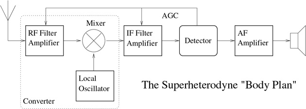

图 1.1 Edwin Armstrong 少校于 1918 年发明的超外差方案，至今仍是无线电接收机的主流“构型”。Figure 1.1 The superheterodyne plan, invented by Major Edwin Armstrong in 1918, is still the dominant “body plan” for radio receivers.

这一方案所确定的每个模块，又可以进一步分解为振荡器、混频器、滤波器和放大器等其他模块，如此不断分解，直至单个电子元件。此外，每个模块都可以用多种可能的方式实例化：射频部分可以只是一个滤波器，也可以是精细设计的滤波器与放大器组合。事实上，在模拟电视接收机中，混频器的一部分输出由视频链路按 AM 处理，另一部分则按 FM 处理以产生音频。而某些部分，例如变频器，还可以递归细化，仿佛 Hox 基因簇的某些部分被复制了一样，从而得到多次变频接收机。The modules identified in this plan each decompose into yet other modules, such as oscillators, mixers, filters, and amplifiers, and so on down to the individual electronic components. Additionally, each module can be instantiated in many possible ways: the RF section may be just a filter, or it may be an elaborate filter and amplifier combination. Indeed, in an analog television receiver part of the output of the mixer is processed as AM by the video chain and another part is processed as FM to produce the audio. And some sections, such as the converter, may be recursively elaborated (as if parts of the Hox complex were duplicated!) to obtain multiple-conversion receivers.

在生物系统中，这种区室结构也得到更高组织层级的支持。有些组织专门化为区室的边界，还有一些管道将各区室互连。器官以这类组织为边界，由这类管道互连；整个结构则被封装起来，容纳在体腔中。体腔是高等生物中内衬专门化组织的空腔。In biological systems this structure of compartments is also supported at higher levels of organization. There are tissues that are specialized to become boundaries of compartments, and tubes that interconnect them. Organs are bounded by such tissues and interconnected by such tubes, and the entire structure is packaged to fit into coeloms, which are cavities lined with specialized tissues in higher organisms.

类似技术也可用于软件。构型不过是一个将部分指定的组件组合起来的包装器。这是一种组合子：一种把子部件组合成更大部件的东西。我们可以创建组合子语言，在这种语言中，组件与组合体都具有相同的接口规范。使用组合子语言，可以从少量可混搭的组件构建任意大的组合体。自相似的结构使组合变得容易。在第 2 章中，我们将开始构建基于组合子的软件，而这一主题将贯穿本书其余所有章节。Similar techniques can be used in software. A body plan is just a wrapper that combines partially specified components. This is a kind of *combinator*: a thing that combines subparts together into a larger part. It is possible to create *combinator* *languages*, in which the components and the composite all have the same interface specification. In a combinator language, it is possible to build arbitrarily large composites from small numbers of mix-and-match components. The self-similar structures make combination easy. In chapter 2 we will begin to build combinator-based software, and this theme will run through all of the rest of the book.

利用领域专用语言，也能做到类似的事情。通过对领域进行抽象，我们可以在不同领域中使用同一份与领域无关的代码。例如，无论具体领域是什么，只要涉及数值，数值积分器就能派上用场。另一个例子是第 4 章的模式匹配，它可以应用于各种各样的领域。Something similar can be done with domain-specific languages. By making an abstraction of the domain, we can use the same domain-independent code in different domains. For example, numerical integrators are useful in any domain that has numerical aspects, regardless of the domain. Another example is pattern matching in chapter 4, which can be applied to a wide variety of domains.

生物机制具有通用性，因为原则上，每个组件都能充当任何其他组件。模拟电子元件不具有这种意义上的通用性。它们不会根据局部信号自行适应周围环境。但确实存在通用的电气构件，例如带有模拟接口的可编程计算机！<sup>12</sup> 对于低频应用，可以用这类构件构建模拟系统。如果每个构件都具有成为系统中任意构件所需的全部代码，但通过与邻近构件交互而实现专门化，并且封装中还有额外的、尚未专门化的“干细胞”，那么，我们就可以设想构建能够自行重配置、自行修复的模拟系统。但目前，我们仍然逐一设计和构建这些部件。Biological mechanisms are universal in that each component can, in principle, act as any other component. Analog electronics components are not universal in that sense. They do not adapt themselves to their surroundings based on local signaling. But there are universal electrical building blocks (a programmable computer with analog interfaces, for example!).<sup>12</sup> For low-frequency applications one can build analog systems from such blocks. If each block had all of the code required to be any block in the system, but was specialized by interactions with its neighbors, and if there were extra unspecialized “stem cells” in the package, then we could imagine building self-reconfiguring and self-repairing analog systems. But for now we still design and build these parts individually.

在编程中，我们确实有通用元素这一概念：求值器。求值器接受对某项待执行计算的描述，以及该计算的输入。它产生的输出，与将这些输入交给一个专门实现所需计算的定制组件所产生的输出相同。在计算领域，我们有机会采用胚胎发育这种极其灵活的策略。第 5 章将详细阐述求值器技术的使用。In programming we do have the idea of a universal element: the *evaluator*. An evaluator takes a description of some computation to be performed and inputs to that computation. It produces the outputs that would arise if we passed the inputs to a bespoke component that implemented the desired computation. In computation we have a chance to pursue the powerfully flexible strategy of embryonic development. We will elaborate on the use of evaluator technology in chapter 5.

## 1.3 冗余与简并1.3 Redundancy and degeneracy

生物系统演化出了很强的稳健性。生物系统的一个特征是具有冗余。肝脏和肾脏等器官具有高度冗余：它们的能力远远超出完成工作所必需的程度，因此，一个人即使少了一个肾或一部分肝脏，也不会表现出明显的功能障碍。生物系统也具有高度简并：满足某个给定需求，通常有多种方式。<sup>13</sup> 例如，如果一根手指受伤，可以通过调整其他手指的姿势来拿起物体。我们可以从各种各样的来源获得生命所需的能量：我们能够代谢碳水化合物、脂肪和蛋白质，尽管消化这些物质以及从各类物质中提取能量的机制各不相同。Biological systems have evolved a great deal of robustness. One of the characteristics of biological systems is that they are redundant. Organs such as the liver and kidney are highly *redundant*: there is vastly more capacity than is necessary to do the job, so a person missing a kidney or part of a liver suffers no obvious incapacity. Biological systems are also highly *degenerate*: there are usually many ways to satisfy a given requirement.<sup>13</sup> For example, if a finger is damaged, there are ways that the other fingers may be configured to pick up an object. We can obtain the necessary energy for life from a great variety of sources: we can metabolize carbohydrates, fats, and proteins, even though the mechanisms for digestion and for extraction of energy from each of these sources is quite distinct.

遗传密码本身就具有简并性，因为从密码子，即由三个核苷酸组成的序列，到氨基酸的映射不是一一对应的：64 种可能的密码子仅用于指定约 20 种可能的氨基酸 [86, 54]。因此，许多点突变，即单个核苷酸的改变，并不会改变编码区所指定的蛋白质。而且，用一种相似的氨基酸替换另一种氨基酸，往往也不会损害蛋白质的生物活性。这些简并使变异得以积累，而不产生明显的表型后果。此外，如果一个基因发生复制——这并不少见——各个副本就可以不显露效应地逐渐分化，在不影响当前生存能力的情况下，产生未来可能变得有价值的变体。另外，各个副本还可以置于不同的转录控制之下。The genetic code is itself degenerate, in that the map from codons (triples of nucleotides) to amino acids is not one-to-one: there are 64 possible codons to specify only about 20 possible amino acids [86, 54]. As a consequence, many point mutations (changes of a single nucleotide) do not change the protein specified by a coding region. Also, quite often the substitution of one amino acid with a similar one does not impair the biological activity of a protein. These degeneracies provide ways that variation can accumulate without obvious phenotypic consequences. Furthermore, if a gene is duplicated (not an uncommon occurrence), the copies may diverge silently, allowing the development of variants that may become valuable in the future, without interfering with current viability. In addition, the copies can be placed under different transcriptional controls.

简并是演化的产物，而它无疑也使演化成为可能。简并本身很可能也是选择的对象，因为只有具有显著简并程度的生物，才有足够的适应能力，在环境变化时生存下来。<sup>14</sup> 例如，假设某种生物，或某个工程系统，具有简并性，能够通过几种迥然不同且相互独立的机制实现某项基本功能。如果环境或需求发生变化，使其中一种实现基本功能的方式无法继续奏效，该生物仍能继续生存和繁殖，该系统也仍能继续满足其规范。但此时，那个已无法工作的子系统就有了发生突变或接受修复的空间，而不会影响整个系统的生存能力或当前运行。Degeneracy is a product of evolution, and it certainly enables evolution. Probably degeneracy is itself selected for, because only creatures that have significant amounts of degeneracy are sufficiently adaptable to allow survival as the environment changes.<sup>14</sup> For example, suppose we have some creature (or engineered system) that is degenerate in that there are several very different independent mechanisms to achieve some essential function. If the environment changes (or the requirements change) so that one of the ways of achieving an essential function becomes untenable, the creature will continue to live and reproduce (the system will continue to satisfy its specifications). But the subsystem that has become inoperative is now open to mutation (or repair), without impinging on the viability (or current operation) of the system as a whole.

物理学的理论结构具有深刻的简并性。例如，经典力学问题可以通过多种方式处理：既有矢量力学的牛顿表述，也有变分力学的拉格朗日表述和哈密顿表述。如果矢量力学和变分力学的任一种形式都适用，它们就会产生等价的运动方程。在分析具有摩擦力等耗散力的系统时，矢量力学很有效；变分方法则不太适合这类系统。在处理具有刚性约束的系统时，拉格朗日力学远优于矢量力学；而哈密顿力学则提供了正则变换这一有力工具，帮助我们利用相空间的结构来理解系统。拉格朗日表述和哈密顿表述，都能让我们深刻洞察对称性与守恒量的作用。描述一个力学系统有三种相互重叠的方法，并且当它们都适用时会彼此一致；这一事实为我们处理任何问题都提供了多条途径 [121]。The theoretical structure of physics is deeply degenerate. For example, problems in classical mechanics can be approached in multiple ways. There is the Newtonian formulation of vectoral mechanics and the Lagrangian and Hamiltonian formulations of variational mechanics. If both vectoral mechanics and either form of variational mechanics are applicable, they produce equivalent equations of motion. For analysis of systems with dissipative forces like friction, vectoral mechanics is effective; variational methods are not well suited for that kind of system. Lagrangian mechanics is far better than vectoral mechanics for dealing with systems with rigid constraints, and Hamiltonian mechanics provides the power of canonical transformations to help understand systems using the structure of phase space. Both the Lagrangian and Hamiltonian formulations help us with deep insights into the role of symmetries and conserved quantities. The fact that there are three overlapping ways of describing a mechanical system, which agree when they are all applicable, gives us multiple avenues of attack on any problem [121].

在失效代价极其高昂的关键系统中，工程系统可能会引入一些冗余。但它们几乎从不有意引入生物系统中那种简并，除非简并是非最优设计的副作用。<sup>15</sup>Engineered systems may incorporate some redundancy, in critical systems where the cost of failure is extreme. But they almost never intentionally incorporate degeneracy of the kind found in biological systems, except as a side effect of designs that are not optimal.<sup>15</sup>

简并可以为我们的系统增添价值：与冗余一样，我们可以交叉核对简并计算的答案，以提高稳健性。但简并计算不仅仅是冗余，它们彼此还各不相同，这意味着其中一个计算中的错误不太可能影响其他计算。这一特点不仅有利于可靠性，也有利于安全性，因为一次成功的攻击必须攻破多个简并部件。Degeneracy can add value to our systems: as with redundancy, we can cross-check the answers of degenerate computations to improve robustness. But degenerate computations are not just redundant but *different* from one another, meaning that a bug in one is unlikely to affect the others. This is a positive characteristic not only for reliability but also for security, as a successful attack must compromise multiple degenerate parts.

当简并部件产生部分信息时，它们组合后的结果可能优于任何一个单独结果。有些导航系统利用这一思想，将多个位置估计结合起来，产生高度精确的结果。我们将在第 7 章探讨组合部分信息的思想。When degenerate parts generate partial information, the result of their combination can be better than any individual result. Some navigation systems use this idea to combine several positional estimates to generate a highly accurate result. We will explore the idea of combining partial information in chapter 7.

## 1.4 探索行为1.4 Exploratory behavior

探索行为是生物系统中实现稳健性的最强大机制之一。<sup>16</sup> 其思想是，通过生成并检验的机制产生所需结果（见图 1.2）。这种组织方式允许生成机制保持通用，并独立于负责接受或拒绝某个生成结果的检验机制而工作。One of the most powerful mechanisms of robustness in biological systems is exploratory behavior.<sup>16</sup> The idea is that the desired outcome is produced by a generate-and-test mechanism (see figure 1.2). This organization allows the generator mechanism to be general and to work independently of the testing mechanism that accepts or rejects a particular generated result.

上图：生成（Generate）→提出候选（Propose）→检验（Test）；不合适的候选被拒绝（Reject），返回生成环节。下图：生成（Generate）→候选项（Proposals）→筛选（Filter）。

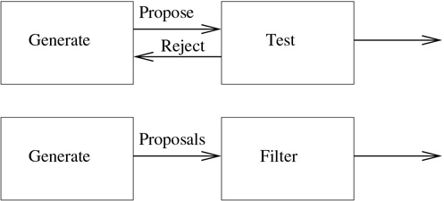

图 1.2 探索行为可以通过两种方式实现。一种方式是，生成器提出一个动作或结果，检验器可以明确拒绝它。此时，生成器必须提出一个替代方案。另一种方式是，生成器在没有反馈的情况下产生所有备选方案，再由过滤器选出一个或多个可以接受的方案。Figure 1.2 Exploratory behavior can be accomplished in two ways. In one way a generator proposes an action (or a result), which may be explicitly rejected by a tester. The generator then must propose an alternative. Another way is that the generator produces all of the alternatives, without feedback, and a filter selects one or more that are acceptable.

例如，支撑细胞形状的刚性骨架，其重要组成部分之一是一组微管。每根微管都由聚集在一起的蛋白质单元组成。在活细胞中，微管不断形成和解体；它们形成时朝各个方向生长。然而，只有遇到动粒或细胞膜中其他稳定结构的微管才能保持稳定，从而支撑由这些稳定结构的位置所决定的形状 [71]。因此，使某种形状长成并得以维持的机制，相对独立于规定该形状的机制。这种机制部分决定了复杂生物体中许多种细胞的形状，而且在动物中几乎普遍存在。For example, an important component of the rigid skeleton that supports the shape of a cell is an array of microtubules. Each microtubule is made up of protein units that aggregate to form it. Microtubules are continually created and destroyed in a living cell; they are created growing out in all directions. However, only microtubules that encounter a kinetochore or other stabilizer in the cell membrane are stable, thus supporting the shape determined by the positions of the stabilizers [71]. So the mechanism for growing and maintaining a shape is relatively independent of the mechanism for specifying the shape. This mechanism partly determines the shapes of many types of cells in a complex organism, and it is almost universal in animals.

探索行为出现在生物系统的各个细节层级。发育中胚胎的神经系统会产生远多于成年后所保留数量的神经元。能在其他神经元、感觉器官或肌肉中找到适当靶标的神经元会存活下来，找不到靶标的则会自行死亡。手的形成，是先产生一个垫状结构，再通过细胞凋亡，即程序性细胞死亡，去除手指之间的物质 [131]。我们的骨骼不断受到成骨细胞和破骨细胞的重塑，前者构建骨，后者分解骨。骨骼的形状和大小由其环境施加的约束决定：也就是它们必须与之相联的部分，例如肌肉、韧带、肌腱和其他骨骼。Exploratory behavior appears at all levels of detail in biological systems. The nervous system of a growing embryo produces a vastly larger number of neurons than will persist in the adult. Those neurons that find appropriate targets in other neurons, sensory organs, or muscles will survive, and those that find no targets kill themselves. The hand is fashioned by production of a pad and deletion, by apoptosis (programmed cell death), of the material between the fingers [131]. Our bones are continually being remodeled by osteoblasts (which build bone) and osteoclasts (which destroy bone). The shape and size of the bones is determined by constraints determined by their environment: the parts that they must be associated with, such as muscles, ligaments, tendons, and other bones.

由于生成器不必知道检验器如何接受或拒绝它的提案，而检验器也不必知道生成器如何提出提案，这两个部分就可以独立发展。这使适应和演化更有效率，因为两个子系统中的一个发生突变时，不必伴随另一个子系统的配套突变。不过，这种隔离可能代价高昂，因为生成失败提案并将其拒绝，会浪费许多精力。<sup>17</sup>Because the generator need not know about how the tester accepts or rejects its proposals, and the tester need not know how the generator makes its proposals, the two parts can be independently developed. This makes adaptation and evolution more efficient, because a mutation to one or the other of these two subsystems need not be accompanied by a complementary mutation to the other. However, this isolation can be expensive because of the wasted effort of generation and rejection of failed proposals.<sup>17</sup>

事实上，生成并检验是整个演化过程的一个比喻。生物变异的机制是随机突变，即遗传指令的修改。由于系统中的简并，大多数突变是中性的，不直接影响适合度。自然选择就是检验阶段。它不依赖于变异的方法，而变异的方法也不会预见选择的效果。Indeed, generate and test is a metaphor for all of evolution. The mechanisms of biological variation are random mutations: modifications of the genetic instructions. Most mutations are neutral in that they do not directly affect fitness because of degeneracy in the systems. Natural selection is the test phase. It does not depend on the method of variation, and the method of variation does not anticipate the effect of selection.

还有更惊人的现象：即使在亲缘关系很近的生物中，有些组成部分在成年个体中几乎完全相同，却是在胚胎中由全然不同的机制构建出来的。<sup>18</sup> 对于亲缘关系较远的生物，用不同机制构建共同结构，可以归因于“趋同演化”；但对于近亲，这更可能表明细节层级彼此分离：结果的规定方式，在一定程度上独立于其实现方式。There are even more striking phenomena: even in closely related creatures some components that end up almost identical in the adult are constructed by entirely different mechanisms in the embryo.<sup>18</sup> For distant relationships, divergent mechanisms for constructing common structures may be attributed to “convergent evolution,” but for close relatives it is more likely evidence for separation of levels of detail, in which the result is specified in a way that is somewhat independent of the way it is accomplished.

工程系统也可能呈现类似的结构。我们努力将规范与实现分离：满足一项规范往往有多种方式，不同设计可以选择不同实现。对数据集排序的最佳方法，取决于数据集的预期规模，以及元素比较的计算成本。多项式的恰当表示方式，取决于它是稀疏的还是稠密的。但即使这些选择是动态作出的——这种系统并不常见——它们仍是确定性的：我们很少看到有系统同时尝试多种方式解决一个问题，并采用最先收敛的那一种结果——那些处理器核心到底是干什么用的呢？甚至顺序尝试多种方法的系统也很少见：一种方法失败，就试另一种。第 4 章将考察如何在模式匹配中利用回溯实现生成并检验机制。第 5 章将学习如何在语言中内置自动回溯。第 7 章则将学习如何构建依赖关系引导的回溯机制，尽可能从失败中提取信息。Engineered systems may show similar structure. We try to separate specification from implementation: there are often multiple ways to satisfy a specification, and designs may choose different implementations. The best method to use to sort a data set depends on the expected size of the data set, as well as the computational cost of comparing elements. The appropriate representation of a polynomial depends on whether it is sparse or dense. But if choices like these are made dynamically (an unusual system) they are deterministic: we do not see many systems that simultaneously try several ways to solve a problem and use the one that converges first (what are all those cores for, anyway?). It is even rare to find systems that try multiple methods sequentially: if one method fails try another. We will examine use of backtracking to implement generate-and-test mechanisms in pattern matching in chapter 4. We will learn how to build automatic backtracking into languages in chapter 5. And we will learn how to build a dependency-directed backtracking mechanism that extracts as much information as possible from failures in chapter 7.

## 1.5 灵活性的成本1.5 The cost of flexibility

> Lisp 程序员知道一切事物的价值，却不知道任何事物的成本。Lisp programmers know the value of everything but the cost of nothing.

> Alan Perlis 仿 Oscar Wilde 的话Alan Perlis paraphrasing Oscar Wilde

我们已经指出，使用泛型、分层、冗余、简并和探索行为，可以增强系统的通用性与可演化性。孤立地看，每一种方法都代价高昂。一个能够处理广泛输入的机制，要得到同样的结果，必须比专门针对某种输入的机制做更多工作。冗余机制比与之等效的非冗余机制具有更多部件。简并机制看起来更加奢侈。通过生成并检验进行探索的机制，则很容易陷入不可行的指数级搜索。然而，这些却是可演化系统的关键要素。也许，要构建真正稳健的系统，我们就必须愿意为看起来相当复杂而昂贵的基础设施付出代价。We have noted that generality and evolvability are enhanced in systems that use generics, layers, redundancy, degeneracy, and exploratory behavior. Each of these is expensive, when looked at in isolation. A mechanism that works over a wide range of inputs must do more to get the same result than a mechanism specialized to a particular input. A redundant mechanism has more parts than an equivalent nonredundant mechanism. A degenerate mechanism appears even more extravagant. And a mechanism that explores by generate-and-test methods can easily get into an infeasible exponential search. Yet these are key ingredients in evolvable systems. Perhaps to make truly robust systems we must be willing to pay for what appears to be a rather elaborate and expensive infrastructure.

部分问题在于，我们思考成本的角度不对。时间和空间的使用固然重要，但对于这些成本来自何处，我们的直觉却并不可靠。每位工程师都知道，评估系统的实际性能，需要进行大量细致的测量，而测量结果往往表明，成本出现在出人意料的地方。随着复杂性增加，这件事只会更加困难。然而，我们仍执意在程序的各个层次上进行过早优化，却并不知道它的真正价值。Part of the problem is that we are thinking about cost in the wrong terms. Use of time and space matters, but our intuition about where those costs come from is poor. Every engineer knows that evaluating the real performance of a system involves extensive and careful measurements that often show that the cost is in surprising places. As complexity increases, this will only get harder. But we persist in doing premature optimization at all levels of our programs without knowing its real value.

假设我们把系统中必须快速的部分，与必须聪明的部分分离。按照这一方针，通用性和可演化性的成本，就可以局限在必须聪明的部分。在计算系统中，这是不常见的视角，但在我们的生活经验中，它却无处不在。例如，尝试学习一种新技能，比如演奏乐器时，最初阶段需要有意识的活动，将预期效果与产生该效果所需的身体动作联系起来。但随着技能得到掌握，大部分工作无需有意识地关注就能完成。要快速演奏，这一点至关重要，因为有意识的活动太慢了。Suppose we separate the parts of a system that have to be fast from the parts that have to be smart. Under this policy, the cost of generality and evolvability can be confined to the parts that have to be smart. This is an unusual perspective in computing systems, yet it is ubiquitous in our life experience. When we try to learn a new skill, for example to play a musical instrument, the initial stages involve conscious activity to connect the intended effect to the physical movements required to produce it. But as the skill is mastered, most of the work is done without conscious attention. This is essential to being able to play at speed, because the conscious activity is too slow.

在硬件与软件的区分中，也能找到类似的论证。硬件以接口固定为代价，换取效率。然后，人们可以在该接口之上用软件构建软件，实际上就是创建一台虚拟机。众所周知，额外的抽象层会带来成本，但它所获得的通用性，完全值得这种权衡。（否则，我们就仍在用汇编语言编程！）这里的要点是，这种分层结构提供了一种兼顾效率与灵活性的方法。我们认为，要求整个系统都以尽可能高效的方式实现，会适得其反，阻碍系统为适应未来需求而保有灵活性。一个系统的真正成本，是程序员在设计、理解、维护、修改和调试它时所花费的时间。因此，增强适应性的价值可能更加巨大。一个易于调整和维护的系统，能够消除最大的成本之一：为了让新程序员知道应当从哪里着手修改代码，必须把现有系统的工作方式及其所有繁杂细节教给他们。事实上，无论从灾难造成的成本，还是从重新设计和重建所耗时间导致的机会损失来看，我们脆弱的基础设施所带来的成本，很可能都远远超过灵活设计的成本。而如果能够让系统自行适应新情境，取代为满足新需求而重新编程所需时间中的很大一部分，收益还会更大。A similar argument is found in the distinction between hardware and software. Hardware is designed for efficiency, at the cost of having a fixed interface. One can then build software on top of that interface—in effect creating a virtual machine—using software. That extra layer of abstraction incurs a well-known cost, but the tradeoff is well worth the generality that is gained. (Otherwise we'd still be programming in assembly language!) The point here is that this layered structure provides a way to have both efficiency and flexibility. We believe that requiring an entire system to be implemented in the most efficient possible way is counterproductive, preventing the flexibility for adapting to future needs. The real cost of a system is the time spent by programmers—in designing, understanding, maintaining, modifying, and debugging the system. So the value of enhanced adaptability may be even more extreme. A system that is easily adapted and maintained eliminates one of the largest costs: teaching new programmers how the existing system works, in all its gory detail, so that they know where to reach in and modify the code. Indeed, the cost of our brittle infrastructure probably greatly exceeds the cost of flexible design, both in the cost of disasters and in the lost opportunity costs due to the time of redesign and rebuilding. And if a significant fraction of the time spent reprogramming a system for a new requirement is replaced by having that system adapt itself to the new situation, that can be an even bigger win.

#### 正确性带来的问题The problem with correctness

> 在乐观者看来，杯子半满。在悲观者看来，杯子半空。在工程师看来，杯子的容量是所需的两倍。To the optimist, the glass is half full. To the pessimist, the glass is half empty. To the engineer, the glass is twice as big as it needs to be.

> 作者不详author unknown

不过，以某种方式构建系统，使其适用范围超出我们在设计时考虑过的情境集合，可能还会带来更大的成本。因为我们打算在系统并非为之设计的上下文中使用它，所以我们无法确信它们能够正确工作！But there may be an even bigger cost to building systems in a way that gives them a range of applicability greater than the set of situations that we have considered at design time. Because we intend to be willing to apply our systems in contexts for which they were not designed, we cannot be sure that they work correctly!

在计算机科学中，我们受到的教导是，软件的“正确性”至高无上；要实现正确性，就应为组件及其构成的系统建立形式化规范，并给出证明，表明组件的规范及其组合模式能够满足组件组合体的规范。<sup>19</sup> 我们断言，这种规训会使系统更加脆弱。事实上，要构建真正稳健的系统，我们就必须放弃如此严格的规训。In computer science we are taught that the “correctness” of software is paramount, and that correctness is to be achieved by establishing formal specification of components and systems of components and by providing proofs that the specifications of a combination of components are met by the specifications of the components and the pattern by which they are combined.<sup>19</sup> We assert that this discipline makes systems more brittle. In fact, to make truly robust systems we must discard such a tight discipline.

要求证明的问题在于，证明通用机制的一般性质，通常比证明在受限情境中使用的专用机制的特殊性质更困难。这就促使我们把部件及其组合设计得尽可能专用，以简化证明。但高度专用部件的组合是脆弱的——它没有任何容纳变化的余地！<sup>20</sup>The problem with requiring proofs is that it is usually harder to prove general properties of general mechanisms than it is to prove special properties of special mechanisms used in constrained circumstances. This encourages us to make our parts and combinations as special as possible so we can simplify our proofs. But the combination of tightly specialized parts is brittle—there is no room for variation!<sup>20</sup>

我们并不反对证明。能得到证明时，它们当然很好。事实上，对于垃圾收集器或核糖体等关键系统组件而言，证明至关重要。<sup>21</sup> 然而，即使对于自动驾驶仪等安全关键系统，将其适用范围限制在能够证明系统符合规范、正确工作的情境内，也可能反而导致不必要的失效。事实上，我们希望：即使飞机以设计者未曾预料到的方式受损，自动驾驶仪也能尽其所能，尝试让飞机安全飞行！We are not arguing against proofs. They are wonderful when available. Indeed, they are essential for critical system components, such as garbage collectors (or ribosomes).<sup>21</sup> However, even for safety-critical systems, such as autopilots, the restriction of applicability to situations for which the system is provably correct as specified may actually contribute to unnecessary failure. Indeed, we want an autopilot to make a good-faith attempt to safely fly an airplane that is damaged in a way not anticipated by the designer!

我们反对的是强求证明的规训：要求一切事物在被允许用于某种情境之前，必须先证明其适用于该情境，会过分抑制那些能够增强设计稳健性的技术的使用。尤其受到抑制的，是允许在严格控制下将某种方法用于其已获证明的适用域之外的技术，以及为未来扩展提供支持、却不限制扩展方式的技术。We are arguing against the discipline of *requiring* proofs: the requirement that everything must be proved to be applicable in a situation before it is allowed to be used in that situation excessively inhibits the use of techniques that could enhance the robustness of designs. This is especially true of techniques that allow a method to be used, on a tight leash, outside of its proven domain, and techniques that provide for future expansion without putting limits on the ways things can be extended.

不幸的是，我们提倡的许多技术，会使证明问题变得困难得多，甚至在实践中不可能完成。另一方面，有时处理一个问题的最佳方法，就是将其推广，直到证明变得简单。Unfortunately, many of the techniques we advocate make the problem of proof much more difficult, if not practically impossible. On the other hand, sometimes the best way to attack a problem is to generalize it until the proof becomes simple.

1 Alan Turing [124] 发现通用机器的存在，以及下述事实的确立，堪称二十世纪最伟大的智力成就之一：图灵机可计算的函数集合，既等价于 Alonzo Church 的 *λ* 演算 [17, 18, 16] 可表示的函数集合，也等价于 Kurt Gödel [45] 和 Jacques Herbrand [55] 的一般递归函数集合。1 The discovery of the existence of universal machines by Alan Turing [124], and the fact that the set of functions that can be computed by Turing machines is equivalent to both the set of functions representable in Alonzo Church's *λ* calculus [17, 18, 16] and the general recursive functions of Kurt Gödel [45] and Jacques Herbrand [55], ranks among the greatest intellectual achievements of the twentieth century.

2 当然，也有一些出色的例外。例如，Emacs [113] 是一个可扩展编辑器，它一直在平稳演化，以适应计算环境和用户期望的变化。计算机界刚刚开始探索“工程化框架”，例如 Microsoft 的 .net 和 Sun 的 Java。它们旨在成为支持可演化系统的基础设施。2 Of course, there are some wonderful exceptions. For example, Emacs [113] is an extensible editor that has evolved gracefully to adapt to changes in the computing environment and to changes in its users’ expectations. The computing world is just beginning to explore “engineered frameworks,” for example, Microsoft's .net and Sun's Java. These are intended to be infrastructures to support evolvable systems.

3 parti（读作 parTEE）是一件建筑作品的核心思想：它是“作为整体来构思的［建筑］构图，细节则留待以后填入。”[62]3 A *parti* (pronounced parTEE) is the central idea of an architectural work: it is “the [architectural] composition being conceived as a whole, with the detail being filled in later.” [62]

4 Java 的确支持接口。接口可以视为一种 parti，因为它们是程序的抽象表示。但 parti 同时组合抽象组件和具体组件，而 Java 接口则完全是抽象的。更不用说，许多人还认为过度使用接口是一种“代码异味”。4 Java *does* support interfaces, which could be considered a kind of *parti*, in that they are an abstract representation of the program. But a *parti* combines both abstract and concrete components, while a Java interface is wholly abstract. Not to mention that over-use of interfaces is considered a “code smell” by many programmers.

5 《面向设计工程师的 TTL 数据手册》[123] 是数字系统组件规格说明取得成功的经典范例。TTL 为小规模和中规模集成电路组件规定了若干内部一致的“系列”。这些系列在速度、功耗等特性上有所不同，但功能相同。规格说明描述了各系列的静态和动态特性、各系列提供的功能，以及组件的物理封装。各系列不仅内部一致，彼此之间也一致：每种功能在每个系列中都能找到，封装相同，描述所用的命名体系也一致。因此，设计者可以先设计复合功能，随后再选择用于实现的系列。每一位优秀的工程师（还有生物学家！）都应熟悉 TTL 带来的启示。5 *The* *TTL* *Data* *Book* *for* *Design* *Engineers* [123] is a classic example of a successful set of specifications for digital-system components. TTL specifies several internally consistent “families” of small-scale and medium-scale integrated-circuit components. The families differ in such characteristics as speed and power dissipation, but not in function. The specification describes the static and dynamic characteristics of each family, the functions available in each family, and the physical packaging for the components. The families are cross-consistent as well as internally consistent in that each function is available in each family, with the same packaging and a consistent nomenclature for description. Thus a designer may design a compound function and later choose the family for implementation. Every good engineer (and biologist!) should be familiar with the lessons of TTL.

6 Jacob Beal 在其理学硕士论文 [9] 中演示了这种自配置行为的一个初步版本。6 An elementary version of this self-configuring behavior has been demonstrated by Jacob Beal in his S.M. thesis [9].

7 Kirschner 和 Gerhart 对此进行了考察 [70]。7 Kirschner and Gerhart examine this [70].

8 这只是对一个涉及形态发生素梯度的复杂过程所作的十分粗略的描述。我们不打算在这里进一步精确说明，因为这里讨论的不是生物学，而是生物学如何启发工程设计。8 This is a very vague description of a complex process involving gradients of morphogens. We do not intend to get more precise here, as this is not about biology, but rather about how biology can inform engineering.

9 我们曾在“无定形计算”项目 [2] 中研究这种发育所涉及的一些编程问题。9 We have investigated some of the programming issues involved in this kind of development in our Amorphous Computing project [2].

10 自动如魔法（Automagically）：“自动完成，但由于某种原因（通常是因为太复杂、太丑陋，或者甚至太琐碎），说话者不想解释其方式。”引自《黑客词典》[117, 101]。10 Automagically: “Automatically, but in a way which, for some reason (typically because it is too complicated, or too ugly, or perhaps even too trivial), the speaker doesn't feel like explaining.” From *The* *Hacker's* *Dictionary* [117, 101]

11 这类机制中一个得到充分研究的例子是小鼠颌下腺的形成。例如，可参阅 [11] 中的论述，或 [7] 第 3.4.3 节的概述。11 One well-studied example of this kind of mechanism is the formation of the submandibular gland of the mouse. See, for example, the treatment in [11] or the summary in [7] section 3.4.3.

12 Piotr Mitros 提出了一种新颖的设计策略，利用可能具有通用性的构件来构造模拟电路。参见 [92]。12 Piotr Mitros has developed a novel design strategy for building analog circuits from potentially universal building blocks. See [92].

13 尽管在极端情形下区别很清楚，但生物学家对冗余和简并所作的区分，在边界处却很模糊。更多信息见 [32]。13 Although clear in extreme cases, the distinction biologists make between redundancy and degeneracy is fuzzy at the boundary. For more information see [32].

14 一些计算机科学家利用模拟研究了可演化能力本身的演化 [3]。14 Some computer scientists have used simulation to investigate the evolution of evolvability [3].

15 的确，人们经常听到反对在工程系统中引入简并的观点。例如，计算机语言 Python 的设计哲学宣称：“应当有一种——而且最好只有一种——显而易见的做法。”[95]15 Indeed, one often hears arguments against building degeneracy into an engineered system. For example, in the philosophy of the computer language Python it is claimed: “There should be one—and preferably only one—obvious way to do it.” [95]

16 Kirschner 和 Gerhart 的著作 [70] 对这一论点作了很好的探讨。16 This thesis is nicely explored in the book of Kirschner and Gerhart [70].

17 如果已有足够的信息，能够迅速减少必须测试的候选者数量，就可以大幅降低这项开销。我们将在第 7 章考察这种优化的一个非常漂亮的例子。17 This expense can be greatly reduced if there is sufficient information present to quickly reduce the number of candidates that must be tested. We will examine a very nice example of this optimization in chapter 7.

18 小鸡的角膜与小鼠的角膜几乎相同，但二者的形态发生过程却毫不相似：连各个形态发生事件的顺序都不相同。Bard 在 [7] 第 3.6.1 节指出，不同物种以不同方式形成相同结构的现象十分常见。他列举了许多例子。其中一个惊人的例子是，蛙类 Gastrotheca riobambae（参见 del Pino 和 Elinson [28]）从胚盘发育成通常的蛙形，而其他蛙类则从近似球形的胚胎发育而来。18 The cornea of a chick and the cornea of a mouse are almost identical, but the morphogenesis of these two are not at all similar: the order of the morphogenetic events is not even the same. Bard [7] section 3.6.1 reports that having divergent methods of forming the same structures in different species is common. He quotes a number of examples. One spectacular case is that the frog *Gastrotheca riobambae* (see del Pino and Elinson [28]) develops ordinary frog morphology from an embryonic disk, whereas other frogs develop from an approximately spherical embryo.

19 为复杂系统制定规格说明很困难，甚至可能根本做不到。如第 7 页所述，规定一个下棋程序必须遵守国际象棋规则很容易，但要如何规定它必须下得好呢？而且，与规则不会改变的国际象棋不同，大多数系统的规格说明都会随着使用条件的变化而动态变化。面对迅速变化的税法，我们该如何规定会计系统的规格呢？19 It is hard, and perhaps impossible, to specify a complex system. As noted on page 7, it is easy to specify that a chess player must play legal chess, but how would we specify that it plays well? And unlike chess, whose rules do not change, the specifications of most systems are dynamically changing as the conditions of their usage change. How do we specify an accounting system in the light of rapidly changing tax codes?

20 事实上，Postel 法则（见第 3 页）与使用规格精确而狭窄的部件来构建系统的实践直接对立：Postel 法则要求，每个部件的适用范围都应比任何特定应用绝对必需的范围更广。20 Indeed, Postel's Law (on page 3) is directly in opposition to the practice of building systems from precisely and narrowly specified parts: Postel's law instructs us to make each part more generally applicable than absolutely necessary for any particular application.

21 底层存储管理子系统（如垃圾收集器）中的细微错误极难调试，尤其是在具有并发进程的系统中！但如果让这些子系统保持简单而小巧，就能以可承受的工作量制定其规格，甚至证明它们“正确”。21 A subtle bug in a primitive storage management subsystem, like a garbage collector, is extremely difficult to debug—especially in a system with concurrent processes! But if we keep such subsystems simple and small they can be specified and even proved “correct” with a tractable amount of work.

# 2 领域专用语言2 Domain-Specific Languages

为编程项目赋予灵活性的一项强大策略，是创建一种领域专用语言，捕捉待开发程序所涉及主题的概念结构。领域专用语言是一种抽象，其中的名词和动词直接对应问题领域。这样的语言允许应用程序直接用该领域的概念来编写。领域专用语言就其本性而言，实现的是一个相当完整的领域模型，超出了某个特定应用的需要。<sup>1</sup> 这看似是当前具体问题并不必需的额外工作，但其工作量往往比编写一个单体程序更少，而产生的程序也更容易修改、调试和扩展。One powerful strategy for building flexibility into a programming project is to create a *domain-specific language* that captures the conceptual structure of the subject matter of the programs to be developed. A domain-specific language is an abstraction in which the nouns and verbs of the language are directly related to the problem domain. Such a language allows an application program to be written directly in terms of the domain. By its nature, a domain-specific language implements a fairly complete model of the domain, in excess of what is needed for a particular application.<sup>1</sup> Although this may seem like extra work that is not essential to the particular problem at hand, it is often less work than writing a monolithic program, and the resulting program is much easier to modify, debug, and extend.

因此，构建领域专用语言层，所支持的不只是某个特定程序的开发。它为构建共享同一论域的各种相关程序提供了通用框架，简化了扩展该领域中现有应用的过程，还提供了使相关应用得以协作的基础。So a domain-specific language layer is built to support more than just the development of a particular program. It provides a general framework for the construction of a variety of related programs that share the domain of discourse. It simplifies the process of extending an existing application in that domain. And it provides a substrate that allows related applications to cooperate.

本章首先介绍组合子系统，这是构建领域专用语言层的一项强大的组织策略。我们将展示如何把用于字符串匹配的、丑陋混乱的正则表达式，重新组织成一种嵌入 Scheme 的、基于组合子的优雅领域专用语言，以此证明这项策略的有效性。但有时，我们手中的组件不容易融入一个整洁的系统——有时我们需要一个适配器系统。我们用一种为过程制作单位换算包装器的领域专用语言来说明这一点：它使原本假定使用某一单位制编写的过程，可以在另一单位制下使用。最后，我们考察棋盘游戏这个广泛的领域，看看如何通过为游戏规则构建解释器来抽象领域细节。In this chapter we first introduce systems of combinators, a powerful organizational strategy for the erection of domain-specific language layers. We will demonstrate the effectiveness of this strategy by showing how to reformulate the ugly mess of regular expressions for string matching into a pretty combinator-based domain-specific language embedded in Scheme. But sometimes we have components that do not easily fit into a clean system— sometimes we need a system of adapters. We illustrate this with a domain-specific language for making unit-conversion wrappers for procedures, allowing procedures written assuming one unit system to be used with a different unit system. Finally, we consider the broad domain of board games. We see how it is possible to abstract the details of the domain by building an interpreter for the rules of the game.

## 2.1 组合子2.1 Combinators

生物系统的适应能力很大程度上来自使用非常通用的部件（细胞）：这些部件经过动态配置，因而能够随着环境的变化而调整。计算系统通常不采用这种策略，而是依赖由定制部件及其组合构成的层次结构。近年来，由规格明确的较高层次部件组成的大型程序库，提升了这类活动的抽象层次。但除了作为“模式”，组合手段本身很少被抽象或共享。<sup>2</sup>Biological systems achieve much of their adaptability through the use of very general parts (cells) that are dynamically configured and consequently able to adjust as their environment changes. Computational systems usually do not use this strategy, instead relying on a hierarchy of custom parts and combinations. In recent years, large libraries of well-specified higher-level parts have raised the abstraction level of this activity. But the means of combination are rarely abstracted or shared, other than as “patterns.”<sup>2</sup>

在某些情形下，我们可以用促进共享组合机制的简单策略来改进这种做法。如果所构建的系统由某个可以“混搭”的组件族的成员组成，而组件组合后仍形成该族的新成员，那么需求发生扰动时，有时只需重新排列组件就能应对。In some situations we can improve on this practice by simple strategies that promote the use of shared combination mechanisms. If the systems we build are made up from members of a family of “mix-and-match” components that combine to make new members of the family, perturbations of the requirements can sometimes be addressed by rearrangement of components.

组合子系统包含一组基本部件，以及一组组合部件的手段，而且组合结果的接口规格与基本部件相同。这样就能在构建过程中避免部件之间发生意外的相互作用。TTL [123] 是一个类似组合子系统的经典例子：它是一个历史悠久的标准部件及其组合的库，用于构建复杂的数字系统。A *system* *of* *combinators* is a set of primitive parts and a set of means of combining parts such that the interface specifications of the combinations are the same as those of the primitives. This enables construction without accidental interactions between the parts. A classic example of a combinator-like system is TTL [123], which is a historic library of standard parts and combinations for building complex digital systems.

组合子系统为领域专用语言提供了一种设计策略。系统中的元素就是语言中的词，而组合子则用来将它们组合成短语。组合子系统的显著优点是易于构建、易于推理，但也存在局限，我们将在第 3.1.5 节讨论。只要适合该领域，它们就是极好的策略选择。Combinator systems provide a design strategy for domain-specific languages. The elements of the system are words in the language, and the combinators are used to combine them into phrases. Combinator systems have the significant advantage that they are easy to build and to reason about, but they have limitations, which we will discuss in section 3.1.5. When they fit the domain, they are an excellent strategic choice.

但是，怎样才能通过组合一个可混搭组件族中的元素来构建系统呢？我们必须确定一组基本组件和一组组合子，由组合子将组件组合成复合组件，而复合组件的接口必须与基本组件相同。这样的组合子集合在数学记法中有时是显式的，但更多时候是隐含的。But how do we arrange to build our systems by combining elements of a family of mix-and-match components? We must identify a set of primitive components and a set of *combinators* that combine components so as to make compound components with the same interface as the primitive components. Such sets of combinators are sometimes explicit, but more often implicit, in mathematical notation.

### 2.1.1 函数组合子2.1.1 Function combinators

数学中使用函数记法，本身就是一种遵循组合子规则的做法。函数有一个定义域，实参从中选取，还有一个由可能取值构成的值域（或陪域）。某些组合子能通过组合其他函数来产生新函数。例如，函数 *f* 和 *g* 的复合 *f* ○ *g* 是一个新函数，它接受 *g* 定义域中的实参，产生 *f* 陪域中的值。如果两个函数的定义域和陪域相同，而且其共同的陪域上定义了算术运算，那么就可以定义这两个函数的和（或积）：给定共同定义域中的一个实参，新函数的值就是原来两个函数在该实参处取值的和（或积）。允许过程作为一等对象的语言，提供了支持这种组合手段的机制，但真正重要的是拥有一个良好的部件族。The use of functional notation in mathematics is a combinator discipline. A function has a domain, from which its arguments are selected, and a range (or codomain) of its possible values. There are combinators that produce new functions as combinations of others. For example, the composition *f* *○* *g* of functions *f* and *g* is a new function that takes arguments in the domain of *g* and produces values in the codomain of *f*. If two functions have the same domain and codomain, and if arithmetic is defined on their common codomain, then we can define the sum (or product) of the functions as the function that when given an argument in their common domain, is the sum (or product) of the values of the two functions at that argument. Languages that allow first-class procedures provide a mechanism to support this means of combination, but what really matters is a good family of pieces.

围绕组合子组织系统有几个优点。构造出的部件可以任意混搭。任何组合都会得到合法程序，其行为清晰地仅取决于各部件的行为以及它们的组合方式。部件所处的上下文不会改变它的行为：始终可以把一个复合部件拿到新的上下文中使用，而不用担心它在那里的行为。因此，这样的程序易于编写、易于阅读，也易于验证。基于组合子构建的程序具有可扩展性，因为引入新部件或新组合子不会影响现有程序的行为。Organizing a system around combinators has several advantages. The parts that are made can be arbitrarily mixed and matched. Any combination yields a legal program, whose behavior transparently depends only on the behaviors of the parts and the ways that they are combined. The context in which a part appears does not change the behavior of the part: it is always acceptable to pick up a compound part to use it in a new context, without worry about its behavior in that context. Thus such programs are easy to write, easy to read, and easy to verify. A program built on combinators is extensible, because introduction of new parts or new combinators does not affect the behavior of existing programs.

可以把函数组合子看作接线图的实现，接线图规定了如何组合部件来构造函数。例如，函数复合表示由两个子盒组成的盒子，第一个子盒的输出馈入第二个子盒的输入，如图 2.1 所示。实现这个想法的程序很直接：We can think of function combinators as implementing wiring diagrams that specify how a function is built by combining its parts. For example, functional composition represents a box made of two subboxes so that the output of the first feeds the input of the second, as shown in figure 2.1. A program that implements this idea is straightforward:

```
(define (compose f g)

  (lambda args

    (f (apply g args))))
```

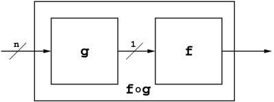

图 2.1 函数 *f* 和 *g* 的复合 *f* ◦ *g*，是由这张“接线图”定义的新函数。*f* ◦ *g* 的输入交给 *g*，然后 *g* 的输出传给 *f*，后者产生 *f* ◦ *g* 的输出。Figure 2.1 The composition *f* *◦* *g* of functions *f* and *g* is a new function that is defined by this “wiring diagram.” The input to *f* *◦* *g* is given to *g*. The output of *g* is then passed to *f* , and it produces the output of *f* *◦* *g*.

（如果想检查元数是否匹配，事情就会更有趣：过程 f 所表示的函数应当只接受一个实参，以匹配 g 的输出。如果 g 能返回多个值，而 f 必须接受这些实参，那就更有趣了。我们可能还想检查，传给复合函数的实参数量是否符合 g 的要求。不过，这些细节留待后面处理。）(It gets more exciting if we want to check that the arities match: that the function represented by procedure f takes only one argument, to match the output of g. It gets even more fun if g can return multiple values and f must take those arguments. We may also want to check that the arguments passed to the composition are the right number for g. But these are fine points that we will deal with later.)

我们可以用一个简单的例子来演示复合：We can demonstrate composition with a simple example:

```
((compose (lambda (x) (list ’foo x))

          (lambda (x) (list ’bar x)))

 ’z)

(foo (bar z))
```

有时，为组合子所返回的过程取个名字会更好。例如，可以将 compose 写成：It is sometimes nicer to name the procedure that is being returned by a combinator. For example, we could write compose as

```
(define (compose f g)

  (define (the-composition . args)

    (f (apply g args)))

  the-composition)
```

名字 the-composition 在 compose 定义的作用域之外并没有定义，所以用这种方式编写 compose 过程没有明显的优势。我们经常在程序中使用由 lambda 表达式定义的匿名过程，就像上面第一个版本的 compose 那样。因此，选择哪种写法主要是风格问题。<sup>3</sup>The name the-composition is not defined outside of the scope of the definition of compose, so there is no obvious advantage to this way of writing the compose procedure. We often use anonymous procedures defined by lambda expressions in our programs, as in the first version of compose above. So the choice of how to write the program is mostly a matter of style.<sup>3</sup>

```
(define ((iterate n) f)

  (if (= n 0)

      identity

      (compose f ((iterate (- n 1)) f))))



(define (identity x) x)
```

((iterate n) f) 的结果是一个与 f 同类型的新函数，凡是可以使用 f 的地方都可以使用它。因此，(iterate n) 本身也是一个函数组合子。现在可以用它来求对一个数反复平方的结果：The result of ((iterate n) f) is a new function, of the same type as f. It can be used wherever f can be used. So (iterate n) is itself a function combinator. Now we can use this to determine the result of repeatedly squaring a number:

```
(((iterate 3) square) 5)

390625
```

注意这个类比：函数复合类似于乘法，所以函数迭代就类似于乘方。Notice the analogy: function composition is like multiplication, so function iteration is like exponentiation.

有许多简单的组合子在编程中普遍有用。这里仅介绍几个，让大家感受一下可能性的广度。There are many simple combinators that are generally useful in programming. We will present just a few here to give a feeling for the range of possibilities.

我们可以让两个函数并行使用，再用指定的合并函数组合它们的结果（见图 2.2）。这种并行组合用以下过程实现：We can arrange to use two functions in parallel, then combine their results with a specified combiner function (see figure 2.2). This parallel combination is implemented with the procedure

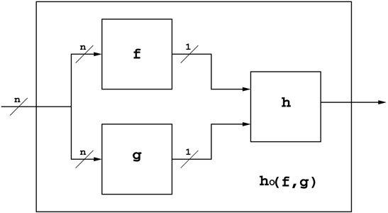

图 2.2 在 parallel-combine 中，函数 *f* 和 *g* 接受相同数量的实参。“并行组合”的输入同时传给这两个函数，再由接受两个实参的函数 *h* 组合它们的输出。Figure 2.2 In parallel-combine the functions *f* and *g* take the same number of arguments. The input to the “parallel combination” is passed to both of them. Their outputs are then combined by the function *h*, of two arguments.

```
(define (parallel-combine h f g)

  (define (the-combination . args)

    (h (apply f args) (apply g args)))

  the-combination)



((parallel-combine list

                   (lambda (x y z) (list ’foo x y z))

                   (lambda (u v w) (list ’bar u v w)))

 ’a ’b ’c)

((foo a b c) (bar a b c))
```

parallel-combine 组合子可以用于组织复杂的处理过程。例如，假设我们有一个蔬菜局部图像的来源。一个过程可以根据图像估计蔬菜的颜色，另一个过程可以描述其形状（叶、根、茎等）。还可以有第三个过程，将这些描述组合起来辨认蔬菜。使用 parallel-combine，便能将这些过程整洁地组合起来。The parallel-combine combinator can be useful in organizing a complex process. For example, suppose we have a source of images of pieces of vegetable. We may have one procedure that given the image can estimate the color of the vegetable, and another that can give a description of the shape (leaf, root, stalk, ...). We may have a third procedure that can combine these descriptions to identify the vegetable. These can be neatly composed with parallel-combine.

#### 元数Arity

编程中有整族的组合子可用，而我们通常并不会想到它们。其中许多出现在常见的数学语境中。例如，张量将线性代数扩展到了具有多个实参的线性算子。但这个想法还要更普遍：两个过程的“张量组合”不过是一个新过程，它接受一种汇集了原来两个过程所需实参的数据结构，将这些实参分配给两个过程，再产生一种汇集两个过程取值的数据结构。拆开数据结构、分别处理各部分、再将结果重新打包，这种需求在编程中无处不在。图 2.3 的接线图展示了 spread-combine。它是多重线性代数中张量积的推广。在数学的张量积中，*f* 和 *g* 是其输入的线性函数，而 *h* 是对某些共同指标取迹；不过，张量只是启发这一组合子的特殊情形。There are entire families of combinators that we can use in programming that we don't normally think of. Many of these appear in common mathematical contexts. For example, tensors are an extension of linear algebra to linear operators with multiple arguments. But the idea is more general than that: the “tensor combination” of two procedures is just a new procedure that takes a data structure combining arguments for the two procedures. It distributes those arguments to the two procedures, producing a data structure that combines the values of the two procedures. The need to unbundle a data structure, operate on the parts separately, and rebundle the results is ubiquitous in programming. The wiring diagram in figure 2.3 shows spread-combine. It is a generalization of the tensor product in multilinear algebra. In the mathematical tensor product, *f* and *g* are linear functions of their inputs, and *h* is a trace over some shared indices; but tensors are just the special case that inspired this combinator.

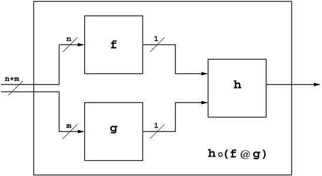

图 2.3 在 spread-combine 中，*n* +*m* 个实参被分配给函数 *f* 和 *g*。前 *n* 个实参交给 *f*，其余 *m* 个实参交给 *g*。随后，由接受两个实参的函数 *h* 组合它们的输出。Figure 2.3 In spread-combine the *n* +*m* arguments are split between the functions *f* and *g*. The first *n* arguments go to *f* and the *m* other arguments go to *g*. The resulting outputs are then combined by the function *h*, of two arguments.

实现 spread-combine 的程序比 parallel-combine 稍复杂一些，因为它必须将正确的实参分配给 f 和 g。下面是代码的初稿：The program to implement spread-combine is a bit more complicated than parallel-combine, because it must distribute the correct arguments to f and g. Here is a first draft of that code:

```
(define (spread-combine h f g)

  (let ((n (get-arity f)))

    (define (the-combination . args)

      (h (apply f (list-head args n))

         (apply g (list-tail args n))))

    the-combination))
```

这段代码需要一种确定过程接受多少个实参（即其元数）的方法，因为它必须先选出 f 的实参，再将余下的实参传给 g。This code requires a way of determining how many arguments a procedure takes (its *arity*), because it has to pick out the arguments for f and then pass the rest to g.

这个版本的 spread-combine 不太好。最严重的问题是，the-combination 接受任意数量的实参，因此没有明确定义的数值元数，也就无法传给另一个需要知道其元数的组合子。例如，某个 spread-combine 的结果不能作为第二个实参 f 传给另一个 spread-combine。所以，我们必须设法为 the-combination 附上适当的元数。下面是第二稿：This version of spread-combine is not very good. The most egregious problem is that the-combination takes any number of arguments, so it does not have a well-defined numerical arity, and thus it cannot be passed to another combinator that needs its arity. For example, the result of a spread-combine cannot be passed as the second argument f to another spread-combine. So, somehow, we have to decorate the-combination with an appropriate arity. Here is a second draft:

```
(define (spread-combine h f g)

  (let ((n (get-arity f)) (m (get-arity g)))

    (let ((t (+ n m)))

      (define (the-combination . args)

        (h (apply f (list-head args n))

           (apply g (list-tail args n))))

      (restrict-arity the-combination t))))
```

这里，返回的过程 the-combination 已经指明了元数，因此可以作为某个需要元数的其他组合子的输入。restrict-arity 过程接受一个过程，为它加上注记，使 get-arity 能获取其元数，然后返回带注记的过程。Here, the procedure the-combination that is returned has its arity specified, so it can be the input to some other combinator that requires an arity. The restrict-arity procedure takes a procedure, annotates it so that its arity can be obtained by get-arity, and returns the annotated procedure.

这已经相当不错，但最好的程序是偏执狂写出来的！我们希望尽早捕获错误，赶在它们变得难以定位或引发严重问题之前。因此，让我们采用“偏执式编程风格”，给这段代码加上一个断言，检查传给组合结果的实参数量是否正确。This is pretty good, but the best programs are written by paranoids! We want to catch errors as early as possible, before they become hard to locate or cause serious trouble. So let's annotate this code with an *assertion* in *Paranoid Programming Style*, to check that we have the right number of arguments to our combination.

```
(define (spread-combine h f g)

  (let ((n (get-arity f)) (m (get-arity g)))

    (let ((t (+ n m)))

      (define (the-combination . args)

        (assert (= (length args) t))

        (h (apply f (list-head args n))

           (apply g (list-tail args n))))

      (restrict-arity the-combination t))))



((spread-combine list

                 (lambda (x y) (list ’foo x y))

                 (lambda (u v w) (list ’bar u v w)))

 ’a ’b ’c 'd ’e)

((foo a b) (bar c d e))
```

特殊形式 assert 只是在其实参不为真值时发出错误信号的一种便捷方式。The special form assert is just a convenient way to signal an error if its argument does not have a true value.

restrict-arity 和 get-arity 的一种写法如下：One way to write restrict-arity and get-arity is as follows:

```
(define (restrict-arity proc nargs)

  (hash-table-set! arity-table proc nargs)

  proc)



(define (get-arity proc)

  (or (hash-table-ref/default arity-table proc #f)

      (let ((a (procedure-arity proc))) ;arity not in table

        (assert (eqv? (procedure-arity-min a)

                      (procedure-arity-max a)))

        (procedure-arity-min a))))

(define arity-table (make-key-weak-eqv-hash-table))
```

这里，我们用散列表给过程贴上一张“便条”。<sup>4</sup> 这是向现有对象添加信息的一种简单技巧，但它依赖被注记对象的唯一性，因此应谨慎使用。Here we are using a hash table to attach a “sticky note” to the procedure.<sup>4</sup> This is a simple trick for adding information to an existing object, but it depends on the uniqueness of the object being annotated, so it should be used carefully.

如果过程 get-arity 无法在 arity-table 中找到显式的值，就使用底层 MIT/GNU Scheme 系统的基本过程来计算。这里有些棘手，因为这些基本过程支持更一般的元数概念：一个过程要求至少接受一定数量的实参，还可能有一个可选的实参数量上限。我们的元数代码假定元数是固定的实参数量，因此 get-arity 无法处理其他种类的过程。不幸的是，这就排除了像 + 这样接受任意数量实参的过程。修改元数代码以使用更一般的元数概念会增加其复杂性，而我们在这里的目标是清晰地阐述，而非给出通用解法（见练习 2.2）。If the procedure get-arity is unable to find an explicit value in arity-table, it computes one using primitives from the underlying MIT/GNU Scheme system. This involves some hair, because those primitives support a more general idea of arity: that a procedure requires a minimum number of arguments, and may have an optional maximum number of arguments. Our arity code expects an arity to be a fixed number of arguments, and so get-arity cannot work with any other kind of procedure. Unfortunately, this excludes procedures like + that take any number of arguments. Changing the arity code to use a more general notion of arity would complicate it, and our goal here is to have a clear exposition rather than a general solution (see exercise 2.2).

## 练习 2.1：修正元数Exercise 2.1: Arity repair

我们介绍的过程 compose 和 parallel-combine 不符合公布组合结果元数的要求。因此，它们还算不上组合子家族中的好成员。修正上面给出的 compose 和 parallel-combine 的实现，使它们满足：The procedures compose and parallel-combine that we have introduced do not obey the requirement that they advertise the arity of the combination. Thus they would not be good citizens of our family of combinators. Fix the implementations of compose and parallel-combine shown above, so that

- 检查各组件，确保元数兼容；they check their components to make sure that the arities are compatible;
- 构造出的组合在被调用时，检查收到的实参数量是否正确；the combination they construct checks that it is given the correct number of arguments when it is called;
- 组合向 get-arity 正确地公布其元数。the combination advertises its arity correctly for get-arity.

## 练习 2.2：扩展元数Exercise 2.2: Arity extension

我们对实用组合子的阐述有个缺陷：展示的元数机制无法处理 MIT/GNU Scheme 所使用的更一般的元数机制。例如，加法过程，即 + 的值，可以接受任意数量的实参：Our exposition of useful combinators is flawed in that the arity mechanism we displayed cannot handle the more general arity mechanism used by MIT/GNU Scheme. For example, the addition procedure, which is the value of +, can take any number of arguments:

```
(procedure-arity-min (procedure-arity +)) = 0

(procedure-arity-max (procedure-arity +)) = #f
```

而反正切过程可以接受 1 个或 2 个实参：and the arctangent procedure can take either 1 or 2 arguments:

```
(procedure-arity-min (procedure-arity atan)) = 1

(procedure-arity-max (procedure-arity atan)) = 2
```

扩展元数的处理方式，使组合子能够应对这些更复杂的情况，是很有用的。It is useful to extend the handling of arities so that combinators can work with these more complex situations.

1. a. 概述一个扩展组合子的方案，使其使用更一般的元数。注意，你不一定总能对元数进行算术运算。重新设计 spread-combine 时，你必须作出哪些选择？例如，在 spread-combine 中，需要对过程 f、g 和 h 施加哪些限制？**a.** Sketch a plan for how to extend the combinators to use the more general arities. Note that you may not always be able to use arithmetic on the arities. What choices will you have to make in reformulating spread-combine? For example, what kinds of restrictions will be needed on the procedures f, g, and h in spread-combine?
2. b. 实施你的方案，让一切正常运转！**b.** Apply your plan and make it all work!

任何语言都有基本元素、组合手段和抽象手段。组合子语言定义基本元素和组合手段，并从底层编程语言继承抽象手段。在我们的例子中，基本元素是函数，组合手段则是组合子 compose、parallel-combine、spread-combine，以及我们可能引入的其他组合子。For any language there are primitives, means of combination, and means of abstraction. A *combinator language* defines primitives and means of combination, inheriting its means of abstraction from the underlying programming language. In our example, the primitives are functions, and the means of combination are the combinators compose, parallel-combine, spread-combine, and others we may introduce.

#### 多值Multiple values

注意，parallel-combine 和 spread-combine 有一个共同点：二者都将合并函数 h 应用于 f 和 g 的结果。但我们构造这些组合子时，没有使用 compose。要抽象出这一模式，就必须能够从 f 和 g 的组合中返回多个值，再将这些值作为 h 的实参。可以通过返回一个复合数据结构做到这一点，但更好的办法是使用 Scheme 的多值返回机制。有了多值，就能把 spread-combine 定义为两部分的复合：h，以及 f 和 g 的这一组合：<sup>5</sup>Notice that parallel-combine and spread-combine are similar in that each is the application of a combiner h to the results of f and g. But we did not use compose to construct these combinators. To abstract this pattern we need to be able to return multiple values from the combination of f and g and then use those multiple values as arguments for h. We could do this by returning a compound data structure, but a better way is to use the Scheme multiple-value return mechanism. Given multiple values we can define spread-combine as a composition of two parts, h and this combination of f and g:<sup>5</sup>

```
(define (spread-apply f g)

  (let ((n (get-arity f)) (m (get-arity g)))

    (let ((t (+ n m)))

      (define (the-combination . args)

        (assert (= (length args) t))

        (values (apply f (list-head args n))

                (apply g (list-tail args n))))

      (restrict-arity the-combination t))))
```

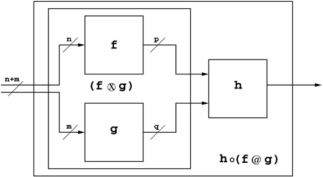

图 2.4 组合子 spread-combine 实际上是两部分的复合。第一部分 spread-apply 将函数 *f* 和 *g* 组合起来，并将正确的实参送给它们。第二部分是合并函数 *h*，只需将它与第一部分复合即可。使用 Scheme 的多值机制，才能进行这种分解。Figure 2.4 The combinator spread-combine is really a composition of two parts. The first part, spread-apply, is the combination of the functions *f* and *g* with the correct arguments routed to them. The second part is the combiner *h*, which is just composed with the first part. This decomposition is enabled by use of the multiple-values mechanism of Scheme.

Scheme 过程 values 返回分别应用 f 和 g 所得的结果。<sup>6</sup>The Scheme procedure values returns the results of applying both f and g.<sup>6</sup>

下面，我们将推广 compose，以便如下直接实现图 2.4 所示的抽象：Below we will generalize compose so that we can directly implement the abstraction shown in figure 2.4 as follows:

```
(define (spread-combine h f g)

  (compose h (spread-apply f g)))
```

它与最初版本的行为相同：This has the same behavior as our original version:

```
((spread-combine list

                 (lambda (x y) (list ’foo x y))

                 (lambda (u v w) (list ’bar u v w)))

 ’a ’b ’c 'd ’e)

((foo a b) (bar c d e))
```

为此，我们推广 compose，使多个值能够在参与复合的过程之间传递：To make this work, we generalize compose to allow multiple values to pass between the composed procedures:

```
(define (compose f g)

  (define (the-composition . args)

    (call-with-values (lambda () (apply g args))

      f))

  (restrict-arity the-composition (get-arity g)))
```

这里，传给 compose 的第二个实参返回两个值：Here the second argument to compose returns two values:

```
((compose (lambda (a b)

            (list ’foo a b))

          (lambda (x)

            (values (list ’bar x)

                    (list ’baz x))))

 ’z)

(foo (bar z) (baz z))
```

现在还可以进一步推广：允许所有被组合的函数都返回多个值。如果 f 和 g 都返回多个值，我们就可以将这些值汇集成 the-combination 可以返回的多个值：Now we can generalize even further. We can allow all of the functions we are combining to return multiple values. If f and g both return multiple values we can combine those values into multiple values that the-combination can return:

```
(define (spread-apply f g)

  (let ((n (get-arity f)) (m (get-arity g)))

    (let ((t (+ n m)))

      (define (the-combination . args)

        (assert (= (length args) t))

        (let-values ((fv (apply f (list-head args n)))

                     (gv (apply g (list-tail args n))))

          (apply values (append fv gv))))

      (restrict-arity the-combination t))))

((spread-combine list

                 (lambda (x y) (values x y))

                 (lambda (u v w) (values w v u)))

 ’a ’b ’c 'd ’e)

(a b e d c)
```

唯一的限制是，返回值的总数必须符合 h 的元数要求。The only restriction is that the total number of values returned must be appropriate for the arity of h.

## 练习 2.3：一道快题Exercise 2.3: A quickie

将 parallel-combine 改写为两部分的复合，并允许各部分返回多个值。Reformulate parallel-combine to be a composition of two parts and to allow the parts to return multiple values.

#### 一个小型程序库A small library

许多常见的使用模式都可以提炼为组合子，使用这类技术往往能够构造出非常优雅的程序。揭示并抽象这些常见模式对我们大有裨益。下面再给出几个供大家思考。Many common patterns of usage can be captured as combinators, and very pretty programs are often constructed using such techniques. It is to our advantage to expose and abstract such common patterns. Here are a few more to think about.

我们常常会有一个接口，其通用程度超出了某一具体情形的需要。这时，我们可能希望保留该接口，但调用一个更专门化的过程，它不需要一般情况下可以提供的全部参数；于是，我们选择为这个专门化过程制作一个忽略某些实参的版本。Often we have an interface that is more general than necessary in a particular situation. In such a case we may want to preserve the interface, but call some more specialized procedure that does not need all of the parameters we can supply in the general case; so we choose to make a version of our specialized procedure that ignores some arguments.

过程 discard-argument 接受要丢弃的实参的索引 i，并返回一个组合子。这个组合子接受一个有 *n* 个实参的函数 f，返回一个有 *n* + 1 个实参的新函数 the-combination；新函数从给定的 *n* + 1 个实参中删去第 *i* 个实参，再将 f 应用于剩下的 *n* 个实参。图 2.5 说明了这个想法。该组合子的代码如下：The procedure discard-argument takes the index, i, of the argument to be discarded and returns a combinator. The combinator takes a function, f, of *n* arguments and returns a new function the-combination of *n* + 1 arguments that applies f to the *n* arguments resulting from deleting the *i*th argument from the *n* + 1 given arguments. Figure 2.5 illustrates this idea. The code for this combinator is:

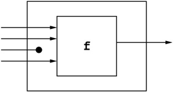

图 2.5 组合子 (discard-argument 2) 接受一个三实参函数 *f*，构造出一个新的四实参函数：它忽略第三个实参（i=2），将其余实参传给 *f*。Figure 2.5 The combinator (discard-argument 2) takes a three-argument function *f* and makes a new function of four arguments that ignores its third argument (i=2) and passes the remaining arguments to *f*.

```
(define (discard-argument i)

  (assert (exact-nonnegative-integer? i))

  (lambda (f)

    (let ((m (+ (get-arity f) 1)))

      (define (the-combination . args)

        (assert (= (length args) m))

        (apply f (list-remove args i)))

      (assert (< i m))

      (restrict-arity the-combination m))))



(define (list-remove lst index)

  (let lp ((lst lst) (index index))

    (if (= index 0)

        (cdr lst)

        (cons (car lst) (lp (cdr lst) (- index 1))))))



(((discard-argument 2)

  (lambda (x y z) (list ’foo x y z)))

 ’a ’b ’c 'd)

(foo a b d)
```

可以推广这个组合子，使其丢弃多个实参。与 discard-argument 相反的情况也经常出现。图 2.6 的接线图展示了如何通过预先指定除一个实参以外的所有实参，来专门化一个过程，而留下的那个实参由调用时传入。这种做法传统上称为柯里化，以纪念逻辑学家 Haskell Curry；他是组合逻辑的早期研究者。<sup>7</sup>One can generalize this combinator to discard multiple arguments. The opposite of the situation of discard-argument also commonly occurs. In figure 2.6 we see a wiring diagram for specializing a procedure by specifying all but one argument in advance, leaving one to be passed in the call. This is traditionally called *currying* in honor of the logician Haskell Curry, who was an early investigator of combinatory logic.<sup>7</sup>

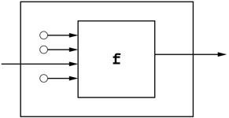

图 2.6 组合子（(curry-argument 2) ’a ’b ’c）为四实参函数 *f* 指定了三个实参，留下第三个实参（i=2），在调用所得的单实参函数时提供。Figure 2.6 The combinator ((curry-argument 2) ’a ’b ’c) specifies three of the arguments to the four-argument function *f* , leaving the third argument (i=2) to be supplied in the call to the resulting one-argument function.

curry-argument 的代码没有什么出人意料之处：The code for curry-argument poses no surprises:

```
(define ((curry-argument i) . args)

  (lambda (f)

    (assert (= (length args) (- (get-arity f) 1)))

    (lambda (x)

      (apply f (list-insert args i x)))))



(define (list-insert lst index value)

  (let lp ((lst lst) (index index))

    (if (= index 0)

        (cons value lst)

        (cons (car lst) (lp (cdr lst) (- index 1))))))



((((curry-argument 2) ’a ’b ’c)

  (lambda (x y z w) (list ’foo x y z w)))

 'd)

(foo a b d c)
```

注意，这里不需要使用 restrict-arity，因为返回的过程恰好只有一个实参。<sup>8</sup> 在练习 2.5 中，我们将推广这个柯里化组合子，让它留下多个实参待提供。Note that here we do not need to use restrict-arity because the returned procedure has exactly one argument.<sup>8</sup> In exercise 2.5 we generalize this combinator for currying, to leave multiple arguments to be supplied.

有时，我们想使用一个库过程，但其实参顺序不同于当前应用采用的标准。与其为这个过程制作专用接口，不如用一个通用的置换过程来重新排列，如图 2.7 所示。这个程序也很简单，但请注意：组合子返回的、实际处理 args 的过程 the-combination，不必再解释置换规格——这项工作只在包围 the-combination 的 let 中做一次，内部只需引用其结果。一般来说，这种写法允许通过提前计算进行某些深度优化，即使绑定发生得非常晚也一样！Sometimes we want to use a library procedure that has a different order of arguments than the standard that we are using in the current application. Rather than make a special interface for that procedure, we can use a general permutation procedure to rearrange things, as in figure 2.7. This program is also simple, but notice that the procedure the-combination that is returned from the combinator and actually runs on args does not have to interpret the permutation specification—this is done once in the let surrounding the-combination and referred to within. In general, writing code this way allows some deep optimizations by early computation, even in the light of very late binding!

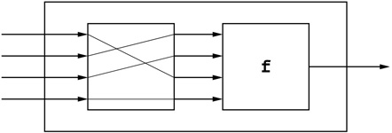

图 2.7 组合子 (permute-arguments 1 2 0 3) 接受一个四实参函数 *f*，产生一个新的四实参函数：新函数先按照给定的置换重排实参，再将它们传给 *f*。Figure 2.7 The combinator (permute-arguments 1 2 0 3) takes a function *f* of four arguments and produces a new function of four arguments that permutes its arguments according to the supplied permutation before passing them to *f*.

```
(define (permute-arguments . permspec)

  (let ((permute (make-permutation permspec)))

    (lambda (f)

      (define (the-combination . args)

        (apply f (permute args)))

      (let ((n (get-arity f)))

        (assert (= n (length permspec)))

        (restrict-arity the-combination n)))))



(((permute-arguments 1 2 0 3)

  (lambda (x y z w) (list ’foo x y z w)))

 ’a ’b ’c 'd)

(foo b c a d)
```

过程 make-permutation 很简单，但效率不高：The procedure make-permutation is simple, but it is not efficient:

```
(define (make-permutation permspec)

  (define (the-permuter lst)

    (map (lambda (p) (list-ref lst p))

         permspec))

  the-permuter)
```

### 2.1.2 组合子与构型2.1.2 Combinators and body plans

这一讨论的一个启示是：由组合子的组合所构成的结构就是一种构型，很像动物的构型，或超外差无线电接收机这样的工程模式（第 10 页图 1.1）。考虑 compose 组合子。它安排了若干局部区域，即过程 f 和 g。这些局部区域通过标准连接方式相连，而这就是对 f 和 g 的全部要求。事实上，这些组件可以是任何能接受正确数量的实参并返回正确数量的值的东西。因此，组合子是一种组织原则，就像 Hox 基因一样：它们规定局部区域及其相互关系，却不强制规定每个局部区域内部要发生什么。A moral of this story is that a structure composed of combinations of combinators is a body plan, much like the body plans of animals or engineering patterns like the superheterodyne radio receiver (figure 1.1 on page 10). Consider the compose combinator. It provides an arrangement of locales, the procedures f and g. The locales are connected by a standard interconnect, but that is all that is required of f and g. Indeed, these components may be anything that can take the right number of arguments and can return the right number of values. So the combinators are organizing principles, like Hox genes: they specify locales and their relationship without mandating what happens inside each locale.

## 练习 2.4：写成复合？Exercise 2.4: As compositions?

你可能已经注意到，discard-argument、curry-argument 和 permute-arguments 生成的组合子，都可以看作一次实参变换与一个过程的复合。利用多值返回机制，将这些组合子重新构建为复合。You may have noticed that the combinators made by discard-argument, curry-argument, and permute-arguments can each be thought of as a composition of an argument manipulation and a procedure. Rebuild these combinators as compositions using the multiple-value return mechanism.

## 练习 2.5：实用组合子Exercise 2.5: Useful combinators

现在该把这个小型程序库再充实一些了。It is time to fill out this small library a bit more.

1. a. 可以推广组合子 discard-argument 和 curry-argument，允许忽略多个实参，或者预先指定多个实参来进行专门化。为 permute-arguments 指定置换的方法，似乎是一种相当通用的方式，可以按实参在调用中的顺序来指定它们（从零开始计数）。构造这些过程的推广版本，采用这样的接口，将其命名为 discard-arguments 和 curry-arguments。让你的代码与正文中的代码兼容：你的（curry-arguments 2）应该与（curry-argument 2）的作用完全相同。**a.** The combinators discard-argument and curry-argument could be generalized to allow ignoring or prespecializing on more than one argument. The method of specifying the permutation for permute-arguments seems to be a pretty general way to specify arguments by their order in a call (zero-based). Build generalized versions of these procedures that have such an interface. Name them discard-arguments and curry-arguments. Make your code compatible with the code in the text: your (curry-arguments 2) should do exactly what (curry-argument 2) does.
2. b. 你觉得还有哪些组合子会有用？列一张清单，并配上你在实际代码中可能遇到的适当用例。为你的程序库实现这些组合子。**b.** What other combinators would you find useful? Make up a list, with appropriate use cases that you might encounter in actual code. Write implementations of them for your library.
3. c. 进一步推广 compose，使其接受任意数量的函数实参。表达式（compose f g h）等价于（compose f (compose g h)）。注意，它也应当等价于（compose (compose f g) h）。小心：零个实参的复合是什么？**c.** Further generalize compose so that it can take any number of functional aguments. The expression (compose f g h) is equivalent to (compose f (compose g h)). Note that it should also be equivalent to (compose (compose f g) h). Be careful: what is the composition of zero arguments?

## 2.2 正则表达式2.2 Regular expressions

正则表达式广泛用于字符串匹配。尽管正则表达式系统源自一种完全良好的数学形式体系，实现者为了将它扩充为实用的软件系统所作的具体选择，却往往是灾难性的：采用的引用约定极不规则；对括号的严重滥用——既用来分组，又用来向后引用——更是令人叹为观止。此外，为增强表达能力、弥补早期设计的缺陷所作的尝试，又导致了大量互不兼容的派生语言。Regular expressions are widely used for string matching. Although regular-expression systems are derived from a perfectly good mathematical formalism, the particular choices made by implementers to expand the formalism into useful software systems are often disastrous: the quotation conventions adopted are highly irregular; the egregious misuse of parentheses, both for grouping and for backward reference, is a miracle to behold. In addition, attempts to increase the expressive power and address shortcomings of earlier designs have led to a proliferation of incompatible derivative languages.

表面上看，正则表达式像是一种组合子语言，因为表达式片段可以组合成更复杂的表达式。但片段的含义高度依赖于它所嵌入的表达式。例如，如果想在方括号表达式 [...] 中包含脱字符 ∧，脱字符就不能位于第一个字符的位置：如果它出现在第一个字符之后，就只是普通字符；但如果它是第一个字符，就会对方括号表达式的含义取反。因此，方括号表达式中不能只有一个脱字符。On the surface, regular expressions look like a combinator language, because expression fragments can be combined to make more complex expressions. But the meaning of a fragment is highly dependent on the expression it is embedded in. For example, if we want a caret, ∧, in a bracket expression, [...], the caret must not be in the first character position, because if the caret appears after the first character it is just an ordinary character, but if it appears as the first character it negates the meaning of the bracket expression. Thus a bracket expression may not contain just a caret.

所以，正则表达式语言的语法很糟糕；这种语言有各种互不兼容的形式；引用约定也繁复怪诞 [sic]。尽管正则表达式语言属于领域专用语言，却是糟糕的领域专用语言。考察正则表达式的价值之一，就是体会事情究竟能糟糕到什么程度。So the syntax of the regular-expression language is awful; there are various incompatible forms of the language; and the quotation conventions are *baroquen* [sic]. While regular expression languages are domain-specific languages, they are bad ones. Part of the value of examining regular expressions is to experience how bad things can be.

尽管如此，仍有大量实用软件（例如 grep）使用正则表达式来指定所需行为。我们将设计一种更好的领域专用组合子语言来描述正则表达式，并提供一种方法，将其翻译为传统的正则表达式语法。我们将使用 POSIX 基本正则表达式（BRE）语法作为翻译器的目标 [96]，因为它是大多数其他正则表达式语法的子集。POSIX 还定义了一种功能更强的扩展正则表达式（ERE）语法，我们将在一道练习中考虑它。Nevertheless, there is a great deal of useful software, for example grep, that uses regular expressions to specify the desired behavior. We will invent a better domain-specific combinator language for specifying regular expressions and a means of translating this language to conventional regular-expression syntax. We will use the POSIX Basic Regular Expression (BRE) syntax as a target for our translator [96], since it is a subset of most other regular-expression syntaxes. POSIX also defines a more powerful Extended Regular Expression (ERE) syntax, which we will consider in an exercise.

有了这套机制，就能在 Scheme 环境内部使用 grep 这类系统的能力。我们将获得组合子语言的所有优点：既有清晰、模块化的描述，又保留使用现有工具的能力。这种语言的使用者将没什么好抱怨的，除非他们更看重表达简短而非可读性。With this machinery we will be able to use the capabilities of systems like grep from inside the Scheme environment. We will have all the advantages of a combinator language. It will have a clean, modular description while retaining the ability to use existing tools. Users of this language will have nothing to *grep* about, unless they value concise expression over readability.

与任何语言一样，这里也有基本元素、组合手段和抽象手段。我们的语言允许构造模式，grep 这类工具可以用它们来匹配字符串数据。由于这门语言嵌入在 Scheme 中，我们便继承了 Scheme 的能力：可以使用 Scheme 构造来组合模式，使用 Scheme 过程来抽象模式。As with any language there are primitives, means of combination, and means of abstraction. Our language allows the construction of patterns that utilities like grep can match against character-string data. Because this language is embedded in Scheme, we inherit Scheme's power: we can use Scheme constructs to combine patterns and use Scheme procedures to abstract them.

### 2.2.1 一种正则表达式组合子语言2.2.1 A regular expression combinator language

模式由下列基本模式构成：Patterns are built out of these primitive patterns:

(r:dot) 匹配换行符以外的任意字符。(r:dot) matches any character except newline

(r:bol) 只匹配行首。(r:bol) matches only the beginning of a line

(r:eol) 只匹配行尾。(r:eol) matches only the end of a line

(r:quote *string*) 匹配该字符串。(r:quote *string*) matches the *string*

(r:char-from *string*) 匹配该字符串中包含的一个字符。(r:char-from *string*) matches one character that is in the *string*

(r:char-not-from *string*) 匹配该字符串中不包含的一个字符。(r:char-not-from *string*) matches one character that is not in the *string*

模式可以组合成复合模式：Patterns can be combined to make compound patterns:

(r:seq pattern ...)(r:seq *pattern* ...)

这个模式从左到右依次匹配作为实参的各个模式。This pattern matches each argument *pattern* in sequence, from left to right.

(r:alt pattern ...)(r:alt *pattern* ...)

这个模式从左到右尝试作为实参的各个模式，直到其中一个备选项匹配成功。如果没有任何一个匹配成功，那么整个模式也不匹配。This pattern tries each argument *pattern* from left to right, until one of these alternatives matches. If none matches then this pattern does not match.

(r:repeat min max pattern)(r:repeat *min max pattern*)

这个模式尝试匹配作为实参的模式，至少 *min* 次，至多 *max* 次。如果 *max* 给为 #f，则不指定上限。如果 *max* 等于 *min*，给定模式就必须恰好匹配这么多次。This pattern tries to match the argument *pattern* a minimum of *min* times but no more than a maximum of *max* times. If *max* is given as #f then no maximum is specified. If *max* equals *min* the given pattern must be matched exactly that many times.

下面是一些模式示例：Here are some example patterns:

(r:seq (r:quote "a") (r:dot) (r:quote "c"))

匹配任何以 a 开头、以 c 结尾的三字符字符串。例如，它会匹配 abc、aac 和 acc。matches any three-character string beginning with a and ending with c. For example, it will match abc and aac and acc.

(r:alt (r:quote "foo") (r:quote "bar") (r:quote "baz"))

匹配 foo、bar 或 baz。matches either foo, bar, or baz.

(r:repeat 3 5 (r:alt (r:quote "cat") (r:quote "dog"))) 匹配 catdogcat、catcatdogdog 和 dogdogcatdogdog，但不匹配 catcatcatdogdogdog。(r:repeat 3 5 (r:alt (r:quote "cat") (r:quote "dog"))) matches catdogcat and catcatdogdog and dogdogcatdogdog but not catcatcatdogdogdog.

我们将用 Scheme 表达式实现模式。因此，可以将它们与任意 Scheme 代码自由混用，从而获得这门编程语言的全部能力。We will implement patterns as Scheme expressions. Thus we can freely mix them with any Scheme code, giving us all the power of the programming language.

### 2.2.2 翻译器的实现2.2.2 Implementation of the translator

来看看这门语言是如何实现的。正则表达式将表示为采用 POSIX 基本正则表达式语法的字符串。Let's look at how this language is implemented. Regular expressions will be represented as strings in the POSIX Basic Regular Expression syntax.

```
(define (r:dot) ".")

(define (r:bol) "∧")

(define (r:eol) "$")
```

这些与正则表达式语法直接对应。These directly correspond to regular-expression syntax.

接下来，r:seq 实现了一种将给定的一组正则表达式片段视为一个独立完整元素的方法：Next, r:seq implements a way to treat a given set of regular-expression fragments as a self-contained element:

```
(define (r:seq . exprs)

  (string-append "\\(" (apply string-append exprs) "\\)"))
```

在结果中使用括号，可以将给定表达式片段的内容与周围上下文隔离开来。不幸的是，翻译输出中必须使用 \。在基本正则表达式中，括号字符被视为表示自身的字符。这里需要它们起分组运算的作用，为此必须在每个括号前加上反斜杠。雪上加霜的是，把这个正则表达式放入 Scheme 字符串时，又必须用另一个反斜杠转义每个反斜杠字符。因此，示例 (r:seq (r:quote "a") (r:dot) (r:quote "c")) 被翻译为 \(\(a\).\(c\)\)，或者写成 Scheme 字符串就是 "\\(\\(a\\).\\(c\\)\\)"。真糟糕。The use of parentheses in the result isolates the content of the given expression fragments from the surrounding context. Unfortunately, the use of \ in the translated output is necessary. In basic regular expressions, the parenthesis characters are treated as self-quoting characters. Here we need them to act as grouping operations, which is done by preceding each with a backslash. Adding insult to injury, when this regular expression is put into a Scheme string, it is necessary to quote each backslash character with *another* *backslash*. So our example (r:seq (r:quote "a") (r:dot) (r:quote "c")) translates to \(\(a\).\(c\)\), or as a Scheme string "\\(\\(a\\).\\(c\\)\\)". Ugh.

r:quote 的实现稍难一些。在正则表达式中，大多数字符都表示自身。但某些字符是正则表达式运算符，必须显式转义。我们用 r:seq 包装结果，以确保转义后的字符串是独立完整的。The implementation of r:quote is a bit harder. In a regular expression, most characters are self-quoting. However, some characters are regular-expression operators and must be explicitly quoted. We wrap the result using r:seq to guarantee that the quoted string is self-contained.

```
(define (r:quote string)

  (r:seq

    (list->string

      (append-map (lambda (char)

                    (if (memv char chars-needing-quoting)

                        (list #\\ char)

                        (list char)))

                  (string->list string)))))



(define chars-needing-quoting

  ’(#\. #\[ #\\ #\∧ #\$ #\*))
```

为实现备选子表达式，我们在子表达式之间插入竖线，并用 r:seq 包装结果：To implement alternative subexpressions, we interpolate a vertical bar between subexpressions and wrap the result using r:seq:

```
(define (r:alt . exprs)

  (if (pair? exprs)

      (apply r:seq

             (cons (car exprs)

                   (append-map (lambda (expr)

                                 (list "\\|" expr))

                               (cdr exprs))))

      (r:seq)))
```

(r:alt (r:quote "foo") (r:quote "bar") (r:quote "baz")) 被翻译为 \(\(foo\)\|\(bar\)\|\(baz\)\)。除了转义括号字符外，还必须转义竖线字符，否则它在这种语法中就是一个表示自身的字符。注意，与这里支持的其他正则表达式不同，BRE 语法不支持备选表达式：这是 GNU grep 定义的一种扩展，许多实现都支持它。（ERE 语法支持备选项。）(r:alt (r:quote "foo") (r:quote "bar") (r:quote "baz")) translates to \(\(foo\)\|\(bar\)\|\(baz\)\). In addition to quoting the parenthesis characters, we must also quote the vertical bar character, which is otherwise a self-quoting character in this syntax. Note that alternative expressions, unlike the rest of the regular expressions supported here, are not supported by BRE syntax: they are an extension defined by GNU grep that is supported by many implementations. (Alternatives *are* supported by ERE syntax.)

使用给定正则表达式的副本来实现重复，是很直接的：It is straightforward to implement repetition by using copies of the given regular expression:

```
(define (r:repeat min max expr)

  (apply r:seq

         (append (make-list min expr)

                 (cond ((not max) (list expr "*"))

                       ((= max min) ’())

                       (else

                        (make-list (- max min)

                                   (r:alt expr "")))))))
```

这会生成 min 份 expr，后面再接 (- max min) 份可选副本；每份可选副本都是该表达式与空表达式之间的备选。如果没有上限，<sup>9</sup> 就在表达式之后加上星号，以匹配任意次数。因此，(r:repeat 3 5 (r:alt (r:quote "cat") (r:quote "dog"))) 会被翻译成一个庞然大物，读者看了恐怕都要抽搐。This makes min copies of expr, followed by (- max min) optional copies, where each optional copy is an alternative of the expression and an empty expression. If there is no maximum,<sup>9</sup> the expression is followed by an asterisk to match any number of times. So (r:repeat 3 5 (r:alt (r:quote "cat") (r:quote "dog"))) translates to something large that might cause seizures in the reader.

r:char-from 和 r:char-not-from 的实现因为需要繁复的转义处理而变得复杂。最好将其组织成两部分：第一部分处理二者的差异，第二部分处理二者共有的转义操作：The implementation of r:char-from and r:char-not-from is complicated by the need for baroque quotation. This is best organized in two parts, the first to handle the differences between them, and the second for the quotation handling that they have in common:

```
(define (r:char-from string)

  (case (string-length string)

    ((0) (r:seq))

    ((1) (r:quote string))

    (else

     (bracket string

              (lambda (members)

                (if (lset= eqv? ’(#\- #\∧) members)

                    ’(#\- #\∧)

                    (quote-bracketed-contents members)))))))



(define (r:char-not-from string)

  (bracket string

           (lambda (members)

             (cons #\∧ (quote-bracketed-contents members)))))



(define (bracket string procedure)

  (list->string

   (append ’(#\[)

           (procedure (string->list string))

           ’(#\]))))
```

r:char-from 的特殊分支专门处理空字符集和单字符集，从而简化一般情形。另有一个特殊分支处理只含脱字符和连字符的集合。但 r:char-not-from 没有这些特殊分支。The special cases for r:char-from handle empty and singleton sets of characters specially, which simplifies the general case. There is also a special case for a set containing only caret and hyphen. But r:char-not-from has no such special cases.

一般情形通过将三个在方括号内具有特殊含义的字符放在不被视为运算符的位置，来实现对它们的转义。（我们早说过这很丑陋！）The general case handles the quotation of the three characters that have special meaning inside a bracket by placing them in positions where they are not operators. (We told you this was ugly!)

```
(define (quote-bracketed-contents members)

  (define (optional char)

    (if (memv char members) (list char) ’()))

  (append (optional #\])

          (remove

            (lambda (c)

              (memv c chars-needing-quoting-in-brackets))

            members)

          (optional #\∧)

          (optional #\-)))



(define chars-needing-quoting-in-brackets

  ’(#\] #\∧ #\-))
```

为了测试这段代码，可以打印出对应的 grep 命令，再通过剪切粘贴在 shell 中运行。由于不同 shell 使用不同的引用约定，我们不仅需要引用正则表达式，还要选择使用哪种 shell。Bourne shell 随处可见，其引用约定也相对简单。In order to test this code, we can print the corresponding grep command and use cut and paste to run it in a shell. Because different shells use different quoting conventions, we need to not only quote the regular expression, but also choose which shell to use. The Bourne shell is ubiquitous, and has a relatively simple quoting convention.

```
(define (write-bourne-shell-grep-command expr filename)

  (display (bourne-shell-grep-command-string expr filename)))



(define (bourne-shell-grep-command-string expr filename)

  (string-append "grep -e "

                 (bourne-shell-quote-string expr)

                 " "

                 filename))
```

Bourne 的引用约定用单引号包围字符串，可以引用字符串中除单引号外的任何内容；单引号会终止被引用的字符串。因此，要引用单引号字符，必须先结束字符串，用反斜杠显式转义该单引号，再开始另一个被引用的字符串。shell 会把这种拼接解释为单个词元。（现在觉得好玩了吗？）The Bourne quoting convention uses single-quote characters surrounding a string, which quotes anything in the string other than a single-quote, which ends the quoted string. So, to quote a single-quote character, we must end the string, quote the single quote explicitly using backslash, and then start another quoted string. The shell interprets this concatenation as a single token. (Are we having fun yet?)

```
(define (bourne-shell-quote-string string)

  (list->string

   (append (list #\’)

           (append-map (lambda (char)

                         (if (char=? char #\’)

                             (list #\’ #\\ char #\’)

                             (list char)))

                       (string->list string))

           (list #\’))))
```

#### 这段讨论的启示The moral of this story

我们的翻译器非常复杂，因为大多数正则表达式都不能直接组合成更大的正则表达式，除非采取极端手段将各部分隔离开来。翻译器完成了这项工作，但也因此生成了带有大量不必要样板内容的正则表达式。人类并不这样编写正则表达式，因为他们只在必要的地方使用样板内容——但也往往漏掉确实需要的地方，从而引入难以发现的错误。Our translator is very complicated because most regular expressions are not composable to make larger regular expressions unless extreme measures are taken to isolate the parts. Our translator does this work, but consequently the regular expressions that it generates have much unnecessary boilerplate. Humans don't write regular expressions this way, because they use boilerplate only where necessary—but they often miss instances where it is necessary, causing hard-to-find bugs.

这段讨论的启示是：正则表达式是一个绝好的反面教材，展示了不该如何构建系统。使用可组合的部件和组合子，通过组合已有部件来构造新部件，能够得到更简单、更健壮的实现。The moral of this story is that regular expressions are a beautiful example of how *not* to build a system. Using composable parts and combinators to make new parts by combining others leads to simpler and more robust implementations.

## 练习 2.6：为正则表达式添加 * 和 +Exercise 2.6: Adding * and + to regular expressions

在传统的正则表达式语言中，位于子模式之后的星号（*）运算符表示该子模式出现零次或多次。这门语言的一种常见扩展加入了加号（+）运算符。子模式之后的加号表示该子模式出现一次或多次。In the traditional regular expression language the asterisk (*) operator following a subpattern means zero or more copies of the subpattern. A common extension to the language adds the plus-sign (+) operator. A plus sign following a subpattern means one or more copies of the subpattern.

定义 Scheme 过程 r:* 和 r:+，使它们接受一个模式，并按要求重复该模式。这可以用 r:repeat 来实现。Define Scheme procedures r:* and r:+ to take a pattern and iterate it as necessary. This can be done in terms of r:repeat.

在复杂模式中，使用真实数据演示你的过程。Demonstrate your procedures on real data in complex patterns.

## 练习 2.7：一个错误、一个烂笑话、两处微调，以及一个顿悟Exercise 2.7: A bug, one bad joke, two tweaks, and a revelation

Ben Bitdiddle 注意到，我们对 (r:repeat min max expr) 的实现存在一个问题。Ben Bitdiddle has noticed a problem with our implementation of (r:repeat *min max expr*).

在 r:repeat 过程的末尾使用（r:alt expr ""）有些不可靠。这段代码会被翻译成 \(expr\|\)，其中 expr 是 expr 的值。这依赖于这样一个事实：在某个东西与空之间进行备选，就等于说“一个或没有”。（在接下来的说明中，我们将省略那些必需却令人困惑的反斜杠。）也就是说，(expr|) 表示 expr 出现一次或零次。不幸的是，这依赖于正式 POSIX 正则表达式标准之外的一项未记载的 GNU 扩展。The use of (r:alt expr "") at the end of the r:repeat procedure is a bit dodgy. This code fragment translates to \(*expr*\|\), where *expr* is the value of expr. This relies on the fact that alternation with something and nothing is the equivalent of saying “one or none.” (We will omit the required but confusing backslashes in the rest of this explanation.) That is: (*expr*|) denotes one or no instances of *expr*. Unfortunately, this depends on an undocumented GNU extension to the formal POSIX standard for REs.

具体来说，POSIX 标准<sup>10</sup> 的第 9.4.3 节规定，竖线紧接在右括号之前（或紧接在左括号之后）会产生未定义行为。实质上，正则表达式不得是空序列。Specifically, section 9.4.3 of the POSIX standard<sup>10</sup> states that a vertical line appearing immediately before a close parenthesis (or immediately after an open parenthesis) produces undefined behavior. In essence, an RE must not be a null sequence.

GNU grep 碰巧在遇到 (*x*|) 时“做了正确的事”。并非所有 grep 实现都如此宽容。GNU grep just happens to “do the right thing” when presented with (*x*|). Not all grep implementations are as tolerant.

因此，Ben 请团队中的三位代码高手（Louis、Alyssa 和 Eva）提出其他变通方案。最后，他自己也提出了一项补丁，你将实现它。Therefore, Ben asks his team of three code hackers (Louis, Alyssa, and Eva) to propose alternative workarounds. Ultimately, he proposes his own patch, which you will implement.

- Louis Reasoner 提议，一个简单、优雅的修正办法，是把代码片段（r:alt expr ""）换成对（r:repeat 0 1 expr）的直接调用。Louis Reasoner suggests that a simple, elegant fix would be to replace the code fragment (r:alt expr "") with a straightforward call to (r:repeat 0 1 expr).
- Alyssa P. Hacker 提议重写 r:repeat 的 else 分支，将（r:repeat 3 5 *x*）翻译成等价于 (xxx|xxxx|xxxxx) 的表达式，而不是我们的代码所生成的、糟糕的 xxx(*x*|)(*x*|)——这种正则表达式不符合 POSIX 标准，行为未定义。她引用的是 POSIX 正则表达式文档的第 9.4.7 节。<sup>11</sup>Alyssa P. Hacker proposes to rewrite the else clause of r:repeat to translate (r:repeat 3 5 *x*) into the equivalent of (*xxx*|*xxxx*|*xxxxx*) instead of the naughty *xxx*(*x*|)(*x*|) non-POSIX-compliant undefined regular expression that our code produces. She refers to section 9.4.7 of the POSIX regular expression documentation.<sup>11</sup>
- Eva Lu Ator 指出了第 9.4.6.4 节<sup>12</sup> 的问号（?）运算符，提出更好的修正办法是实现一个 r:? 运算符，并将（r:alt expr ""）替换为（r:? expr）。Eva Lu Ator points to the question mark (?) operator in section 9.4.6.4<sup>12</sup> and proposes that a better fix would be to implement an r:? operator and replace (r:alt expr "") with (r:? expr).
- 与此同时，Ben 仔细研究正则表达式规格说明后有了顿悟。他建议重新实现 r:repeat，使其输出区间表达式。参见 POSIX 文档第 9.3.6.5 节。<sup>13</sup>Meanwhile, Ben looks closely at the RE spec and has a revelation. He proposes that r:repeat be reimplemented to emit Interval Expressions. See section 9.3.6.5 of the POSIX documentation.<sup>13</sup>

  请尽量忍住，别吐。Please try not to get sick.

我们来逐一考察这些提议：Let's consider each proposal:

1. a. 大家都被 Louis 的傻笑话逗笑了。它究竟好笑在哪里？也就是说，这个想法有什么问题？**a.** Everyone giggles at Louis's silly joke. What's so funny about it? That is, what's wrong with this idea?

   用一句话点出笑点即可。A one-sentence punchline will do.
2. b. 从代码和数据两方面看，Eva 的提议相比 Alyssa 的提议有什么优点？**b.** What advantages does Eva's proposal have over Alyssa's in terms of both code and data?

   简洁而有说服力地回答几句话即可。A concise yet convincing few sentences suffice.
3. c. Ben 的提议相比所有其他提议有什么优势？具体来说，想一想他引用的是 POSIX 文档的哪一节，而其他人引用的又是哪几节；然后快速看一下后面的练习 2.10，考虑其中的含义。此外，还要考虑新代码输出字符串的大小，以及代码整体的清晰程度。**c.** What advantage does Ben's proposal have over all the others? Specifically, ponder which section of the POSIX document he cites versus which sections the others cite, then take a quick peek at exercise 2.10 below and consider the implications. Also, consider the size of the output strings in this new code as well as the overall clarity of the code.

   同样，简要回答一两句话即可。Again, a brief sentence or two is sufficient.
4. d. 按照 Ben 的提议，重新实现 r:repeat，使其输出区间表达式。提示：Scheme 的 number->string 过程应当能派上用场。注意：小心反斜杠。**d.** Following Ben's proposal, reimplement r:repeat to emit Interval Expressions. Hint: Scheme's number->string procedure should be handy. Caveat: Beware the backslashes.

   选取几个恰当的示例输入，展示 r:repeat 生成的输出。在一些复杂模式中，使用真实数据演示你的过程。Show the output generated by r:repeat on a few well-chosen sample inputs. Demonstrate your procedure on real data in some complex patterns.

## 练习 2.8：嵌套过多Exercise 2.8: Too much nesting

我们的程序产生的正则表达式嵌套过多：即使不需要，也会创建分组。例如，下面这个简单模式就导致了一个过于复杂的正则表达式：Our program produces excessively nested regular expressions: it makes groups even when they are not necessary. For example, the following simple pattern leads to an overly complex regular expression:

```
(display (r:seq (r:quote "a") (r:dot) (r:quote "c")))

\(\(a\).\(c\)\)
```

另一个问题是，BRE 可能涉及反向引用。（见 POSIX 正则表达式文档第 9.3.6.3 节。<sup>14</sup>）反向引用指向前面某个带括号的子表达式。因此，带括号的子表达式应当由模式的作者显式指定，这一点很重要。（啊！这是我们听过的最糟糕的主意之一——将迭代所必需的分组，与供以后引用的命名混为一谈！）Another problem is that BREs may involve back-references. (See section 9.3.6.3 of the POSIX regular expression documentation.<sup>14</sup>) A back-reference refers to a preceding parenthesized subexpression. So it is important that the parenthesized subexpressions be ones explicitly placed by the author of the pattern. (Aargh! This is one of the worst ideas we have ever heard of—grouping, which is necessary for iteration, was confused with naming for later reference!)

任务：修改我们的程序，尽可能消除不必要的嵌套。注意：这里有一些微妙情形，必须留心。举出一个这样的情形。演示你改进后的程序版本，并展示它如何处理这些微妙之处。**To do:** Edit our program to eliminate as much of the unnecessary nesting as you can. Caution: There are subtle cases here that you have to watch out for. What is such a case? Demonstrate your better version of our program and show how it handles the subtleties.

提示：我们的程序既用字符串作为中间表示，也用它作为结果。你可以考虑采用另一种中间表示。Hint: Our program uses strings as its intermediate representation as well as its result. You might consider using a different intermediate representation.

## 练习 2.9：反向引用Exercise 2.9: Back-references

添加一个构造反向引用的过程。（见练习 2.8。）尽情享受被 BRE 搞糊涂的乐趣吧。Add a procedure for constructing back-references. (See exercise 2.8.) Have fun getting confused about BREs.

## 练习 2.10：标准？Exercise 2.10: Standards?

> 标准最妙的地方在于，有那么多种可供选择。The best thing about standards is that there are so many to choose from.

> Andrew S. TannenbaumAndrew S. Tannenbaum

除了基本正则表达式（BRE），POSIX 正则表达式文档 [96] 还定义了扩展正则表达式（ERE）。一些软件（如 egrep）使用这个版本的正则表达式。不幸的是，ERE 并不是 BRE 的保守扩展：ERE 语法实际上与 BRE 语法不一致！扩展我们的 Scheme 模式语言，使翻译目标既可以是 BRE，也可以是 ERE，会是一个有趣的项目。In addition to Basic Regular Expressions (BREs), there are Extended Regular Expressions (EREs) defined in the POSIX regular expression documentation [96]. Some software, such as egrep, uses this version of regular expressions. Unfortunately EREs are not a conservative extension of BREs: ERE syntax is actually inconsistent with BRE syntax! It is an interesting project to extend our Scheme pattern language so that the target can be either BREs or EREs.

1. a. BRE 和 ERE 之间有哪些重要差异，使这件事变得棘手？列出必须处理的差异。**a.** What are the significant differences between BREs and EREs that make this a pain? List the differences that must be addressed.
2. b. 如何分解我们的翻译器，使这门语言能够根据需要翻译成任一种正则表达式？如何保持一个独立于目标正则表达式语言的抽象层？说明你的策略。**b.** How can our translator be factored so that our language can translate into either kind of regular expression, depending on what is needed? How can we maintain the abstract layer that is independent of the target regular expression language? Explain your strategy.
3. c. 实现你在 b 部分设计的策略。通过演示来验证你的成果：确保既能运行 egrep，也能运行 grep，并在检验 a 部分所发现差异的各种情况下得到等价的结果。**c.** Implement the strategy you devised in part **b**. Demonstrate your work by making sure that you can run egrep as well as grep, with equivalent results in cases that test the differences you found in part **a**.

## 2.3 包装器2.3 Wrappers

有时，只需包装现有程序而不必重写，就可以将其改作他用。考虑这样一个问题：在保持压强不变的情况下，计算一团球形气体的半径如何随温度变化。理想气体定律为：Sometimes we can repurpose an existing program by wrapping it rather than rewriting it. Consider the problem of computing how the radius of a sphere of gas varies with the temperature, keeping the pressure constant. The ideal gas law is

其中，*P* 是压强，*V* 是体积，*n* 是气体的物质的量，*R* 是气体常量，*T* 是温度。因此，体积可用以下方式计算：where *P* is the pressure, *V* is the volume, *n* is the amount of the gas, *R* is the gas constant, and *T* is the temperature. So the volume is computed by

```
(define (gas-law-volume pressure temperature amount)

  (/ (* amount gas-constant temperature) pressure))



(define gas-constant 8.3144621)         ;J/(K*mol)
```

而球的半径可用以下方式计算：and the radius of a sphere is computed by

```
(define (sphere-radius volume)

  (expt (/ volume (* 4/3 pi)) 1/3))



(define pi (* 4 (atan 1 1)))
```

（注意：4/3 和 1/3 是有理数常量——斜杠不是中缀除法运算符。）所选用的气体常量使这个程序采用 SI 单位，因此压强以牛顿每平方米计，温度以开尔文计，物质的量以摩尔计，体积以立方米计，半径以米计。(Note: 4/3 and 1/3 are rational constants—the slash is not an infix division operator.) The choice of gas constant makes this program use SI units, so the pressure is in newtons per square meter, the temperature is in kelvins, the amount is in moles, the volume is in cubic meters, and the radius is in meters.

这看起来很直接，但使用其他单位就可能让事情变得复杂。假设我们想用华氏度测量温度，用磅每平方英寸测量压强，用英寸测量半径。确定正确公式比算出数值答案更复杂。可以修改这个简单公式，把单位考虑进去，但这样会掩盖程序的思想，并让它专门针对这个特定问题。另一种做法是，以模块化的方式进行单位换算。This looks straightforward, but use of other units can make things complicated. Suppose we want to measure the temperature in degrees Fahrenheit, the pressure in pounds per square inch, and the radius in inches. Determining the correct formula is more complicated than computing the numerical answer. We could modify the simple formula to account for the units, but this obscures the idea of the program and specializes it to the particular problem. Alternatively, we could arrange to have a modular way to convert the units.

一个单位换算是与其逆过程相关联的过程。我们可以编写常规温标（如华氏和摄氏温标）之间的温度换算，也可以编写 SI 单位与常规单位之间的换算。A unit conversion is a procedure that is linked to its inverse. We can write temperature conversions between conventional units, such as Fahrenheit and Celsius temperatures, and between SI and conventional units.

```
(define fahrenheit-to-celsius

  (make-unit-conversion (lambda (f) (* 5/9 (- f 32)))

                        (lambda (c) (+ (* c 9/5) 32))))



(define celsius-to-kelvin

  (let ((zero-celsius 273.15)) ;kelvins

    (make-unit-conversion (lambda (c) (+ c zero-celsius))

                          (lambda (k) (- k zero-celsius)))))
```

可以用 unit:invert 访问逆过程。例如：We can access the inverse procedure using unit:invert. For example,

```
(fahrenheit-to-celsius -40)

-40
```

```
(fahrenheit-to-celsius 32)

0
```

```
((unit:invert fahrenheit-to-celsius) 20)

68
```

我们可以复合单位换算：We can compose unit conversions:

```
((compose celsius-to-kelvin fahrenheit-to-celsius) 80)

299.81666666666666
```

也可以定义复合单位的换算。例如，压强可以用磅每平方英寸或牛顿每平方米来表示。<sup>15</sup>And we can define compound unit conversions. For example, pressure can be expressed in in pounds per square inch or newtons per square meter.<sup>15</sup>

```
(define psi-to-nsm

  (compose pound-to-newton

           (unit:invert inch-to-meter)

           (unit:invert inch-to-meter)))
```

现在，我们就能以英寸为单位，计算 1 摩尔理想气体在 68<sup>◦</sup>F、14.7 psi 条件下占据的球体的半径。So now we can compute, in inches, the radius of a sphere occupied by 1 mole of an ideal gas at 68*<sup>◦</sup>*F and 14.7 psi.

```
((unit:invert inch-to-meter)

 (sphere-radius

  (gas-law-volume

   (psi-to-nsm 14.7)

   ((compose celsius-to-kelvin fahrenheit-to-celsius) 68)

   1)))

7.049624635839811
```

真是一团糟！这种单位换算实现虽然编写起来简单，却难读又难用。另一方面，它很好地分离了几个关注点：气体定律的物理内容与球体的几何性质以及测量单位彼此分离。物理描述和几何描述都没有杂乱内容，各自很容易阅读。This is a mess! This implementation of unit conversions, while simple to program, is hard to read and hard to use. On the other hand, it nicely separates several concerns. The physics of the gas law is separated from the geometry of the sphere and the units of measurement. The physical and geometric descriptions are uncluttered and each is easy to read.

我们可以做得更好。可以构建一个小型领域专用语言，其领域就是单位。这将简化构造新换算器的工作，并使所得换算器更易读。We can do better. We can build a small domain-specific language, where the domain is units. This will simplify the job of constructing new converters, and make the resulting converters more readable.

### 2.3.1 专门化包装器2.3.1 Specialization wrappers

一种做法是构造一个通用的包装器家族，接受像 gas-law-volume 这样的过程，再通过对其输出和输入进行单位换算，生成该过程的专门化版本。虽然我们将展示如何用它进行单位换算，但代码足够通用，能够为任意数据变换构建包装器。One way to proceed is to make a general family of wrappers that can take a procedure like gas-law-volume and produce a version of that procedure specialized by unit conversions for its output and inputs. Although we will show how to do this for unit conversions, the code will be general enough to build wrappers for arbitrary transformations of data.

针对当前问题，可以为 gas-law-volume 过程构造一个专门化器，让它知道该过程的原生单位（SI）。这个专门化器用一种简单语言来定义，该语言会被编译成基本单位换算的适当组合。这有些像组合子系统，不同之处在于组合子由编译器根据高层规格生成。我们将在第 4 章再次看到这一技术，用它将模式编译成模式匹配过程的组合。For the problem at hand we can construct a specializer for the gas-law-volume procedure that knows its native units (SI). The specializer is defined by a simple language that is compiled into the appropriate combinations of primitive unit conversions. This is somewhat like a combinator system except that the combinators are generated by the compiler according to a high-level specification. We will see this technique again in chapter 4, where we use it to compile combinations of pattern-matching procedures from patterns.

```
(define make-specialized-gas-law-volume

  (unit-specializer

    gas-law-volume

    ’(expt meter 3)                    ; output (volume)

    ’(/ newton (expt meter 2))         ; pressure

    ’kelvin                            ; temperature

    'mole))                            ; amount
```

要制作一个使用其他单位的 gas-law-volume 过程版本，只需提供想使用的单位：To make a version of the gas-law-volume procedure that uses other units we supply the units that we want to use:

```
(define conventional-gas-law-volume

  (make-specialized-gas-law-volume

    ’(expt inch 3)                     ; output (volume)

    ’(/ pound (expt inch 2))           ; pressure

    ’fahrenheit                        ; temperature

    ’mole))                            ; amount
```

然后便可用这个过程得到以立方英寸表示的体积，进而得到以英寸表示的半径。This procedure can then be used to produce the volume in cubic inches, and therefore we can get the radius in inches.

```
(sphere-radius (conventional-gas-law-volume 14.7 68 1))

7.04962463583981
```

### 2.3.2 实现专门化器2.3.2 Implementing specializers

怎样使它运转起来呢？这分成两部分：过程 unit-specializer，为给定过程包装所需的单位换算；以及一种将给定单位表达式翻译成适当单位换算的方法。第一部分如下：How can we make this work? There are two parts: a procedure unit-specializer that wraps a given procedure with the necessary unit conversions, and a means of translating the given unit expressions into the appropriate unit conversion. The first part is

```
(define (unit-specializer procedure implicit-output-unit

                          . implicit-input-units)

  (define (specializer specific-output-unit

                       . specific-input-units)

    (let ((output-converter

           (make-converter implicit-output-unit

                           specific-output-unit))

          (input-converters

           (map make-converter

                specific-input-units

                implicit-input-units)))

      (define (specialized-procedure . arguments)

        (output-converter

         (apply procedure

                (map (lambda (converter argument)

                       (converter argument))

                     input-converters

                     arguments))))

      specialized-procedure))

  specializer)
```

过程 unit-specializer 接受一个待专门化的过程及其隐含的原生单位，返回一个专门化器；后者接受指定的单位，并创建给定过程的专门化版本。唯一需要小心的地方，是确保将单位表达式按正确的顺序传给 make-converter。The procedure unit-specializer takes a procedure to be specialized and its implicit native units, and returns a specializer that takes specific units and creates a specialized version of the given procedure. The only tricky part is making sure that unit expressions are passed to make-converter in the correct order.

解法的第二部分是 make-converter，它接受两个单位表达式，返回一个换算器过程，将以第一个单位表示的数据换算成第二个单位。针对这个问题，我们将制作一个非常笨的 make-converter 版本：把单位表达式视为可用 equal? 比较的字面常量。经过这一简化，make-converter 可以通过查表找到适当的换算器；这意味着必须显式提供每一种所需换算，而不是从基本单位换算中推导它们。下面是创建这张表的示例：The second part of the solution is make-converter, which takes two unit expressions, and returns a converter procedure that converts data in the first unit to the second unit. For this problem, we will make a version of make-converter that's really dumb: it treats the unit expressions as literal constants that can be compared with equal?. With that simplification, make-converter can use a table lookup to find the appropriate converter, which means we have to explicitly provide every necessary conversion rather than deriving them from primitive unit conversions. Here's an example of how the table is created:

```
(register-unit-conversion ’fahrenheit ’celsius

                          fahrenheit-to-celsius)



(register-unit-conversion ’celsius ’kelvin

                          celsius-to-kelvin)
```

这就注册了前面定义的换算。注册以后，便可以通过传给 make-converter 的实参顺序，查找任一方向的换算。This registers the conversions we defined earlier. Once these conversions are registered, we can look up either conversion direction by the order of arguments passed to make-converter.

不过，我们需要的不是这两种换算中的任何一种，而是从 fahrenheit 到 kelvin 的换算。由于我们不想从现有定义中推导这一换算——那是一种有趣但复杂得多的实现——因此必须用现有换算来构造复合换算。为方便做到这一点，我们将引入如下的单位换算“代数”：However, what we need isn't either of these conversions, but instead the conversion from fahrenheit to kelvin. Since we don't want to infer this from the existing definitions—an interesting but much more complex implementation—we will have to build compound conversions from the existing ones. To make that easy, we will introduce an “algebra” of unit conversions, as follows:

```
(define (unit:* u1 u2)

  (make-unit-conversion (compose u2 u1)

                        (compose (unit:invert u1)

                                 (unit:invert u2))))
```

过程 unit:* 与 unit:invert 结合，便提供了组合单位换算的通用能力。为方便起见，我们再添加以下操作，它们很容易从 unit:* 和 unit:invert 推导出来：The procedure unit:*, combined with unit:invert, provides us with a general ability to combine unit conversions. For convenience, we will add the following, which are easily derived from unit:* and unit:invert:

```
(unit:/ u1 u2)

(unit:expt u n)
```

有了这套代数，就可以写出所需的换算：With this algebra, we can write the conversions we want:

```
(register-unit-conversion ’fahrenheit ’kelvin

    (unit:* fahrenheit-to-celsius celsius-to-kelvin))



(register-unit-conversion ’(/ pound (expt inch 2))

                          ’(/ newton (expt meter 2))

    (unit:/ pound-to-newton

            (unit:expt inch-to-meter 2)))



(register-unit-conversion ’(expt inch 3) ’(expt meter 3)

    (unit:expt inch-to-meter 3))
```

这里展示的是一种可能的技术：扩大现有程序的适用范围，却不改变原始程序。所得的“适配器”机制本身也是可扩展的，还可用来推广许多其他种类的程序。What we have shown here is one possible technique for taking an existing program and broadening its applicability without changing the original program. The resulting “adapter” mechanism is itself extensible and can be used to generalize many other kinds of programs.

这是一条重要原则：与其重写程序来适应新用途，不如从一个简单、通用的基础程序开始，用包装将其专门化，以适合特定用途。程序完全不知道包装器的存在，而包装器对底层程序所作的假设也很少。unit-specializer 过程对两者所知都甚少。正因为这些部分的耦合如此松散，才可以各自推广，用于许多用途，包括我们在这里未曾想到的用途。这是一种分层策略，我们将在第 6 章进一步阐述。This is an important principle: rather than rewriting a program to adapt it to a new purpose, it's preferable to start with a simple and general base program and wrap it to specialize it for a particular purpose. The program doesn't know anything about the wrappers, and the wrappers make few assumptions about the underlying program. And the unit-specializer procedure knows very little about either. Because these parts are so loosely coupled, they can each be generalized for many purposes, including those we aren't thinking about here. This is a kind of layering strategy, which we will expand upon in chapter 6.

## 练习 2.11：实现单位换算Exercise 2.11: Implementing unit conversions

这里请你补全让这个系统正常运作所需的细节。Here we ask you to fill in the details that make this system work.

1. a. 作为热身，编写过程 register-unit-conversion 和 make-converter。**a.** As a warmup, write the procedures register-unit-conversion, and make-converter.
2. b. 编写过程 unit:/ 和 unit:expt。**b.** Write the procedures unit:/ and unit:expt.
3. c. 充实一个将常规单位换算成 SI 单位的程序库。这需要质量和长度的换算。（两种单位制中的时间都以秒计。不过，你也许会对分、时、日、周、年等感兴趣。不要为了做到无所不包而陷入困境。）**c.** Fill out a library of conversions for conventional units to SI units. This requires conversions for mass and length. (Time is in seconds in both systems. However, you may be interested in minutes, hours, days, weeks, years, etc. Don't get stuck trying to make this universal.)
4. d. 制作一些有用的复合单位换算，如速度和加速度的换算。**d.** Make some useful compounds, like velocity and acceleration.
5. e. 作为一个实际项目，扩展这个专门化器系统，为其他某个程序处理另一种与单位无关的数据转换。**e.** For a real project, extend this specializer system for some other data conversion of some other program, having nothing to do with units.
6. f. 另一项大的扩展是构建 make-converter，让它可以根据需要，从先前注册的换算中推导出复合换算。这将需要图搜索。**f.** Another big extension is to build make-converter so that it can derive compound conversions, as required, from previously registered conversions. This will require a graph search.

## 2.4 抽象一个领域2.4 Abstracting a domain

来看看如何创建一个领域专用语言层，作为棋盘游戏软件的基础。棋盘游戏有许多共同特征；每种游戏都将其中一些特征组合起来。可以用描述棋盘游戏的抽象概念，例如棋子、可能的位置，以及移动和吃子等基本行为，构建一个领域模型，捕捉某一类棋盘游戏的共同结构。Let's look at how a domain-specific language layer can be created as a basis for software about board games. There are many common features of board games; each game combines some of those features. A *domain model* can be built that captures the common structure of a class of board games, in terms of the abstract concepts that describe board games, such as pieces, potential locations, and primitive behaviors such as moving and capturing.

某个具体棋盘游戏的程序，可以完全用领域模型来构建。如果领域模型足够通用，它便能支持未来的变化，而无须改变模型本身。A particular board game program may be constructed entirely in terms of the domain model. If the domain model is sufficiently general, it will support future variation without change to the model itself.

考虑国际象棋和西洋跳棋这样的棋盘游戏。二者都是在矩形网格棋盘上进行的双人游戏。双方的棋子排列在棋盘上。棋盘上任何位置都不会有多于一枚棋子。双方交替走棋。每一着中，玩家选择一枚棋子，将它移到棋盘上的另一个位置。有时会吃掉对方的棋子。这是对某类棋盘游戏领域模型的非正式描述。Let's consider board games such as chess and checkers. They are both two-person games played on a board that is a rectangular grid. The players have pieces that are arrayed on the board. There is never more than one piece at any position on the board. The players alternate moves. On each move a player chooses a piece and moves it to some other location on the board. Sometimes an opponent's piece is captured. This is an informal description of a domain model for a class of board games.

我们将基于这种领域模型，构造一个西洋跳棋裁判程序，计算在给定局面下某一方所有的合法走法。领域模型的实现相当复杂，要提供棋子、坐标和棋盘的实现。为简化讲解，我们仅限于裁判程序所需要的内容。Based on this kind of domain model we will construct a *referee* for checkers that will compute all legal moves for a player at a given state of play. The domain model's implementation is fairly complex, providing implementations of pieces, coordinates, and the board. In order to simplify our presentation we will restrict ourselves to just what is needed by the referee.

裁判程序的大体组织方式是：分别生成每枚棋子的全部合法走法，再将它们汇总。为此，最好有一种抽象来记录移动棋子带来的影响。例如，一种影响可能改变棋子的位置，另一种可能改变它的类型（如西洋跳棋中的“升王”），还有一种可能吃掉对方的棋子。每种合法走法都由一系列这类变化构成，它们依次作用于这一着的初始状态。The general organization of the referee is that it will generate all the legal moves for each piece separately and then aggregate them. In order to do this, it's helpful to have an abstraction that keeps track of the effects of moving a piece. For example, one effect might change a piece's position, another might change its type (e.g., “kinging” in checkers), and yet another might capture an opponent's piece. Each legal move consists of a sequence of such changes applied to the initial state of the move.

好的程序必须反复编写多次。我们展示的程序也是如此。初稿可能还不能清晰地分离各个关注点，但通过编写初稿，程序员能了解问题的结构。我们将展示两种不同的实现，揭示当我们发现初稿中的不足时，程序如何随之演进。A good program must be written many times. This is true of the programs we show. The first draft may not clearly separate out the concerns, but by making that draft the programmer learns the structure of the problem. We will show two different implementations, which will reveal the evolution of the program as we identify shortcomings in our draft.

### 2.4.1 单体式实现2.4.1 A monolithic implementation

先从一个简单版本的裁判程序开始，人们可能会先写出这样的版本，以理解究竟需要做些什么。Let's start with a simple version of the referee that one might write to understand what really has to be done.

#### 一个西洋跳棋领域模型A checkers domain model

第一种实现将基于一个专用于西洋跳棋、相当简单的领域模型。在后面的实现中，我们会将西洋跳棋专有的部分抽象出去，并隐藏领域模型的许多细节。最终的领域模型将支持其他类似的棋盘游戏，甚至可能支持其他领域。The first implementation will be built on a domain model that is specific to checkers and fairly simple. In the later implementation we will abstract away the checkers-specific parts and hide many of the details of the domain model. The final domain model will support other similar board games, and perhaps other domains.

我们将使用的领域模型有三种抽象类型。棋盘记录尚在场上的棋子，以及下一步走棋方（当前玩家）的颜色。可以查询某个位置上是否有棋子，以及是哪枚棋子。棋子具有颜色、位置，以及是否为王的信息。位置由相对于当前走棋方的坐标指定。下面是对棋盘的操作：The domain model we will use has three abstract types. A *board* tracks the live pieces and the color of the player to move next (the *current* player). It can be asked what piece, if any, is in a particular position. A *piece* has a color, a position, and whether it is a king. A *position* is specified by *coordinates* that are relative to the player to move. Here are the operations on boards:

(current-pieces board)(current-pieces *board*)

获取一个列表，其中包含属于当前玩家的棋子。gets a list of the pieces belonging to the current player.

(is-position-on-board? coords board)(is-position-on-board? *coords board*)

检查给定的 coords 是否指定了 board 上的一个位置。不满足这个谓词的坐标，在用于其他操作时会引发错误。tests whether the given *coords* specify a position on *board*. Coordinates that do not satisfy this predicate will cause errors when used with other operations.

(board-get coords board)(board-get *coords board*)

获取 coords 所指定位置上的棋子。如果该位置没有棋子，就返回 #f。gets the piece that is at the position specified by *coords*. If there is no piece in that position it returns #f.

(position-info coords board)(position-info *coords board*)

描述 board 中位置 coords 的占用情况。如果该位置为空，值为 unoccupied；如果放着当前玩家的一枚棋子，值为 occupied-by-self；如果放着对手的一枚棋子，值为 occupied-by-opponent。describes what occupies the position *coords* in *board*. If the position is empty the value is unoccupied; if it contains one of the current player's pieces the value is occupied-by-self; if it contains an opponent's piece the value is occupied-by-opponent.

(is-position-unoccupied? coords board)(is-position-unoccupied? *coords* *board*)

等价于 position-info 返回 unoccupied。is equivalent to position-info returning unoccupied.

(is-position-occupied-by-self? coords board)(is-position-occupied-by-self? *coords board*)

等价于 position-info 返回 occupied-by-self。is equivalent to position-info returning occupied-by-self.

(is-position-occupied-by-opponent? coords board)(is-position-occupied-by-opponent? *coords board*)

等价于 position-info 返回 occupied-by-opponent。is equivalent to position-info returning occupied-by-opponent.

对棋子的操作同样只有很少几种：There is a similarly small set of operations on pieces:

(piece-coords piece)(piece-coords *piece*)

获取 piece 的坐标。gets the coordinates of *piece*.

(should-be-crowned? piece)(should-be-crowned? *piece*)

检查 piece 是否应当升王——具体来说，它是否尚未成为王，且位于对手的底线。tests whether *piece* should be crowned—specifically, if it is not already a king and is on the opponent's home row.

(crown-piece piece)(crown-piece *piece*)

获取一枚与 piece 相同的新棋子，唯一的区别是它已成为王。gets a new piece identical to *piece* except that it is a king.

(possible-directions piece)(possible-directions *piece*)

获取一个方向列表，列出 piece 走棋时可以考虑的方向。这并不考虑向该方向移动是否被允许。gets a list of directions that *piece* may consider for a move. This does not take into account whether moving in that direction is permissible.

坐标系很简单：行和列都是整数。当我们提到坐标或 coords 时，指的是棋盘上的绝对坐标。我们用偏移量一词表示相对坐标。可以将偏移量加到某个坐标上，得到新的坐标；反过来，也可以将两个坐标相减，得到一个偏移量。方向是行、列分量取值为 0、1 或 −1 的偏移量。对于西洋跳棋，可能的方向是向前的两条对角线，行分量为 1，列分量为 −1 或 1。一枚棋子升为王后，还可以沿行分量为 −1 的向后对角线移动。在国际象棋中，不同棋子的可能走法还会使用其他方向，而马的走法需要更复杂的定义。我们不会定义操作坐标的过程；它们的含义应该不言自明。The coordinate system is simple: just row and column integers. When we refer to *coordinates* or *coords*, we mean absolute coordinates on the board. We use the term *offset* for relative coordinates. An offset can be added to some coordinates to produce new coordinates, or inversely two coordinates can be subtracted to produce an offset. A *direction* is an offset in which the row and column are 0, 1, or −1; For checkers, the possible directions are the two forward diagonals, with the row 1 and the column either −1 or 1. Once a piece becomes a king, it can additionally use the backward diagonals, with row −1. In chess, the possible moves use additional directions, depending on the piece, while a knight move needs a more complex definition. We won't define the procedures for manipulating coordinates; they should be self-explanatory.

#### 一个西洋跳棋裁判程序A checkers referee

我们需要一种数据结构来表示每一着。由于某一着可能需要多次改变棋子的位置，我们将使用一个步骤对象列表；每个步骤对象都指定该步之前的棋子、该步之后的棋子、该步之后的棋盘，以及这一步是否为跳跃。我们将这样的列表称为路径，它按从最新步骤到最早步骤的顺序排列。当一着可以有多种续走方式时，这种排序有利于共享可能出现的公共子路径。We need a data structure to represent each move. Since any given move may require changing a piece's position multiple times, we will use a list of *step* objects, each of which specifies the piece prior to the step, the piece after the step, the board after the step, and whether the step is a jump. Such a list, which we will call a *path*, is ordered from newest step to oldest. This ordering facilitates sharing of common subpaths that may occur when a move can be continued in multiple ways.

(step-to step)(step-to *step*)

获取执行 step 之后的棋子。gets the piece after *step* is taken.

(step-board step)(step-board *step*)

获取执行 step 之后的棋盘。gets the board after *step* is taken.

(make-simple-move new-coords piece board)(make-simple-move *new-coords piece board*)

获取一个步骤，将 board 上的 piece 移到 new-coords。gets a step that moves *piece* to *new-coords* on *board*.

(make-jump new-coords jumped-coords piece board)(make-jump *new-coords jumped-coords piece board*)

获取一个步骤，将 board 上的 piece 移到 new-coords，并移除 jumped-coords 处的对方棋子。gets a step that moves *piece* to *new-coords* on *board* and removes the opponent's piece at *jumped-coords*.

(replace-piece new-piece old-piece board)(replace-piece *new-piece old-piece board*)

获取一个步骤，将 board 上的 old-piece 替换为 new-piece。gets a step that replaces *old-piece* with *new-piece* on *board*.

(path-contains-jumps? path)(path-contains-jumps? *path*)

检查 path 中是否有任何步骤是跳跃。tests whether any of the steps in *path* are jumps.

现在来构建裁判程序。我们先描述从给定起点沿给定方向，可能采取哪些单步行动。过程 try-step 找出一个可能的下一步，并扩展给定路径。如果没有这样的步骤，就返回 #f。Let's build our referee. We will start by describing what simple steps are possible from a given starting point in a given direction. The try-step procedure identifies a potential next step, augmenting the given path. If there is no such step, it returns #f.

```
(define (try-step piece board direction path)

  (let ((new-coords

         (coords+ (piece-coords piece) direction)))

    (and (is-position-on-board? new-coords board)

         (case (position-info new-coords board)

           ((unoccupied)

            (and (not (path-contains-jumps? path))

                 (cons (make-simple-move new-coords

                                         piece

                                         board)

                       path)))

           ((occupied-by-opponent)

            (let ((landing (coords+ new-coords direction)))

             (and (is-position-on-board? landing board)

                  (is-position-unoccupied? landing board)

                  (cons (make-jump landing

                                   new-coords

                                   piece

                                   board)

                        path))))

          ((occupied-by-self) #f)

          (else (error "Unknown position info"))))))
```

这个过程检查沿给定方向前进一步的位置；如果没有棋子占据，就可以移到那里。（我们显式检查这是否接在一次跳跃之后，因为西洋跳棋不允许这样续走。）如果该位置被己方棋子占据，就无法移动。但如果该位置被对方棋子占据，而同一方向再下一个位置没有棋子占据，就可以跳过对方棋子并将其吃掉。The procedure looks at the position one step along the given direction; if it's unoccupied, then it's possible to move there. (We explicitly test whether this is a continuation of a jump, as that is not allowed in checkers.) If the position is occupied by one of the player's pieces, no move is possible. But if the position is occupied by an opponent's piece, and the next position in that direction is unoccupied, then we can jump over the opponent's piece and capture it.

必须尝试该棋子的每个可能方向。过程 compute-next-steps 通过在现有路径上增加一步，返回一个由可能的后续路径组成的列表。We must try each possible direction for the piece. The procedure compute-next-steps returns a list of possible next paths by augmenting an existing path by one step.

```
(define (compute-next-steps piece board path)

  ;; filter-map drops false values

  (filter-map (lambda (direction)

                (try-step piece board direction path))

              (possible-directions piece)))
```

西洋跳棋规则规定，只要存在一种或多种跳跃走法，就必须选择跳跃：The rules of checkers mandate choosing a jump when one or more is possible:

```
(define (evolve-paths piece board)

  (let ((paths (compute-next-steps piece board ’())))

    (let ((jumps (filter path-contains-jumps? paths)))

      (if (null? jumps)

          paths

          (evolve-jumps jumps)))))
```

而且，首次跳跃之后，还必须检查是否可以继续跳跃：And after an initial jump, we must test for other possible jumps:

```
(define (evolve-jumps paths)

  (append-map (lambda (path)

                (let ((paths

                       (let ((step (car path)))

                         (compute-next-steps (step-to step)

                                             (step-board step)

                                             path))))

                  (if (null? paths)

                      (list path)

                      ;; continue jumping if possible

                      (evolve-jumps paths))))

              paths))
```

这就是为单枚棋子生成走法的逻辑。裁判程序必须对每枚棋子都这样处理，并汇总结果：That is the logic for generating the moves for a single piece. The referee must do this for every piece and aggregate the results:

```
(define (generate-moves board)

  (crown-kings

    (mandate-jumps

      (append-map (lambda (piece)

                    (evolve-paths piece board))

                  (current-pieces board)))))
```

除了生成走法，这个过程还做了两件事。首先，汇总的走法中可能有些棋子可以跳跃，有些只能普通移动，这时只有跳跃才是合法走法。This procedure does two things in addition to generating the moves. First, the aggregated moves may contain jumps for some pieces and ordinary moves for others, in which case only the jumps are legal moves.

```
(define (mandate-jumps paths)

  (let ((jumps (filter path-contains-jumps? paths)))

    (if (null? jumps)

        paths

        jumps)))
```

其次，如果有棋子到达了对手的底线，就必须将它升为王。Second, if any piece reaches the opponent's home row, it must be made a king.

```
(define (crown-kings paths)

  (map (lambda (path)

         (let ((piece (step-to (car path))))

           (if (should-be-crowned? piece)

               (cons (replace-piece (crown-piece piece)

                                    piece

                                    (step-board (car path)))

                     path)

               path)))

       paths))
```

#### 评析Critique

这段代码相当不错；它出奇地紧凑，而且是用领域模型来编写的。然而，西洋跳棋的规则分散在整个代码中。能否跳跃是在过程 try-step 中判定的，但允许连续跳跃这一事实却体现在 evolve-jumps 中。另外，“有跳必跳”的规则被拆分在过程 evolve-paths 和 mandate-jumps 之间。更微妙的问题是，裁判程序的控制结构与规则交织在一起。例如，变化的累积（路径中的各个步骤）内置于控制结构中，连续多次跳跃也是如此。强制跳跃的逻辑之所以出现在两处，就是因为控制结构的分布迫使我们这样做。This code is quite nice; it is surprisingly compact, and it is written in terms of the domain model. However, the rules of checkers are distributed throughout the code. The availability of a jump is discovered in the procedure try-step, but the fact that jumps may chain is in evolve-jumps. Also, the rule that if a jump is available a jump must be taken is split between the procedures evolve-paths and mandate-jumps. A more subtle problem is that the control structure of the referee is interwoven with the rules. For example, the accumulation of changes (steps in the path) is built into the control structure, as is chaining of a multiple jump. The reason why the logic for mandating jumps is in two places is that it is required by the distribution of the control structure.

### 2.4.2 分离领域2.4.2 Factoring out the domain

让我们尝试改善前一实现中指出的问题。能否将领域模型和控制结构，与西洋跳棋规则分离开来？Let's try to ameliorate the problems noted in the previous implementation. Can we separate the domain model and control structure from the rules of checkers?

#### 一个领域模型A domain model

可以复用单体式实现中的坐标、棋子和棋盘，因为它们基本不变。不过，我们将去掉王和非王棋子这样的专有概念，改用符号类型。这会引入两个新操作：We can reuse the coordinates, pieces, and board from our monolithic implementation, since they are largely unchanged. However, we will eliminate the specific idea of king and non-king pieces, instead using a symbolic type. This introduces two new operations:

(piece-type piece)(piece-type *piece*)

获取 piece 的类型。gets the type of *piece*.

(piece-new-type piece type)(piece-new-type *piece type*)

获取一枚与 piece 相同的新棋子，唯一的区别是它具有给定的类型。gets a new piece identical to *piece* except that it has the given *type*.

我们重新定义 should-be-crowned? 和 crown-piece，让它们使用棋子类型，因此它们的行为与之前相同，但不再属于核心领域模型的一部分。We redefine should-be-crowned? and crown-piece to use the piece type, so they behave the same as before, but they are no longer part of the core domain model.

虽然过程 possible-directions 是西洋跳棋专用的，我们仍将在这里使用它，但仅用于定义西洋跳棋规则。它不属于新的领域模型。Although the procedure possible-directions is specific to checkers, we will use it here, but only when defining the rules of checkers. It is not part of the new domain model.

步骤数据结构也是西洋跳棋专用的，因为它指定了一个步骤是否为跳跃。我们将用一种更通用的结构来替代它，称为变化：The step data structure is also specific to checkers, because it specifies whether a step is a jump. We will replace it with a more general structure called a *change*:

(make-change board piece flags)(make-change *board piece flags*)

创建一个新的变化对象。实参 flags 是一个符号列表，可以用来指示吃子等状态变化。选择器 get-board、get-piece 和 get-flags 可用于获取变化对象中相应的部分。creates a new change object. The *flags* argument is a list of symbols that we can use to indicate changes of state such as capture of a piece. The selectors get-board, get-piece, and get-flags can be used to get the corresponding parts of a change.

与棋子类型一样，变化标志提供了一种向领域模型添加游戏特有功能的方法，而不必将这些功能固化在模型中。Like the piece type, the change flags provide a way to add game-specific features to the domain model without baking them in.

我们将用一个更抽象的概念代替路径，称为部分走法。部分走法由初始棋盘和棋子，以及零个或多个变化组成。代码中用标识符 pmove 表示部分走法。We will replace the path idea with a more abstract notion called a *partial move*. A partial move consists of an initial board and piece, together with zero or more changes. Our code uses the identifier pmove for a partial move.

(initial-pmove board piece)(initial-pmove *board piece*)

创建一个没有变化、也没有标志的 pmove。creates a pmove with no changes and no flags.

(is-pmove-empty? pmove)(is-pmove-empty? *pmove*)

检查 pmove 是否为空，也就是说，它是否不含任何变化。tests whether *pmove* is empty: in other words, if it has no changes.

(is-pmove-finished? pmove)(is-pmove-finished? *pmove*)

检查 pmove 是否已被标记为完成。tests whether *pmove* has been flagged as finished.

(current-board pmove)(current-board *pmove*)

返回 pmove 中最近一次变化所包含的棋盘；如果没有变化，则返回作为实参传给 initial-pmove 的棋盘。returns the board from the most recent change in *pmove*; if there are no changes, it returns the board passed as an argument to initial-pmove.

(current-piece pmove)(current-piece *pmove*)

返回 pmove 中最近一次变化所包含的棋子；如果没有变化，则返回作为实参传给 initial-pmove 的棋子。returns the piece from the most recent change in the *pmove*; if there are no changes, it returns the piece passed as an argument to initial-pmove.

接下来的操作以不同方式扩展 pmove。当我们说“通过 foo 扩展 pmove”时，指的是“添加一个执行 foo 的变化对象来扩展 pmove”。The next operations extend a pmove in different ways. When we say “extends *pmove* by *foo*” we mean “extends *pmove* by adding a change object that does *foo*.”

(new-piece-position coords pmove)(new-piece-position *coords pmove*)

通过将其棋子移到 coords 来扩展 pmove。extends *pmove* by moving its piece to *coords*.

(update-piece procedure pmove)(update-piece *procedure pmove*)

通过将其棋子替换为对该棋子调用 procedure 所得的结果，来扩展 pmove。extends *pmove* by replacing its piece with the result of calling *procedure* on its piece.

(finish-move pmove)(finish-move *pmove*)

添加一个变化对象来扩展 pmove，该对象带有指明这一着已经完成的标志。结果始终满足谓词 is-pmove-finished?。extends *pmove* by adding a change object with a flag that specifies that the move is complete. The result always satisfies the predicate is-pmove-finished?.

(captures-pieces? pmove)(captures-pieces? *pmove*)

检查 pmove 是否吃掉了任何棋子。tests whether any pieces are captured by *pmove*.

(capture-piece-at coords pmove)(capture-piece-at *coords pmove*)

通过移除 coords 处的棋子来扩展 pmove。coords 指定的位置必须有一枚对方棋子。该操作还会在新的变化对象中设置一个标志，表明有棋子被吃掉；所得的 pmove 始终满足 captures-pieces?。extends *pmove* by removing the piece at *coords*. The position specified by *coords* must contain an opponent's piece. The operation also sets a flag in the new change object saying that a piece was captured; the resulting pmove always satisfies captures-pieces?.

#### 一个执行器An executive

为了帮助将控制结构与西洋跳棋规则分离，我们构建一个规则执行器，捕捉控制结构，却不包含规则的具体内容。这类游戏中有两种规则。一种称为演进规则，用来扩展一个 pmove，可能返回多个派生的 pmove。另一种称为汇总规则，作用于一个 pmove 集合，剔除其中不允许的走法，或扩展某些走法以纳入变化，例如升王。To help separate the control structure from the rules of checkers we build a rule executive that captures the control structure without incorporating the specific content of the rules. In this kind of game there are two kinds of rule. One kind, which we will call an *evolution* *rule*, augments a pmove, possibly returning multiple derived pmoves. The other kind, an *aggregate* *rule*, acts on a set of pmoves, eliminating some that are not allowed or extending some to incorporate changes, such as crowning a king.

下面的执行器从若干空 pmove 开始，玩家的每枚棋子对应一个，然后将它们演进为表示完整走法的 pmove 集合。随后，它对这些已完成的 pmove 应用汇总规则，最终返回一个合法走法集合。Here is an executive that starts with some empty pmoves, one for each of the player's pieces, and evolves these into a collection of pmoves that represent finished moves. It then applies the aggregate rules to the collection of finished pmoves, ultimately returning a collection of the legal moves.

演进规则实现为一个过程，将给定的 pmove 转换成一组新的 pmove，其中一些可能已经完成（满足 is-pmove-finished?）。执行器对 pmove 集合递归地应用所有演进规则，直到它们全部完成。An evolution rule is implemented as a procedure that transforms a given pmove into a collection of new pmoves, some of which may be finished (satisfy is-pmove-finished?). The executive recursively applies all of the evolution rules to the collection of pmoves until all of them are finished.

汇总规则实现为一个过程，接受一个已完成的 pmove 集合，并产生一个新集合。每条汇总规则只应用一次，而且汇总规则之间没有顺序约束，因此执行器可以将它们复合成一个过程，作为复合汇总规则。如果没有汇总规则，这个复合过程就直接返回其实参。An aggregate rule is implemented as a procedure that accepts a collection of finished pmoves and produces a new collection. Each aggregate rule is applied once, and there are no ordering constraints between aggregate rules, so the executive can compose them together into a single procedure that is the composite aggregate rule. If there are no aggregate rules, then the composite simply returns its argument.

```
(define (execute-rules initial-pmoves evolution-rules

                       aggregate-rules)

  ((reduce compose (lambda (x) x) aggregate-rules)

   (append-map (lambda (pmove)

                 (evolve-pmove pmove evolution-rules))

               initial-pmoves)))



(define (evolve-pmove pmove evolution-rules)

  (append-map (lambda (new-pmove)

                (if (is-pmove-finished? new-pmove)

                    (list new-pmove)

                    (evolve-pmove new-pmove evolution-rules)))

             (append-map (lambda (evolution-rule)

                           (evolution-rule pmove))

                         evolution-rules)))
```

通过过程 define-evolution-rule 注册演进规则，供执行器使用；通过过程 define-aggregate-rule 注册汇总规则。每条规则都有一个名称、它所注册到的游戏，以及实现其行为的过程。An evolution rule is registered for use in the executive by the procedure define-evolution-rule and an aggregate rule is registered by the procedure define-aggregate-rule. Each rule has a name, the game that it is registered in, and a procedure implementing its behavior.